# SAE Data Science 2025/26

SAE pour la 3e année BUT SD 2025/26

### LEYE Mariama

Lors de notre inscription sur Kaggle, nous avons rencontré un problème : le nom par défaut proposé par Kaggle a été conservé par erreur. Par la suite, lorsque nous avons essayé de modifier ce nom, cela n’a pas fonctionné car ce nom était déjà associé à notre compte sur Kaggle.

Le nom que nous avions initialement indiqué dans le Google Doc est **LESE**, mais sur Kaggle le nom affiché est **Amy Boye**.

## Exploration des données

```
=== SHAPE === (80000, 6)

=== COLONNES === ['review_id', 'review_title', 'review_text', 'product_description', 'product_price', 'review_score']

=== TYPES ===
review_id                int64
review_title            object
review_text             object
product_description     object
product_price           object
review_score           float64
dtype: object

=== HEAD ===
   review_id                            review_title  \
0      75721                                    Capo
1      80184  easy to handle without getting burned.
2      19864      Keyboard is great, stand is NOT!!!

                                         review_text  \
0               This is the best capo I've ever had.
1  i like it cause its easy for my daughter to ha...
2  Thank goodness for other reviewers - as I was ...

                                 product_description product_price  \
0  ['A Kyser Quick-Change capo is expertly engine...         21.95
1                                              ['1']           NaN
2  ["The YPT230 Package contains everything you n...           NaN

   review_score
0           5.0
1           5.0
2           4.0

=== MANQUANTS (%) ===
review_id               0.00
review_title            0.02
review_text             0.03
product_description     0.00
product_price          31.86
review_score            0.00
dtype: float64

=== REVIEW_SCORE ===
count    80000.000000
mean         4.247237
std          1.284448
min          1.000000
25%          4.000000
50%          5.000000
75%          5.000000
max          5.000000
Name: review_score, dtype: float64

review_title: min=0, max=177, moy=23.7

review_text: min=0, max=21577, moy=238.1

product_description: min=2, max=68604, moy=539.9
```

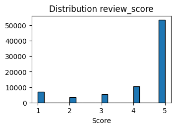

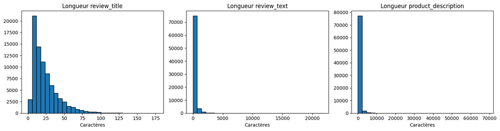

```
=== PRIX ===
count     54513
unique     4274
top       19.99
freq       1195
Name: product_price, dtype: object
```

[figure not shown]

```
=== 5 PREMIERS EXEMPLES TEXTE ===

review_title:
['Capo', 'easy to handle without getting burned.', 'Keyboard is great, stand is NOT!!!']

review_text:
["This is the best capo I've ever had.", 'i like it cause its easy for my daughter to handle without getting burned.', 'Thank goodness for other reviewers - as I was looking for a number to call to find out why screws were not included, I read another review that pointed out that they were actually …

product_description:
["['A Kyser Quick-Change capo is expertly engineered and built to last. It is reliable and does just what it is designed to do - clearly raise the pitch of the 6-string acoustic guitar so you can play in a different key without retuning or changing fingering. Seasoned professionals and beginning pla…
```

```python
import pandas as pd
import numpy as np
import matplotlib.pyplot as plt

# Chargement
df = pd.read_csv(r"C:\Users\SLKSh\Downloads\train.csv", encoding="utf-8", low_memory=False)

print("=== SHAPE ===", df.shape)
print("\n=== COLONNES ===", df.columns.tolist())
print("\n=== TYPES ===")
print(df.dtypes)
print("\n=== HEAD ===")
print(df.head(3))

print("\n=== MANQUANTS (%) ===")
print((df.isna().mean() * 100).round(2))

# Distribution review_score
print("\n=== REVIEW_SCORE ===")
print(df['review_score'].describe())

plt.figure(figsize=(8,5))
plt.subplot(2,2,1)
plt.hist(df['review_score'].dropna(), bins=20, edgecolor='black')
plt.title('Distribution review_score')
plt.xlabel('Score')

# Longueurs textes
text_cols = ['review_title', 'review_text', 'product_description']
fig, axes = plt.subplots(1,3, figsize=(15,4))

for i, col in enumerate(text_cols):
    if col in df.columns:
        lengths = df[col].fillna("").astype(str).str.len()
        axes[i].hist(lengths, bins=30, edgecolor='black')
        axes[i].set_title(f'Longueur {col}')
        axes[i].set_xlabel('Caractères')
        print(f"\n{col}: min={lengths.min()}, max={lengths.max()}, moy={lengths.mean():.1f}")

plt.tight_layout()
plt.show()

# Prix
if 'product_price' in df.columns:
    print("\n=== PRIX ===")
    print(df['product_price'].describe())

    plt.subplot(2,2,4)
    plt.hist(df['product_price'].dropna(), bins=30, edgecolor='black')
    plt.title('Distribution product_price')
    plt.xlabel('Prix')

plt.tight_layout()
plt.show()

print("\n=== 5 PREMIERS EXEMPLES TEXTE ===")
for col in text_cols:
    if col in df.columns:
        print(f"\n{col}:")
        print(df[col].dropna().astype(str).head(3).tolist())
```

#### Présentation du jeu de données

Le jeu de données d’entraînement contient 80 000 observations réparties sur 6 variables :

- review_id : identifiant unique de l’avis
- review_title : titre de l’avis
- review_text : texte principal de l’avis
- product_description : description du produit
- product_price : prix du produit
- review_score : note attribuée (variable cible, de 1 à 5)

#### Bilan de la qualité des données

[output not shown]

Les principales difficultés concernent donc le traitement du texte et la conversion du prix en variable numérique exploitable.

Moyenne et écart-type

```python
mean_score = df["review_score"].mean()
std_score = df["review_score"].std()

print("Moyenne :", round(mean_score, 3))
print("Écart-type :", round(std_score, 3))
```

```
Moyenne : 4.247
Écart-type : 1.284
```

Pourcentage par classe (déséquilibre)

```python
distribution = df["review_score"].value_counts(normalize=True) * 100
print(distribution.sort_index())
```

```
review_score
1.0     8.86000
2.0     4.45750
3.0     6.65125
4.0    13.16125
5.0    66.87000
Name: proportion, dtype: float64
```

Baseline (modèle constant)

```python
import numpy as np

mse_baseline = np.mean((df["review_score"] - mean_score) ** 2)
print("MSE du modèle constant :", round(mse_baseline, 4))
```

```
MSE du modèle constant : 1.6498
```

### **Nettoyages des données pour TEST et TRAIN**

```python
import pandas as pd
import numpy as np
import re

# =========================
# 1. FONCTIONS DE NETTOYAGE
# =========================
def clean_text(text):
    if pd.isna(text):
        return ""
    text = str(text)
    # Enlever HTML <br />
    text = re.sub(r'<br\s*/?>', ' ', text)
    # Minuscules
    text = text.lower()
    # Garder lettres, chiffres, espaces (enlever le reste)
    text = re.sub(r'[^a-z0-9\s]', ' ', text)
    return text.strip()

def clean_description(desc):
    if pd.isna(desc):
        return ""
    desc = str(desc)
    # Enlever les crochets et apostrophes des listes ['...']
    desc = re.sub(r"[\[\]']", ' ', desc)
    return clean_text(desc)

def parse_price(price_str):
    if pd.isna(price_str):
        return np.nan
    try:
        cleaned = str(price_str).strip()
        # Enlever tout ce qui n'est pas chiffre ou point
        cleaned = re.sub(r'[^\d.]', '', cleaned)
        return float(cleaned)
    except:
        return np.nan

# =========================
# 2. TRAIN : NETTOYAGE
# =========================
df_train = pd.read_csv(r"C:\Users\SLKSh\Downloads\train.csv", encoding="utf-8", low_memory=False)
print("Shape train:", df_train.shape)

print("Nettoyage textes train...")
df_train["review_title_clean"] = df_train["review_title"].apply(clean_text)
df_train["review_text_clean"] = df_train["review_text"].apply(clean_text)
df_train["product_description_clean"] = df_train["product_description"].apply(clean_description)

df_train["full_text"] = (
    df_train["review_title_clean"].fillna("") + " " +
    df_train["review_text_clean"].fillna("") + " " +
    df_train["product_description_clean"].fillna("")
)

print("Parsing prix train...")
df_train["product_price_num"] = df_train["product_price"].apply(parse_price)
df_train["price_missing"] = df_train["product_price_num"].isna().astype(int)

price_median = df_train["product_price_num"].median()
df_train["product_price_num"] = df_train["product_price_num"].fillna(price_median)

print(f"✅ Prix parsés train : {df_train['product_price_num'].notna().sum()}/{len(df_train)}")
print(f"Prix médiane (train) : {price_median:.2f}")
print(f"Texte fusionné moy (train) : {df_train['full_text'].str.len().mean():.0f} caractères")

# =========================
# 3. TEST : MÊME NETTOYAGE
# =========================
df_test = pd.read_csv(r"C:\Users\SLKSh\Downloads\test.csv", encoding="utf-8", low_memory=False)
print("Shape test:", df_test.shape)

print("Nettoyage textes test...")
df_test["review_title_clean"] = df_test["review_title"].apply(clean_text)
df_test["review_text_clean"] = df_test["review_text"].apply(clean_text)
df_test["product_description_clean"] = df_test["product_description"].apply(clean_description)

df_test["full_text"] = (
    df_test["review_title_clean"].fillna("") + " " +
    df_test["review_text_clean"].fillna("") + " " +
    df_test["product_description_clean"].fillna("")
)

print("Parsing prix test...")
df_test["product_price_num"] = df_test["product_price"].apply(parse_price)
df_test["price_missing"] = df_test["product_price_num"].isna().astype(int)
df_test["product_price_num"] = df_test["product_price_num"].fillna(price_median)  # même médiane que train

print(f"✅ Prix parsés test : {df_test['product_price_num'].notna().sum()}/{len(df_test)}")
print(f"Texte fusionné moy (test) : {df_test['full_text'].str.len().mean():.0f} caractères")
```

```
Shape train: (80000, 6)
Nettoyage textes train...
Parsing prix train...
✅ Prix parsés train : 80000/80000
Prix médiane (train) : 29.99
Texte fusionné moy (train) : 796 caractères
Shape test: (20000, 5)
Nettoyage textes test...
Parsing prix test...
✅ Prix parsés test : 20000/20000
Texte fusionné moy (test) : 776 caractères
```

Les variables textuelles (`review_title`, `review_text`, `product_description`) nécessitent un traitement préalable afin de réduire le bruit et d’uniformiser le format des données avant leur vectorisation.

Le pipeline de nettoyage appliqué est le suivant :

- **Suppression des balises HTML** Les balises telles que `<br />`, présentes principalement dans `review_text`, sont supprimées à l’aide d’expressions régulières afin d’éviter l’introduction de tokens non pertinents.
- **Normalisation en minuscules** Tous les textes sont convertis en minuscules afin d’éviter la duplication artificielle de termes (ex. : *Love* et *love*).
- **Suppression des caractères spéciaux** Les caractères non alphanumériques (ponctuation, symboles, caractères spéciaux) sont retirés. Seuls les lettres, chiffres et espaces sont conservés afin de simplifier le vocabulaire final.
- **Nettoyage spécifique des descriptions produits** La variable `product_description` était encodée sous forme de listes textuelles (`['texte1', 'texte2']`). Les crochets et apostrophes ont été supprimés pour convertir ces structures en texte brut exploitable.
- **Fusion des champs textuels** Les trois variables textuelles ont été concaténées pour former une variable unique `full_text`. Cette fusion permet :
  - d’enrichir le contexte sémantique,
  - d’améliorer la qualité de la vectorisation TF-IDF,
  - de simplifier le pipeline de modélisation.

La longueur moyenne du champ final obtenu est d’environ **800 caractères**.

### Nettoyage et transformation du prix

La variable `product_price` présentait deux problématiques majeures :

##### Conversion en variable numérique

Les caractères non numériques ont été supprimés afin d’extraire uniquement les chiffres et les points décimaux. Le résultat est converti en variable de type *float*.

##### Gestion des valeurs manquantes

Les valeurs manquantes ont été remplacées par la **médiane calculée sur le jeu d’entraînement**, ce qui permet :

- de limiter l’influence des valeurs extrêmes,
- de conserver une cohérence entre le jeu d’entraînement et le jeu de test.

#### Résultat du nettoyage

Ce nettoyage garantit une base de données cohérente, homogène et adaptée à l’entraînement d’un modèle de régression.

Voici toutes les methodes que nous avons utilisé pour predire le score :

- **td idf** (Partie 1)
- **countvectorizer** (Partie 2)
- **tf idf + svd50** (Partie 3)
- **SBert** (Partie 4)
- **word2vec** (Partie 5)
- **Char TF-IDF** (Partie 6)
- **Pondération de modèles** (Partie 7)
- **Modèles de résidus** (Partie 8)

### Transformation des données textuelles avec TF-IDF

Les données textuelles ne peuvent pas être directement utilisées par les modèles de machine learning. Il est donc nécessaire de transformer le texte en représentations numériques. Pour cela, nous utilisons la méthode **TF-IDF (Term Frequency – Inverse Document Frequency)**.

Le principe de TF-IDF repose sur deux composantes :

#### 1. Term Frequency (TF)

La fréquence d’un mot dans un document. Plus un mot apparaît souvent dans un texte, plus son poids est élevé.

$$ TF(t,d) = \frac{\text{nombre d'occurrences du terme } t \text{ dans } d} {\text{nombre total de mots dans } d} $$

#### 2. Inverse Document Frequency (IDF)

Cette composante permet de réduire l’importance des mots très fréquents dans l’ensemble des documents (par exemple : *the*, *is*, *and*).

$$ IDF(t) = \log \left(\frac{N}{df(t)}\right) $$

où :

- (N) est le nombre total de documents
- (df(t)) est le nombre de documents contenant le terme (t)

#### Score TF-IDF

Le score TF-IDF est ensuite calculé comme :

$$ TFIDF(t,d) = TF(t,d) \times IDF(t) $$

Ainsi, un mot aura un poids élevé s’il apparaît souvent dans un document mais rarement dans les autres documents.

### Modèle utilisé

Une fois les données préparées, nous utilisons un modèle de Random Forest Regressor pour prédire le score des avis (review_score).

La Random Forest est un algorithme d’ensemble basé sur plusieurs arbres de décision.

### td idf + random forest

```python
import numpy as np
import pandas as pd

from sklearn.feature_extraction.text import TfidfVectorizer
from sklearn.compose import ColumnTransformer
from sklearn.pipeline import Pipeline
from sklearn.model_selection import train_test_split
from sklearn.metrics import mean_squared_error
from sklearn.ensemble import RandomForestRegressor

# =========================
# 1. PRÉPARATION DES DONNÉES
# =========================

print("Préparation features...")

features = ['full_text', 'product_price_num', 'price_missing']

X_train = df_train[features].copy()
y_train = df_train['review_score'].copy()
X_test  = df_test[features].copy()

print(f"Train: {X_train.shape}, Test: {X_test.shape}")
print(f"Score moyen train: {y_train.mean():.2f}")

# =========================
# 2. VALIDATION LOCALE
# =========================

X_tr, X_val, y_tr, y_val = train_test_split(
    X_train, y_train,
    test_size=0.2,
    random_state=42
)

# =========================
# 3. PIPELINE TF-IDF + RANDOM FOREST
# =========================

preprocessor = ColumnTransformer(
    transformers=[
        (
            'text',
            TfidfVectorizer(
                max_features=20000,
                ngram_range=(1, 2),
                stop_words='english'
            ),
            'full_text'
        ),
        (
            'num',
            'passthrough',
            ['product_price_num', 'price_missing']
        )
    ],
    remainder='drop'
)

rf_model = RandomForestRegressor(
    n_estimators=300,
    max_depth=30,
    min_samples_split=5,
    min_samples_leaf=2,
    random_state=42,
    n_jobs=-1
)

pipeline_rf = Pipeline([
    ('preprocessor', preprocessor),
    ('model', rf_model)
])

# =========================
# 4. ENTRAÎNEMENT + VALIDATION
# =========================

print("\nEntraînement RandomForest...")
pipeline_rf.fit(X_tr, y_tr)

y_pred_val = pipeline_rf.predict(X_val)

mse_val = mean_squared_error(y_val, y_pred_val)
mse_baseline = mean_squared_error(y_val, np.full_like(y_val, y_tr.mean()))

print("\n=== RÉSULTATS VALIDATION (RF) ===")
print(f"MSE Validation : {mse_val:.4f}")
print(f"MSE Baseline   : {mse_baseline:.4f}")
print(f"Gain           : {((mse_baseline - mse_val) / mse_baseline * 100):+.1f}%")

# =========================
# 5. ENTRAÎNEMENT FINAL
# =========================

print("\nEntraînement final sur 100% train...")
pipeline_rf.fit(X_train, y_train)

# =========================
# 6. PRÉDICTION TEST + SUBMISSION
# =========================

print("\nPrédiction test...")
y_pred_test = pipeline_rf.predict(X_test)

# ✅ AJOUT DU CLIP (entre 1 et 5)
y_pred_test = np.clip(y_pred_test, 1.0, 5.0)

submission = pd.DataFrame({
    'id': df_test['review_id'],
    'score': y_pred_test
})

submission.to_csv('submission_rf.csv', index=False)

print("🎉 submission_rf.csv créé !")
print("\nAperçu submission:")
print(submission.head())

print(f"\nShape: {submission.shape}")
print(f"Scores prédits: min={y_pred_test.min():.2f}, "
      f"max={y_pred_test.max():.2f}, "
      f"moy={y_pred_test.mean():.2f}")
```

```
Préparation features...
Train: (80000, 3), Test: (20000, 3)
Score moyen train: 4.25

Entraînement RandomForest...

=== RÉSULTATS VALIDATION (RF) ===
MSE Validation : 0.9792
MSE Baseline   : 1.6035
Gain           : +38.9%

Entraînement final sur 100% train...

Prédiction test...
🎉 submission_rf.csv créé !

Aperçu submission:
      id     score
0  98877  4.268083
1  24044  4.269729
2  48435  4.324028
3  72179  3.958767
4  80645  4.262290

Shape: (20000, 2)
Scores prédits: min=1.00, max=5.00, moy=4.24
```

### Explication du code

Ce code permet de prédire la variable **`review_score`** à partir de données textuelles et numériques.

Les variables explicatives sont le texte complet de l’avis (**`full_text`**), le prix du produit (**`product_price_num`**) et le prix manquant (**`price_missing`**). La variable cible à prédire est **`review_score`**.

Ensuite, les données d’entraînement sont séparées en deux parties : une partie pour entraîner le modèle et une autre pour évaluer ses performances localement.

Les données sont transformées avec l'aide d’un **ColumnTransformer**. La variable textuelle **`full_text`** est transformée en variables numériques grâce à la méthode **TF-IDF**, qui convertit les mots en scores numériques selon leur importance dans les documents. Les variables numériques comme **`product_price_num`** et **`price_missing`** restent inchangées.

Après cette transformation, un modèle de **Random Forest Regressor** est utilisé. Ce modèle est composé de plusieurs arbres de décision et permet de prédire une valeur continue, ici le score de l’avis. La transformation et le modèle sont regroupés dans un **pipeline**. Cela permet d’automatiser toutes les étapes en une seule chaîne de traitement.

Le pipeline est ensuite entraîné sur les données d’apprentissage, puis utilisé pour faire des prédictions sur l’ensemble de validation. Les performances du modèle sont mesurées avec la **MSE**, puis comparées à une baseline simple qui consiste à prédire la moyenne des scores d’entraînement pour tous les avis.

Enfin, une fois la validation terminée, le pipeline est réentraîné sur l’ensemble complet des données d’entraînement afin de profiter de toutes les observations disponibles. Le modèle est alors appliqué aux données de test pour générer les prédictions finales. Ces prédictions sont limitées entre **1 et 5**, puis sont enregistrées dans un fichier nommée **`submission_rf.csv`**.

### Interprétation des résultats

Le jeu de données d'entraînement contient **80 000 lignes**.  
Le jeu de test contient **20 000 lignes**.

La moyenne de la variable cible **`review_score`** dans les données d'entraînement est **4.25**. Cela indique que les avis sont globalement **très positifs**, ce qui signifie que la distribution des scores est probablement **déséquilibrée et dirigée vers les valeurs élevées**.

La performance du modèle est évaluée avec la **Mean Squared Error (MSE)**, qui mesure l’écart moyen au carré entre les valeurs réelles et les valeurs prédites.

- **MSE Validation = 0.9792**  
  Cela représente l'erreur du modèle Random Forest sur l'ensemble de validation. Plus la valeur est faible, meilleur est le modèle.
- **MSE Baseline = 1.6035**  
  La baseline correspond à un modèle très simple qui prédirait **toujours la moyenne des scores d'entraînement (4.25)** pour chaque observation. Cette valeur sert de point de comparaison.
- **Gain = +38.9 %**  
  Le modèle réduit l'erreur de **38.9 % par rapport à la baseline**, ce qui signifie qu’il exploite bien les informations contenues dans le texte et les variables numériques pour améliorer la prédiction.

Après la validation, le modèle est **réentraîné sur l'ensemble complet des données d'entraînement (80 000 observations)** afin d'utiliser toute l'information disponible avant de générer les prédictions finales.

Le fichier de soumission contient **20 000 lignes**, correspondant aux **20 000 observations du jeu de test**, et **2 colonnes** :

- `id` : l'identifiant de l'avis
- `score` : le score prédit par le modèle

Les scores prédits sont compris entre **1 et 5**, ce qui correspond à l’échelle attendue pour les avis. Cette contrainte est assurée par l’utilisation de la fonction **clip**.

La moyenne des scores prédits est **4.24**, ce qui est très proche de la moyenne observée dans les données d'entraînement (**4.25**). Cela indique que les prédictions du modèle restent **cohérentes avec la distribution des données**.

### td idf + elastic net

Nous avons ensuite appliqué la même méthode que précédemment, mais en remplaçant le modèle **Random Forest** par un modèle **Elastic Net**.

L’Elastic Net est une méthode de régression qui combine les pénalisations **Lasso** et **Ridge**. Elle est particulièrement adaptée aux données issues de **TF-IDF**, car celles-ci contiennent un très grand nombre de variables. Cette méthode permet donc de mieux contrôler la complexité du modèle et de réduire le risque de surapprentissage.

```python
import numpy as np
import pandas as pd

from sklearn.feature_extraction.text import TfidfVectorizer
from sklearn.compose import ColumnTransformer
from sklearn.pipeline import Pipeline
from sklearn.model_selection import train_test_split
from sklearn.metrics import mean_squared_error
from sklearn.linear_model import ElasticNet

# =========================
# 1. PRÉPARATION DES DONNÉES
# =========================

print("Préparation features...")

features = ['full_text', 'product_price_num', 'price_missing']

X_train = df_train[features].copy()
y_train = df_train['review_score'].copy()
X_test  = df_test[features].copy()

print(f"Train: {X_train.shape}, Test: {X_test.shape}")
print(f"Score moyen train: {y_train.mean():.2f}")

# =========================
# 2. VALIDATION LOCALE
# =========================

X_tr, X_val, y_tr, y_val = train_test_split(
    X_train, y_train,
    test_size=0.2,
    random_state=42
)

# =========================
# 3. PIPELINE TF-IDF + ELASTIC NET
# =========================

preprocessor = ColumnTransformer(
    transformers=[
        (
            'text',
            TfidfVectorizer(
                max_features=20000,
                ngram_range=(1, 2),
                stop_words='english'
            ),
            'full_text'
        ),
        (
            'num',
            'passthrough',
            ['product_price_num', 'price_missing']
        )
    ],
    remainder='drop'
)

enet_model = ElasticNet(
    alpha=0.001,
    l1_ratio=0.5,
    random_state=42,
    max_iter=5000
)

pipeline_enet = Pipeline([
    ('preprocessor', preprocessor),
    ('model', enet_model)
])

# =========================
# 4. ENTRAÎNEMENT + VALIDATION
# =========================

print("\nEntraînement ElasticNet...")
pipeline_enet.fit(X_tr, y_tr)

y_pred_val = pipeline_enet.predict(X_val)

# ✅ clip validation (optionnel mais utile)
y_pred_val = np.clip(y_pred_val, 1.0, 5.0)

mse_val = mean_squared_error(y_val, y_pred_val)
mse_baseline = mean_squared_error(y_val, np.full_like(y_val, y_tr.mean()))

print("\n=== RÉSULTATS VALIDATION (ElasticNet) ===")
print(f"MSE Validation : {mse_val:.4f}")
print(f"MSE Baseline   : {mse_baseline:.4f}")
print(f"Gain           : {((mse_baseline - mse_val) / mse_baseline * 100):+.1f}%")

# =========================
# 5. ENTRAÎNEMENT FINAL
# =========================

print("\nEntraînement final sur 100% train...")
pipeline_enet.fit(X_train, y_train)

# =========================
# 6. PRÉDICTION TEST + SUBMISSION
# =========================

print("\nPrédiction test...")
y_pred_test = pipeline_enet.predict(X_test)

# ✅ clip obligatoire pour la submission
y_pred_test = np.clip(y_pred_test, 1.0, 5.0)

submission = pd.DataFrame({
    'id': df_test['review_id'],
    'score': y_pred_test
})

submission.to_csv('submission_enet.csv', index=False)

print("🎉 submission_enet.csv créé !")
print("\nAperçu submission:")
print(submission.head())

print(f"\nShape: {submission.shape}")
print(f"Scores prédits: min={y_pred_test.min():.2f}, "
      f"max={y_pred_test.max():.2f}, "
      f"moy={y_pred_test.mean():.2f}")
```

```
Préparation features...
Train: (80000, 3), Test: (20000, 3)
Score moyen train: 4.25

Entraînement ElasticNet...

=== RÉSULTATS VALIDATION (ElasticNet) ===
MSE Validation : 1.1521
MSE Baseline   : 1.6035
Gain           : +28.2%

Entraînement final sur 100% train...

Prédiction test...
🎉 submission_enet.csv créé !

Aperçu submission:
      id     score
0  98877  4.192145
1  24044  4.407462
2  48435  4.115903
3  72179  4.041698
4  80645  3.993723

Shape: (20000, 2)
Scores prédits: min=1.00, max=5.00, moy=4.24
```

### TF-IDF + SVM

Nous avons appliqué la même méthode que précédemment, mais cette fois-ci en utilisant un modèle **SVM (Support Vector Machine)** à la place du modèle Elastic Net.

```python
import numpy as np
import pandas as pd

from sklearn.feature_extraction.text import TfidfVectorizer
from sklearn.compose import ColumnTransformer
from sklearn.pipeline import Pipeline
from sklearn.model_selection import train_test_split
from sklearn.metrics import mean_squared_error
from sklearn.svm import LinearSVR

# =========================
# 1. PRÉPARATION DES DONNÉES
# =========================

print("Préparation features...")

features = ['full_text', 'product_price_num', 'price_missing']

X_train = df_train[features].copy()
y_train = df_train['review_score'].copy()
X_test  = df_test[features].copy()

print(f"Train: {X_train.shape}, Test: {X_test.shape}")
print(f"Score moyen train: {y_train.mean():.2f}")

# =========================
# 2. VALIDATION LOCALE
# =========================

X_tr, X_val, y_tr, y_val = train_test_split(
    X_train, y_train,
    test_size=0.2,
    random_state=42
)

# =========================
# 3. PIPELINE TF-IDF + LINEAR SVR
# =========================

preprocessor = ColumnTransformer(
    transformers=[
        (
            'text',
            TfidfVectorizer(
                max_features=20000,
                ngram_range=(1, 2),
                stop_words='english'
            ),
            'full_text'
        ),
        (
            'num',
            'passthrough',
            ['product_price_num', 'price_missing']
        )
    ],
    remainder='drop'
)

svr_model = LinearSVR(
    C=1.0,
    epsilon=0.1,
    random_state=42,
    max_iter=10000
)

pipeline_svr = Pipeline([
    ('preprocessor', preprocessor),
    ('model', svr_model)
])

# =========================
# 4. ENTRAÎNEMENT + VALIDATION
# =========================

print("\nEntraînement LinearSVR...")
pipeline_svr.fit(X_tr, y_tr)

y_pred_val = pipeline_svr.predict(X_val)

# ✅ Clip pour rester entre 1 et 5
y_pred_val = np.clip(y_pred_val, 1.0, 5.0)

mse_val = mean_squared_error(y_val, y_pred_val)
mse_baseline = mean_squared_error(y_val, np.full_like(y_val, y_tr.mean()))

print("\n=== RÉSULTATS VALIDATION (LinearSVR) ===")
print(f"MSE Validation : {mse_val:.4f}")
print(f"MSE Baseline   : {mse_baseline:.4f}")
print(f"Gain           : {((mse_baseline - mse_val) / mse_baseline * 100):+.1f}%")

# =========================
# 5. ENTRAÎNEMENT FINAL
# =========================

print("\nEntraînement final sur 100% train...")
pipeline_svr.fit(X_train, y_train)

# =========================
# 6. PRÉDICTION TEST + SUBMISSION
# =========================

print("\nPrédiction test...")
y_pred_test = pipeline_svr.predict(X_test)

# ✅ Clip obligatoire avant la submission
y_pred_test = np.clip(y_pred_test, 1.0, 5.0)

submission = pd.DataFrame({
    'id': df_test['review_id'],
    'score': y_pred_test
})

submission.to_csv('submission_svr.csv', index=False)

print("🎉 submission_svr.csv créé !")
print("\nAperçu submission:")
print(submission.head())

print(f"\nShape: {submission.shape}")
print(f"Scores prédits: min={y_pred_test.min():.2f}, "
      f"max={y_pred_test.max():.2f}, "
      f"moy={y_pred_test.mean():.2f}")
```

```
Préparation features...
Train: (80000, 3), Test: (20000, 3)
Score moyen train: 4.25

Entraînement LinearSVR...
```

```
=== RÉSULTATS VALIDATION (LinearSVR) ===
MSE Validation : 0.9435
MSE Baseline   : 1.6035
Gain           : +41.2%

Entraînement final sur 100% train...
```

```
Prédiction test...
🎉 submission_svr.csv créé !

Aperçu submission:
      id     score
0  98877  4.311318
1  24044  4.532440
2  48435  4.116338
3  72179  3.525752
4  80645  3.733349

Shape: (20000, 2)
Scores prédits: min=1.00, max=5.00, moy=3.80
```

### TF-IDF + Gradient Boosting

Nous avons repris la même démarche que précédemment, mais cette fois-ci en utilisant un modèle de **Gradient Boosting**.

Le **Gradient Boosting** est une méthode d’ensemble qui construit plusieurs arbres de décision de manière successive. À chaque étape, un nouvel arbre est entraîné pour corriger les erreurs du précédent. L’idée est donc d’améliorer progressivement les prédictions en combinant plusieurs modèles faibles pour obtenir un modèle final plus performant.

```python
import numpy as np
import pandas as pd

from sklearn.feature_extraction.text import TfidfVectorizer
from sklearn.compose import ColumnTransformer
from sklearn.pipeline import Pipeline
from sklearn.model_selection import train_test_split
from sklearn.metrics import mean_squared_error
from sklearn.ensemble import GradientBoostingRegressor

# =========================
# 1. PRÉPARATION DES DONNÉES
# =========================

print("Préparation features...")

features = ['full_text', 'product_price_num', 'price_missing']

X_train = df_train[features].copy()
y_train = df_train['review_score'].copy()
X_test  = df_test[features].copy()

print(f"Train: {X_train.shape}, Test: {X_test.shape}")
print(f"Score moyen train: {y_train.mean():.2f}")

# =========================
# 2. VALIDATION LOCALE
# =========================

X_tr, X_val, y_tr, y_val = train_test_split(
    X_train, y_train,
    test_size=0.2,
    random_state=42
)

# =========================
# 3. PIPELINE TF-IDF + GRADIENT BOOSTING
# =========================

preprocessor = ColumnTransformer(
    transformers=[
        (
            'text',
            TfidfVectorizer(
                max_features=20000,
                ngram_range=(1, 2),
                stop_words='english'
            ),
            'full_text'
        ),
        (
            'num',
            'passthrough',
            ['product_price_num', 'price_missing']
        )
    ],
    remainder='drop'
)

gbr_model = GradientBoostingRegressor(
    n_estimators=300,
    learning_rate=0.05,
    max_depth=3,
    random_state=42
)

pipeline_gbr = Pipeline([
    ('preprocessor', preprocessor),
    ('model', gbr_model)
])

# =========================
# 4. ENTRAÎNEMENT + VALIDATION
# =========================

print("\nEntraînement GradientBoosting...")
pipeline_gbr.fit(X_tr, y_tr)

y_pred_val = pipeline_gbr.predict(X_val)

# ✅ Clip pour garder les scores entre 1 et 5
y_pred_val = np.clip(y_pred_val, 1.0, 5.0)

mse_val = mean_squared_error(y_val, y_pred_val)
mse_baseline = mean_squared_error(y_val, np.full_like(y_val, y_tr.mean()))

print("\n=== RÉSULTATS VALIDATION (GradientBoosting) ===")
print(f"MSE Validation : {mse_val:.4f}")
print(f"MSE Baseline   : {mse_baseline:.4f}")
print(f"Gain           : {((mse_baseline - mse_val) / mse_baseline * 100):+.1f}%")

# =========================
# 5. ENTRAÎNEMENT FINAL
# =========================

print("\nEntraînement final sur 100% train...")
pipeline_gbr.fit(X_train, y_train)

# =========================
# 6. PRÉDICTION TEST + SUBMISSION
# =========================

print("\nPrédiction test...")
y_pred_test = pipeline_gbr.predict(X_test)

# ✅ Clip obligatoire avant la submission
y_pred_test = np.clip(y_pred_test, 1.0, 5.0)

submission = pd.DataFrame({
    'id': df_test['review_id'],
    'score': y_pred_test
})

submission.to_csv('submission_gbr.csv', index=False)

print("🎉 submission_gbr.csv créé !")
print("\nAperçu submission:")
print(submission.head())

print(f"\nShape: {submission.shape}")
print(f"Scores prédits: min={y_pred_test.min():.2f}, "
      f"max={y_pred_test.max():.2f}, "
      f"moy={y_pred_test.mean():.2f}")
```

```
Préparation features...
Train: (80000, 3), Test: (20000, 3)
Score moyen train: 4.25

Entraînement GradientBoosting...

=== RÉSULTATS VALIDATION (GradientBoosting) ===
MSE Validation : 0.9721
MSE Baseline   : 1.6035
Gain           : +39.4%

Entraînement final sur 100% train...

Prédiction test...
🎉 submission_gbr.csv créé !

Aperçu submission:
      id     score
0  98877  4.252587
1  24044  4.265039
2  48435  4.284724
3  72179  4.036709
4  80645  4.236780

Shape: (20000, 2)
Scores prédits: min=1.00, max=5.00, moy=4.24
```

### TF-IDF + XGBoost

Nous avons ensuite appliqué la même démarche que précédemment, mais cette fois-ci en utilisant un modèle **XGBoost**.

Le **XGBoost (Extreme Gradient Boosting)** est une méthode d’apprentissage basée sur le principe du **boosting**. Comme le Gradient Boosting, elle construit plusieurs arbres de décision de manière successive afin de corriger progressivement les erreurs des modèles précédents. XGBoost est une version optimisée de cette méthode, souvent plus rapide et plus performante grâce à une meilleure gestion de la régularisation et du calcul.

```python
import numpy as np
import pandas as pd

from sklearn.feature_extraction.text import TfidfVectorizer
from sklearn.compose import ColumnTransformer
from sklearn.pipeline import Pipeline
from sklearn.model_selection import train_test_split
from sklearn.metrics import mean_squared_error

from xgboost import XGBRegressor

# =========================
# 1. PRÉPARATION DES DONNÉES
# =========================

print("Préparation features...")

features = ['full_text', 'product_price_num', 'price_missing']

X_train = df_train[features].copy()
y_train = df_train['review_score'].copy()
X_test  = df_test[features].copy()

print(f"Train: {X_train.shape}, Test: {X_test.shape}")
print(f"Score moyen train: {y_train.mean():.2f}")

# =========================
# 2. VALIDATION LOCALE
# =========================

X_tr, X_val, y_tr, y_val = train_test_split(
    X_train, y_train,
    test_size=0.2,
    random_state=42
)

# =========================
# 3. PIPELINE TF-IDF + XGBOOST
# =========================

preprocessor = ColumnTransformer(
    transformers=[
        (
            'text',
            TfidfVectorizer(
                max_features=20000,
                ngram_range=(1, 2),
                stop_words='english'
            ),
            'full_text'
        ),
        (
            'num',
            'passthrough',
            ['product_price_num', 'price_missing']
        )
    ],
    remainder='drop'
)

xgb_model = XGBRegressor(
    n_estimators=800,
    learning_rate=0.05,
    max_depth=6,
    subsample=0.8,
    colsample_bytree=0.8,
    reg_alpha=0.0,
    reg_lambda=1.0,
    random_state=42,
    n_jobs=-1,
    tree_method="hist"
)

pipeline_xgb = Pipeline([
    ('preprocessor', preprocessor),
    ('model', xgb_model)
])

# =========================
# 4. ENTRAÎNEMENT + VALIDATION
# =========================

print("\nEntraînement XGBoost...")
pipeline_xgb.fit(X_tr, y_tr)

y_pred_val = pipeline_xgb.predict(X_val)

# ✅ Clip pour garder les prédictions entre 1 et 5
y_pred_val = np.clip(y_pred_val, 1.0, 5.0)

mse_val = mean_squared_error(y_val, y_pred_val)
mse_baseline = mean_squared_error(y_val, np.full_like(y_val, y_tr.mean()))

print("\n=== RÉSULTATS VALIDATION (XGBoost) ===")
print(f"MSE Validation : {mse_val:.4f}")
print(f"MSE Baseline   : {mse_baseline:.4f}")
print(f"Gain           : {((mse_baseline - mse_val) / mse_baseline * 100):+.1f}%")

# =========================
# 5. ENTRAÎNEMENT FINAL
# =========================

print("\nEntraînement final sur 100% train...")
pipeline_xgb.fit(X_train, y_train)

# =========================
# 6. PRÉDICTION TEST + SUBMISSION
# =========================

print("\nPrédiction test...")
y_pred_test = pipeline_xgb.predict(X_test)

# ✅ Clip obligatoire avant la submission
y_pred_test = np.clip(y_pred_test, 1.0, 5.0)

submission = pd.DataFrame({
    'id': df_test['review_id'],
    'score': y_pred_test
})

submission.to_csv('submission_xgb.csv', index=False)

print("🎉 submission_xgb.csv créé !")
print("\nAperçu submission:")
print(submission.head())

print(f"\nShape: {submission.shape}")
print(f"Scores prédits: min={y_pred_test.min():.2f}, "
      f"max={y_pred_test.max():.2f}, "
      f"moy={y_pred_test.mean():.2f}")
```

```
Préparation features...
Train: (80000, 3), Test: (20000, 3)
Score moyen train: 4.25

Entraînement XGBoost...

=== RÉSULTATS VALIDATION (XGBoost) ===
MSE Validation : 0.8032
MSE Baseline   : 1.6035
Gain           : +49.9%

Entraînement final sur 100% train...

Prédiction test...
🎉 submission_xgb.csv créé !

Aperçu submission:
      id     score
0  98877  4.335724
1  24044  4.409301
2  48435  4.404676
3  72179  4.034824
4  80645  4.354922

Shape: (20000, 2)
Scores prédits: min=1.00, max=5.00, moy=4.24
```

### TF-IDF + Régression linéaire

Nous avons ensuite appliqué la même démarche que précédemment, mais cette fois-ci en utilisant un modèle de **régression linéaire**.

La **régression linéaire** est une méthode statistique qui cherche à modéliser la relation entre une variable cible et plusieurs variables explicatives à l’aide d’une combinaison linéaire de ces variables. Le modèle attribue un coefficient à chaque variable afin de prédire la valeur de la variable cible.

```python
import numpy as np
import pandas as pd

from sklearn.feature_extraction.text import TfidfVectorizer
from sklearn.compose import ColumnTransformer
from sklearn.pipeline import Pipeline
from sklearn.model_selection import train_test_split
from sklearn.metrics import mean_squared_error
from sklearn.linear_model import LinearRegression

# =========================
# 1. PRÉPARATION DES DONNÉES
# =========================

print("Préparation features...")

features = ['full_text', 'product_price_num', 'price_missing']

X_train = df_train[features].copy()
y_train = df_train['review_score'].copy()
X_test  = df_test[features].copy()

print(f"Train: {X_train.shape}, Test: {X_test.shape}")
print(f"Score moyen train: {y_train.mean():.2f}")

# =========================
# 2. VALIDATION LOCALE
# =========================

X_tr, X_val, y_tr, y_val = train_test_split(
    X_train, y_train,
    test_size=0.2,
    random_state=42
)

# =========================
# 3. PIPELINE TF-IDF + LINEAR REGRESSION
# =========================

preprocessor = ColumnTransformer(
    transformers=[
        (
            'text',
            TfidfVectorizer(
                max_features=20000,
                ngram_range=(1, 2),
                stop_words='english'
            ),
            'full_text'
        ),
        (
            'num',
            'passthrough',
            ['product_price_num', 'price_missing']
        )
    ],
    remainder='drop'
)

linreg_model = LinearRegression(n_jobs=-1)

pipeline_linreg = Pipeline([
    ('preprocessor', preprocessor),
    ('model', linreg_model)
])

# =========================
# 4. ENTRAÎNEMENT + VALIDATION
# =========================

print("\nEntraînement LinearRegression...")
pipeline_linreg.fit(X_tr, y_tr)

y_pred_val = pipeline_linreg.predict(X_val)

# ✅ Clip pour garder les prédictions entre 1 et 5
y_pred_val = np.clip(y_pred_val, 1.0, 5.0)

mse_val = mean_squared_error(y_val, y_pred_val)
mse_baseline = mean_squared_error(
    y_val,
    np.full_like(y_val, y_tr.mean(), dtype=float)
)

print("\n=== RÉSULTATS VALIDATION (LinearRegression) ===")
print(f"MSE Validation : {mse_val:.4f}")
print(f"MSE Baseline   : {mse_baseline:.4f}")
print(f"Gain           : {((mse_baseline - mse_val) / mse_baseline * 100):+.1f}%")

# =========================
# 5. ENTRAÎNEMENT FINAL
# =========================

print("\nEntraînement final sur 100% train...")
pipeline_linreg.fit(X_train, y_train)

# =========================
# 6. PRÉDICTION TEST + SUBMISSION
# =========================

print("\nPrédiction test...")
y_pred_test = pipeline_linreg.predict(X_test)

# ✅ Clip obligatoire avant la submission
y_pred_test = np.clip(y_pred_test, 1.0, 5.0)

submission = pd.DataFrame({
    'id': df_test['review_id'],
    'score': y_pred_test
})

submission.to_csv('submission_linreg.csv', index=False)

print("🎉 submission_linreg.csv créé !")
print("\nAperçu submission:")
print(submission.head())

print(f"\nShape: {submission.shape}")
print(
    f"Scores prédits: min={y_pred_test.min():.2f}, "
    f"max={y_pred_test.max():.2f}, "
    f"moy={y_pred_test.mean():.2f}"
)
```

```
Préparation features...
Train: (80000, 3), Test: (20000, 3)
Score moyen train: 4.25

Entraînement LinearRegression...

=== RÉSULTATS VALIDATION (LinearRegression) ===
MSE Validation : 1.0304
MSE Baseline   : 1.6035
Gain           : +35.7%

Entraînement final sur 100% train...

Prédiction test...
🎉 submission_linreg.csv créé !

Aperçu submission:
      id     score
0  98877  4.344089
1  24044  4.591526
2  48435  3.800191
3  72179  3.522073
4  80645  3.726863

Shape: (20000, 2)
Scores prédits: min=1.00, max=5.00, moy=4.19
```

### TF-IDF + Ridge

Nous avons ensuite appliqué la même démarche que précédemment, mais cette fois-ci en utilisant un modèle **Ridge**.

La **régression Ridge** est une variante de la régression linéaire qui ajoute une **pénalisation L2** sur les coefficients du modèle. Cette régularisation permet de limiter la complexité du modèle et de réduire le risque de surapprentissage, notamment lorsque le nombre de variables est élevé.

```python
import numpy as np
import pandas as pd

from sklearn.feature_extraction.text import TfidfVectorizer
from sklearn.compose import ColumnTransformer
from sklearn.pipeline import Pipeline
from sklearn.model_selection import train_test_split
from sklearn.metrics import mean_squared_error
from sklearn.linear_model import Ridge

# =========================
# 1. PRÉPARATION DES DONNÉES
# =========================

print("Préparation features...")

features = ['full_text', 'product_price_num', 'price_missing']

X_train = df_train[features].copy()
y_train = df_train['review_score'].copy()
X_test  = df_test[features].copy()

print(f"Train: {X_train.shape}, Test: {X_test.shape}")
print(f"Score moyen train: {y_train.mean():.2f}")

# =========================
# 2. VALIDATION LOCALE
# =========================

X_tr, X_val, y_tr, y_val = train_test_split(
    X_train, y_train,
    test_size=0.2,
    random_state=42
)

# =========================
# 3. PIPELINE TF-IDF + RIDGE
# =========================

preprocessor = ColumnTransformer(
    transformers=[
        (
            'text',
            TfidfVectorizer(
                max_features=20000,
                ngram_range=(1, 2),
                stop_words='english'
            ),
            'full_text'
        ),
        (
            'num',
            'passthrough',
            ['product_price_num', 'price_missing']
        )
    ],
    remainder='drop'
)

ridge_model = Ridge(
    alpha=1.0,
    random_state=42
)

pipeline_ridge = Pipeline([
    ('preprocessor', preprocessor),
    ('model', ridge_model)
])

# =========================
# 4. ENTRAÎNEMENT + VALIDATION
# =========================

print("\nEntraînement Ridge...")
pipeline_ridge.fit(X_tr, y_tr)

y_pred_val = pipeline_ridge.predict(X_val)

# ✅ Clip pour garder les prédictions entre 1 et 5
y_pred_val = np.clip(y_pred_val, 1.0, 5.0)

mse_val = mean_squared_error(y_val, y_pred_val)
mse_baseline = mean_squared_error(
    y_val,
    np.full_like(y_val, y_tr.mean(), dtype=float)
)

print("\n=== RÉSULTATS VALIDATION (Ridge) ===")
print(f"MSE Validation : {mse_val:.4f}")
print(f"MSE Baseline   : {mse_baseline:.4f}")
print(f"Gain           : {((mse_baseline - mse_val) / mse_baseline * 100):+.1f}%")

# =========================
# 5. ENTRAÎNEMENT FINAL
# =========================

print("\nEntraînement final sur 100% train...")
pipeline_ridge.fit(X_train, y_train)

# =========================
# 6. PRÉDICTION TEST + SUBMISSION
# =========================

print("\nPrédiction test...")
y_pred_test = pipeline_ridge.predict(X_test)

# ✅ Clip obligatoire avant la submission
y_pred_test = np.clip(y_pred_test, 1.0, 5.0)

submission = pd.DataFrame({
    'id': df_test['review_id'],
    'score': y_pred_test
})

submission.to_csv('submission_ridge.csv', index=False)

print("🎉 submission_ridge.csv créé !")
print("\nAperçu submission:")
print(submission.head())

print(f"\nShape: {submission.shape}")
print(
    f"Scores prédits: min={y_pred_test.min():.2f}, "
    f"max={y_pred_test.max():.2f}, "
    f"moy={y_pred_test.mean():.2f}"
)
```

```
Préparation features...
Train: (80000, 3), Test: (20000, 3)
Score moyen train: 4.25

Entraînement Ridge...

=== RÉSULTATS VALIDATION (Ridge) ===
MSE Validation : 0.8650
MSE Baseline   : 1.6035
Gain           : +46.1%

Entraînement final sur 100% train...

Prédiction test...
🎉 submission_ridge.csv créé !

Aperçu submission:
      id     score
0  98877  4.336948
1  24044  4.756518
2  48435  4.119471
3  72179  3.522130
4  80645  3.793786

Shape: (20000, 2)
Scores prédits: min=1.00, max=5.00, moy=4.21
```

### TF-IDF + Lasso

Nous avons ensuite appliqué la même démarche que précédemment, mais cette fois-ci en utilisant un modèle **Lasso**.

La **régression Lasso** est une variante de la régression linéaire qui utilise une **pénalisation L1** sur les coefficients du modèle. Cette régularisation a la particularité de pouvoir **réduire certains coefficients à zéro**, ce qui revient à sélectionner automatiquement les variables les plus importantes.

```python
import numpy as np
import pandas as pd

from sklearn.feature_extraction.text import TfidfVectorizer
from sklearn.compose import ColumnTransformer
from sklearn.pipeline import Pipeline
from sklearn.model_selection import train_test_split
from sklearn.metrics import mean_squared_error
from sklearn.linear_model import Lasso

# =========================
# 1. PRÉPARATION DES DONNÉES
# =========================

print("Préparation features...")

features = ['full_text', 'product_price_num', 'price_missing']

X_train = df_train[features].copy()
y_train = df_train['review_score'].copy()
X_test  = df_test[features].copy()

print(f"Train: {X_train.shape}, Test: {X_test.shape}")
print(f"Score moyen train: {y_train.mean():.2f}")

# =========================
# 2. VALIDATION LOCALE
# =========================

X_tr, X_val, y_tr, y_val = train_test_split(
    X_train, y_train,
    test_size=0.2,
    random_state=42
)

# =========================
# 3. PIPELINE TF-IDF + LASSO
# =========================

preprocessor = ColumnTransformer(
    transformers=[
        (
            'text',
            TfidfVectorizer(
                max_features=20000,
                ngram_range=(1, 2),
                stop_words='english'
            ),
            'full_text'
        ),
        (
            'num',
            'passthrough',
            ['product_price_num', 'price_missing']
        )
    ],
    remainder='drop'
)

lasso_model = Lasso(
    alpha=0.001,
    max_iter=20000,
    random_state=42
)

pipeline_lasso = Pipeline([
    ('preprocessor', preprocessor),
    ('model', lasso_model)
])

# =========================
# 4. ENTRAÎNEMENT + VALIDATION
# =========================

print("\nEntraînement Lasso...")
pipeline_lasso.fit(X_tr, y_tr)

y_pred_val = pipeline_lasso.predict(X_val)

# ✅ Clip pour rester entre 1 et 5
y_pred_val = np.clip(y_pred_val, 1.0, 5.0)

mse_val = mean_squared_error(y_val, y_pred_val)
mse_baseline = mean_squared_error(
    y_val,
    np.full_like(y_val, y_tr.mean(), dtype=float)
)

print("\n=== RÉSULTATS VALIDATION (Lasso) ===")
print(f"MSE Validation : {mse_val:.4f}")
print(f"MSE Baseline   : {mse_baseline:.4f}")
print(f"Gain           : {((mse_baseline - mse_val) / mse_baseline * 100):+.1f}%")

# =========================
# 5. ENTRAÎNEMENT FINAL
# =========================

print("\nEntraînement final sur 100% train...")
pipeline_lasso.fit(X_train, y_train)

# =========================
# 6. PRÉDICTION TEST + SUBMISSION
# =========================

print("\nPrédiction test...")
y_pred_test = pipeline_lasso.predict(X_test)

# ✅ Clip obligatoire avant la submission
y_pred_test = np.clip(y_pred_test, 1.0, 5.0)

submission = pd.DataFrame({
    'id': df_test['review_id'],
    'score': y_pred_test
})

submission.to_csv('submission_lasso.csv', index=False)

print("🎉 submission_lasso.csv créé !")
print("\nAperçu submission:")
print(submission.head())

print(f"\nShape: {submission.shape}")
print(
    f"Scores prédits: min={y_pred_test.min():.2f}, "
    f"max={y_pred_test.max():.2f}, "
    f"moy={y_pred_test.mean():.2f}"
)
```

```
Préparation features...
Train: (80000, 3), Test: (20000, 3)
Score moyen train: 4.25

Entraînement Lasso...

=== RÉSULTATS VALIDATION (Lasso) ===
MSE Validation : 1.1522
MSE Baseline   : 1.6035
Gain           : +28.1%

Entraînement final sur 100% train...

Prédiction test...
🎉 submission_lasso.csv créé !

Aperçu submission:
      id     score
0  98877  4.296672
1  24044  4.388675
2  48435  4.237588
3  72179  4.092710
4  80645  4.004974

Shape: (20000, 2)
Scores prédits: min=1.00, max=5.00, moy=4.24
```

### TF-IDF + SGDRegressor

Nous avons ensuite appliqué la même démarche que précédemment, mais cette fois-ci en utilisant un modèle **SGDRegressor**.

Le **SGDRegressor (Stochastic Gradient Descent Regressor)** est un modèle de régression linéaire entraîné à l’aide de la méthode de **descente de gradient stochastique**. Au lieu d’utiliser toutes les données à chaque itération, l’algorithme met à jour les coefficients progressivement en utilisant de petits lots de données. Cela permet d’entraîner le modèle **plus rapidement**, notamment lorsque le nombre de variables est très élevé.

```python
import numpy as np
import pandas as pd

from sklearn.feature_extraction.text import TfidfVectorizer
from sklearn.compose import ColumnTransformer
from sklearn.pipeline import Pipeline
from sklearn.model_selection import train_test_split
from sklearn.metrics import mean_squared_error
from sklearn.linear_model import SGDRegressor

# =========================
# 1. PRÉPARATION DES DONNÉES
# =========================

print("Préparation features...")

features = ['full_text', 'product_price_num', 'price_missing']

X_train = df_train[features].copy()
y_train = df_train['review_score'].copy()
X_test  = df_test[features].copy()

print(f"Train: {X_train.shape}, Test: {X_test.shape}")
print(f"Score moyen train: {y_train.mean():.2f}")

# =========================
# 2. VALIDATION LOCALE
# =========================

X_tr, X_val, y_tr, y_val = train_test_split(
    X_train, y_train,
    test_size=0.2,
    random_state=42
)

# =========================
# 3. PIPELINE TF-IDF + SGDRegressor
# =========================

preprocessor = ColumnTransformer(
    transformers=[
        (
            'text',
            TfidfVectorizer(
                max_features=20000,
                ngram_range=(1, 2),
                stop_words='english'
            ),
            'full_text'
        ),
        (
            'num',
            'passthrough',
            ['product_price_num', 'price_missing']
        )
    ],
    remainder='drop'
)

sgd_model = SGDRegressor(
    loss="squared_error",
    penalty="l2",
    alpha=1e-5,
    learning_rate="optimal",
    max_iter=2000,
    tol=1e-3,
    random_state=42
)

pipeline_sgd = Pipeline([
    ('preprocessor', preprocessor),
    ('model', sgd_model)
])

# =========================
# 4. ENTRAÎNEMENT + VALIDATION
# =========================

print("\nEntraînement SGDRegressor...")
pipeline_sgd.fit(X_tr, y_tr)

y_pred_val = pipeline_sgd.predict(X_val)

# ✅ Clip pour garder les prédictions entre 1 et 5
y_pred_val = np.clip(y_pred_val, 1.0, 5.0)

mse_val = mean_squared_error(y_val, y_pred_val)
mse_baseline = mean_squared_error(
    y_val,
    np.full_like(y_val, y_tr.mean(), dtype=float)
)

print("\n=== RÉSULTATS VALIDATION (SGDRegressor) ===")
print(f"MSE Validation : {mse_val:.4f}")
print(f"MSE Baseline   : {mse_baseline:.4f}")
print(f"Gain           : {((mse_baseline - mse_val) / mse_baseline * 100):+.1f}%")

# =========================
# 5. ENTRAÎNEMENT FINAL
# =========================

print("\nEntraînement final sur 100% train...")
pipeline_sgd.fit(X_train, y_train)

# =========================
# 6. PRÉDICTION TEST + SUBMISSION
# =========================

print("\nPrédiction test...")
y_pred_test = pipeline_sgd.predict(X_test)

# ✅ Clip obligatoire avant la submission
y_pred_test = np.clip(y_pred_test, 1.0, 5.0)

submission = pd.DataFrame({
    'id': df_test['review_id'],
    'score': y_pred_test
})

submission.to_csv('submission_sgd.csv', index=False)

print("🎉 submission_sgd.csv créé !")
print("\nAperçu submission:")
print(submission.head())

print(f"\nShape: {submission.shape}")
print(
    f"Scores prédits: min={y_pred_test.min():.2f}, "
    f"max={y_pred_test.max():.2f}, "
    f"moy={y_pred_test.mean():.2f}"
)
```

```
Préparation features...
Train: (80000, 3), Test: (20000, 3)
Score moyen train: 4.25

Entraînement SGDRegressor...

=== RÉSULTATS VALIDATION (SGDRegressor) ===
MSE Validation : 2.1378
MSE Baseline   : 1.6035
Gain           : -33.3%

Entraînement final sur 100% train...

Prédiction test...
🎉 submission_sgd.csv créé !

Aperçu submission:
      id  score
0  98877    1.0
1  24044    1.0
2  48435    1.0
3  72179    1.0
4  80645    1.0

Shape: (20000, 2)
Scores prédits: min=1.00, max=1.00, moy=1.00
```

### CountVectorizer + Ridge

Cette fois-ci, nous avons changé la méthode de représentation du texte. Au lieu d’utiliser **TF-IDF**, nous avons utilisé **CountVectorizer**.

Le **CountVectorizer** transforme les textes en une matrice numérique en comptant simplement le **nombre d’occurrences de chaque mot dans les documents**. Contrairement à TF-IDF, cette méthode ne pondère pas les mots selon leur importance dans l’ensemble du corpus ; elle se base uniquement sur la fréquence brute des mots.

Une fois les textes transformés en variables numériques grâce à **CountVectorizer**, ces variables sont combinées avec les variables numériques `product_price_num` et `price_missing`.

Le modèle utilisé est ensuite une **régression Ridge**, qui permet de limiter le surapprentissage grâce à une régularisation L2.

```python
import numpy as np
import pandas as pd

from sklearn.feature_extraction.text import CountVectorizer
from sklearn.compose import ColumnTransformer
from sklearn.pipeline import Pipeline
from sklearn.model_selection import train_test_split
from sklearn.metrics import mean_squared_error
from sklearn.linear_model import Ridge

# =========================
# 1. PRÉPARATION DES DONNÉES
# =========================

print("Préparation features...")

features = ['full_text', 'product_price_num', 'price_missing']

X_train = df_train[features].copy()
y_train = df_train['review_score'].copy()
X_test  = df_test[features].copy()

print(f"Train: {X_train.shape}, Test: {X_test.shape}")
print(f"Score moyen train: {y_train.mean():.2f}")

# =========================
# 2. VALIDATION LOCALE
# =========================

X_tr, X_val, y_tr, y_val = train_test_split(
    X_train, y_train,
    test_size=0.2,
    random_state=42
)

# =========================
# 3. PIPELINE COUNT + RIDGE
# =========================

preprocessor = ColumnTransformer(
    transformers=[
        (
            'text',
            CountVectorizer(
                max_features=20000,
                ngram_range=(1, 2),
                stop_words='english'
            ),
            'full_text'
        ),
        (
            'num',
            'passthrough',
            ['product_price_num', 'price_missing']
        )
    ],
    remainder='drop'
)

ridge_model = Ridge(alpha=1.0)

pipeline_count_ridge = Pipeline([
    ('preprocessor', preprocessor),
    ('model', ridge_model)
])

# =========================
# 4. ENTRAÎNEMENT + VALIDATION
# =========================

print("\nEntraînement Count + Ridge...")
pipeline_count_ridge.fit(X_tr, y_tr)

y_pred_val = pipeline_count_ridge.predict(X_val)

# ✅ Clip pour garder les prédictions entre 1 et 5
y_pred_val = np.clip(y_pred_val, 1.0, 5.0)

mse_val = mean_squared_error(y_val, y_pred_val)
mse_baseline = mean_squared_error(
    y_val,
    np.full_like(y_val, y_tr.mean(), dtype=float)
)

print("\n=== RÉSULTATS VALIDATION (Count + Ridge) ===")
print(f"MSE Validation : {mse_val:.4f}")
print(f"MSE Baseline   : {mse_baseline:.4f}")
print(f"Gain           : {((mse_baseline - mse_val) / mse_baseline * 100):+.1f}%")

# =========================
# 5. ENTRAÎNEMENT FINAL
# =========================

print("\nEntraînement final sur 100% train...")
pipeline_count_ridge.fit(X_train, y_train)

# =========================
# 6. PRÉDICTION TEST + SUBMISSION
# =========================

print("\nPrédiction test...")
y_pred_test = pipeline_count_ridge.predict(X_test)

# ✅ Clip obligatoire avant la submission
y_pred_test = np.clip(y_pred_test, 1.0, 5.0)

submission = pd.DataFrame({
    'id': df_test['review_id'],
    'score': y_pred_test
})

submission.to_csv('submission_count_ridge.csv', index=False)

print("🎉 submission_count_ridge.csv créé !")
print("\nAperçu submission:")
print(submission.head())

print(f"\nShape: {submission.shape}")
print(
    f"Scores prédits: min={y_pred_test.min():.2f}, "
    f"max={y_pred_test.max():.2f}, "
    f"moy={y_pred_test.mean():.2f}"
)
```

```
Préparation features...
Train: (80000, 3), Test: (20000, 3)
Score moyen train: 4.25

Entraînement Count + Ridge...

=== RÉSULTATS VALIDATION (Count + Ridge) ===
MSE Validation : 0.9904
MSE Baseline   : 1.6035
Gain           : +38.2%

Entraînement final sur 100% train...

Prédiction test...
🎉 submission_count_ridge.csv créé !

Aperçu submission:
      id     score
0  98877  4.281697
1  24044  4.558457
2  48435  4.653804
3  72179  4.647083
4  80645  4.468343

Shape: (20000, 2)
Scores prédits: min=1.00, max=5.00, moy=4.16
```

### CountVectorizer + Régression linéaire

Nous avons ensuite appliqué la même démarche que précédemment, mais cette fois-ci en utilisant un modèle de **régression linéaire**.

```python
import numpy as np
import pandas as pd

from sklearn.feature_extraction.text import CountVectorizer
from sklearn.compose import ColumnTransformer
from sklearn.pipeline import Pipeline
from sklearn.model_selection import train_test_split
from sklearn.metrics import mean_squared_error
from sklearn.linear_model import LinearRegression

# =========================
# 1. PRÉPARATION DES DONNÉES
# =========================

print("Préparation features...")

features = ['full_text', 'product_price_num', 'price_missing']

X_train = df_train[features].copy()
y_train = df_train['review_score'].copy()
X_test  = df_test[features].copy()

print(f"Train: {X_train.shape}, Test: {X_test.shape}")
print(f"Score moyen train: {y_train.mean():.2f}")

# =========================
# 2. VALIDATION LOCALE
# =========================

X_tr, X_val, y_tr, y_val = train_test_split(
    X_train, y_train,
    test_size=0.2,
    random_state=42
)

# =========================
# 3. PIPELINE COUNT + LINEAR REGRESSION
# =========================

preprocessor = ColumnTransformer(
    transformers=[
        (
            'text',
            CountVectorizer(
                max_features=20000,
                ngram_range=(1, 2),
                stop_words='english'
            ),
            'full_text'
        ),
        (
            'num',
            'passthrough',
            ['product_price_num', 'price_missing']
        )
    ],
    remainder='drop'
)

linreg_model = LinearRegression(n_jobs=-1)

pipeline_count_linreg = Pipeline([
    ('preprocessor', preprocessor),
    ('model', linreg_model)
])

# =========================
# 4. ENTRAÎNEMENT + VALIDATION
# =========================

print("\nEntraînement Count + LinearRegression...")
pipeline_count_linreg.fit(X_tr, y_tr)

y_pred_val = pipeline_count_linreg.predict(X_val)

# ✅ Clip pour rester entre 1 et 5
y_pred_val = np.clip(y_pred_val, 1.0, 5.0)

mse_val = mean_squared_error(y_val, y_pred_val)
mse_baseline = mean_squared_error(
    y_val,
    np.full_like(y_val, y_tr.mean(), dtype=float)
)

print("\n=== RÉSULTATS VALIDATION (Count + LinearRegression) ===")
print(f"MSE Validation : {mse_val:.4f}")
print(f"MSE Baseline   : {mse_baseline:.4f}")
print(f"Gain           : {((mse_baseline - mse_val) / mse_baseline * 100):+.1f}%")

# =========================
# 5. ENTRAÎNEMENT FINAL
# =========================

print("\nEntraînement final sur 100% train...")
pipeline_count_linreg.fit(X_train, y_train)

# =========================
# 6. PRÉDICTION TEST + SUBMISSION
# =========================

print("\nPrédiction test...")
y_pred_test = pipeline_count_linreg.predict(X_test)

# ✅ Clip obligatoire avant la submission
y_pred_test = np.clip(y_pred_test, 1.0, 5.0)

submission = pd.DataFrame({
    'id': df_test['review_id'],
    'score': y_pred_test
})

submission.to_csv('submission_count_linreg.csv', index=False)

print("🎉 submission_count_linreg.csv créé !")
print("\nAperçu submission:")
print(submission.head())

print(f"\nShape: {submission.shape}")
print(
    f"Scores prédits: min={y_pred_test.min():.2f}, "
    f"max={y_pred_test.max():.2f}, "
    f"moy={y_pred_test.mean():.2f}"
)
```

```
Préparation features...
Train: (80000, 3), Test: (20000, 3)
Score moyen train: 4.25

Entraînement Count + LinearRegression...

=== RÉSULTATS VALIDATION (Count + LinearRegression) ===
MSE Validation : 1.0873
MSE Baseline   : 1.6035
Gain           : +32.2%

Entraînement final sur 100% train...

Prédiction test...
🎉 submission_count_linreg.csv créé !

Aperçu submission:
      id     score
0  98877  4.325023
1  24044  4.617345
2  48435  4.470654
3  72179  5.000000
4  80645  4.308235

Shape: (20000, 2)
Scores prédits: min=1.00, max=5.00, moy=4.15
```

### CountVectorizer + Lasso

Nous avons ensuite appliqué la même démarche que précédemment, mais cette fois-ci en utilisant un modèle **Lasso**.

Le modèle utilisé est ensuite la **régression Lasso**, qui est une variante de la régression linéaire utilisant une **régularisation L1**. Cette pénalisation permet de **réduire certains coefficients à zéro**, ce qui revient à sélectionner automatiquement les variables les plus pertinentes parmi celles générées par la représentation du texte.

```python
import numpy as np
import pandas as pd

from sklearn.feature_extraction.text import CountVectorizer
from sklearn.compose import ColumnTransformer
from sklearn.pipeline import Pipeline
from sklearn.model_selection import train_test_split
from sklearn.metrics import mean_squared_error
from sklearn.linear_model import Lasso

# =========================
# 1. PRÉPARATION DES DONNÉES
# =========================

print("Préparation features...")

features = ['full_text', 'product_price_num', 'price_missing']

X_train = df_train[features].copy()
y_train = df_train['review_score'].copy()
X_test  = df_test[features].copy()

print(f"Train: {X_train.shape}, Test: {X_test.shape}")
print(f"Score moyen train: {y_train.mean():.2f}")

# =========================
# 2. VALIDATION LOCALE
# =========================

X_tr, X_val, y_tr, y_val = train_test_split(
    X_train, y_train,
    test_size=0.2,
    random_state=42
)

# =========================
# 3. PIPELINE COUNT + LASSO
# =========================

preprocessor = ColumnTransformer(
    transformers=[
        (
            'text',
            CountVectorizer(
                max_features=20000,
                ngram_range=(1, 2),
                stop_words='english'
            ),
            'full_text'
        ),
        (
            'num',
            'passthrough',
            ['product_price_num', 'price_missing']
        )
    ],
    remainder='drop'
)

lasso_model = Lasso(
    alpha=0.001,
    max_iter=30000,
    random_state=42
)

pipeline_count_lasso = Pipeline([
    ('preprocessor', preprocessor),
    ('model', lasso_model)
])

# =========================
# 4. ENTRAÎNEMENT + VALIDATION
# =========================

print("\nEntraînement Count + Lasso...")
pipeline_count_lasso.fit(X_tr, y_tr)

y_pred_val = pipeline_count_lasso.predict(X_val)

# ✅ Clip pour garder les prédictions entre 1 et 5
y_pred_val = np.clip(y_pred_val, 1.0, 5.0)

mse_val = mean_squared_error(y_val, y_pred_val)
mse_baseline = mean_squared_error(
    y_val,
    np.full_like(y_val, y_tr.mean(), dtype=float)
)

print("\n=== RÉSULTATS VALIDATION (Count + Lasso) ===")
print(f"MSE Validation : {mse_val:.4f}")
print(f"MSE Baseline   : {mse_baseline:.4f}")
print(f"Gain           : {((mse_baseline - mse_val) / mse_baseline * 100):+.1f}%")

# =========================
# 5. ENTRAÎNEMENT FINAL
# =========================

print("\nEntraînement final sur 100% train...")
pipeline_count_lasso.fit(X_train, y_train)

# =========================
# 6. PRÉDICTION TEST + SUBMISSION
# =========================

print("\nPrédiction test...")
y_pred_test = pipeline_count_lasso.predict(X_test)

# ✅ Clip obligatoire avant la submission
y_pred_test = np.clip(y_pred_test, 1.0, 5.0)

submission = pd.DataFrame({
    'id': df_test['review_id'],
    'score': y_pred_test
})

submission.to_csv('submission_count_lasso.csv', index=False)

print("🎉 submission_count_lasso.csv créé !")
print("\nAperçu submission:")
print(submission.head())

print(f"\nShape: {submission.shape}")
print(
    f"Scores prédits: min={y_pred_test.min():.2f}, "
    f"max={y_pred_test.max():.2f}, "
    f"moy={y_pred_test.mean():.2f}"
)
```

```
Préparation features...
Train: (80000, 3), Test: (20000, 3)
Score moyen train: 4.25

Entraînement Count + Lasso...

=== RÉSULTATS VALIDATION (Count + Lasso) ===
MSE Validation : 0.9050
MSE Baseline   : 1.6035
Gain           : +43.6%

Entraînement final sur 100% train...

Prédiction test...
🎉 submission_count_lasso.csv créé !

Aperçu submission:
      id     score
0  98877  4.179195
1  24044  4.486578
2  48435  4.291020
3  72179  3.929164
4  80645  4.182091

Shape: (20000, 2)
Scores prédits: min=1.00, max=5.00, moy=4.23
```

### CountVectorizer + Elastic Net

Nous avons ensuite appliqué la même démarche que précédemment, mais cette fois-ci en utilisant un modèle **Elastic Net**.

```python
import numpy as np
import pandas as pd

from sklearn.feature_extraction.text import CountVectorizer
from sklearn.compose import ColumnTransformer
from sklearn.pipeline import Pipeline
from sklearn.model_selection import train_test_split
from sklearn.metrics import mean_squared_error
from sklearn.linear_model import ElasticNet

# =========================
# 1. PRÉPARATION DES DONNÉES
# =========================

print("Préparation features...")

features = ['full_text', 'product_price_num', 'price_missing']

X_train = df_train[features].copy()
y_train = df_train['review_score'].copy()
X_test  = df_test[features].copy()

print(f"Train: {X_train.shape}, Test: {X_test.shape}")
print(f"Score moyen train: {y_train.mean():.2f}")

# =========================
# 2. VALIDATION LOCALE
# =========================

X_tr, X_val, y_tr, y_val = train_test_split(
    X_train, y_train,
    test_size=0.2,
    random_state=42
)

# =========================
# 3. PIPELINE COUNT + ELASTIC NET
# =========================

preprocessor = ColumnTransformer(
    transformers=[
        (
            'text',
            CountVectorizer(
                max_features=20000,
                ngram_range=(1, 2),
                stop_words='english'
            ),
            'full_text'
        ),
        (
            'num',
            'passthrough',
            ['product_price_num', 'price_missing']
        )
    ],
    remainder='drop'
)

elastic_model = ElasticNet(
    alpha=0.001,
    l1_ratio=0.5,
    max_iter=50000,
    random_state=42
)

pipeline_count_enet = Pipeline([
    ('preprocessor', preprocessor),
    ('model', elastic_model)
])

# =========================
# 4. ENTRAÎNEMENT + VALIDATION
# =========================

print("\nEntraînement Count + ElasticNet...")
pipeline_count_enet.fit(X_tr, y_tr)

y_pred_val = pipeline_count_enet.predict(X_val)

# ✅ Clip pour garder les prédictions entre 1 et 5
y_pred_val = np.clip(y_pred_val, 1.0, 5.0)

mse_val = mean_squared_error(y_val, y_pred_val)
mse_baseline = mean_squared_error(
    y_val,
    np.full_like(y_val, y_tr.mean(), dtype=float)
)

print("\n=== RÉSULTATS VALIDATION (Count + ElasticNet) ===")
print(f"MSE Validation : {mse_val:.4f}")
print(f"MSE Baseline   : {mse_baseline:.4f}")
print(f"Gain           : {((mse_baseline - mse_val) / mse_baseline * 100):+.1f}%")

# =========================
# 5. ENTRAÎNEMENT FINAL
# =========================

print("\nEntraînement final sur 100% train...")
pipeline_count_enet.fit(X_train, y_train)

# =========================
# 6. PRÉDICTION TEST + SUBMISSION
# =========================

print("\nPrédiction test...")
y_pred_test = pipeline_count_enet.predict(X_test)

# ✅ Clip obligatoire avant la submission
y_pred_test = np.clip(y_pred_test, 1.0, 5.0)

submission = pd.DataFrame({
    'id': df_test['review_id'],
    'score': y_pred_test
})

submission.to_csv('submission_count_elasticnet.csv', index=False)

print("🎉 submission_count_elasticnet.csv créé !")
print("\nAperçu submission:")
print(submission.head())

print(f"\nShape: {submission.shape}")
print(
    f"Scores prédits: min={y_pred_test.min():.2f}, "
    f"max={y_pred_test.max():.2f}, "
    f"moy={y_pred_test.mean():.2f}"
)
```

```
Préparation features...
Train: (80000, 3), Test: (20000, 3)
Score moyen train: 4.25

Entraînement Count + ElasticNet...

=== RÉSULTATS VALIDATION (Count + ElasticNet) ===
MSE Validation : 0.8698
MSE Baseline   : 1.6035
Gain           : +45.8%

Entraînement final sur 100% train...

Prédiction test...
🎉 submission_count_elasticnet.csv créé !

Aperçu submission:
      id     score
0  98877  4.174034
1  24044  4.501400
2  48435  4.295755
3  72179  4.000307
4  80645  4.263822

Shape: (20000, 2)
Scores prédits: min=1.00, max=5.00, moy=4.22
```

### CountVectorizer + SGDRegressor

Nous avons ensuite appliqué la même démarche que précédemment, mais cette fois-ci en utilisant un modèle **SGDRegressor**.

Le modèle utilisé est ensuite **SGDRegressor**, un modèle de régression linéaire entraîné à l’aide de la **descente de gradient stochastique**. Cette méthode met à jour progressivement les coefficients du modèle en utilisant de petites portions des données, ce qui permet de traiter efficacement des jeux de données contenant un grand nombre de variables.

```python
import numpy as np
import pandas as pd

from sklearn.feature_extraction.text import CountVectorizer
from sklearn.compose import ColumnTransformer
from sklearn.pipeline import Pipeline
from sklearn.model_selection import train_test_split
from sklearn.metrics import mean_squared_error
from sklearn.linear_model import SGDRegressor

# =========================
# 1. PRÉPARATION DES DONNÉES
# =========================

print("Préparation features...")

features = ['full_text', 'product_price_num', 'price_missing']

X_train = df_train[features].copy()
y_train = df_train['review_score'].copy()
X_test  = df_test[features].copy()

print(f"Train: {X_train.shape}, Test: {X_test.shape}")
print(f"Score moyen train: {y_train.mean():.2f}")

# =========================
# 2. VALIDATION LOCALE
# =========================

X_tr, X_val, y_tr, y_val = train_test_split(
    X_train, y_train,
    test_size=0.2,
    random_state=42
)

# =========================
# 3. PIPELINE COUNT + SGDRegressor
# =========================

preprocessor = ColumnTransformer(
    transformers=[
        (
            'text',
            CountVectorizer(
                max_features=20000,
                ngram_range=(1, 2),
                stop_words='english'
            ),
            'full_text'
        ),
        (
            'num',
            'passthrough',
            ['product_price_num', 'price_missing']
        )
    ],
    remainder='drop'
)

sgd_model = SGDRegressor(
    loss="squared_error",
    penalty="l2",
    alpha=1e-5,
    learning_rate="optimal",
    max_iter=3000,
    tol=1e-3,
    random_state=42
)

pipeline_count_sgd = Pipeline([
    ('preprocessor', preprocessor),
    ('model', sgd_model)
])

# =========================
# 4. ENTRAÎNEMENT + VALIDATION
# =========================

print("\nEntraînement Count + SGDRegressor...")
pipeline_count_sgd.fit(X_tr, y_tr)

y_pred_val = pipeline_count_sgd.predict(X_val)

# ✅ Clip pour rester entre 1 et 5
y_pred_val = np.clip(y_pred_val, 1.0, 5.0)

mse_val = mean_squared_error(y_val, y_pred_val)
mse_baseline = mean_squared_error(
    y_val,
    np.full_like(y_val, y_tr.mean(), dtype=float)
)

print("\n=== RÉSULTATS VALIDATION (Count + SGDRegressor) ===")
print(f"MSE Validation : {mse_val:.4f}")
print(f"MSE Baseline   : {mse_baseline:.4f}")
print(f"Gain           : {((mse_baseline - mse_val) / mse_baseline * 100):+.1f}%")

# =========================
# 5. ENTRAÎNEMENT FINAL
# =========================

print("\nEntraînement final sur 100% train...")
pipeline_count_sgd.fit(X_train, y_train)

# =========================
# 6. PRÉDICTION TEST + SUBMISSION
# =========================

print("\nPrédiction test...")
y_pred_test = pipeline_count_sgd.predict(X_test)

# ✅ Clip obligatoire avant la submission
y_pred_test = np.clip(y_pred_test, 1.0, 5.0)

submission = pd.DataFrame({
    'id': df_test['review_id'],
    'score': y_pred_test
})

submission.to_csv('submission_count_sgd.csv', index=False)

print("🎉 submission_count_sgd.csv créé !")
print("\nAperçu submission:")
print(submission.head())

print(f"\nShape: {submission.shape}")
print(
    f"Scores prédits: min={y_pred_test.min():.2f}, "
    f"max={y_pred_test.max():.2f}, "
    f"moy={y_pred_test.mean():.2f}"
)
```

```
Préparation features...
Train: (80000, 3), Test: (20000, 3)
Score moyen train: 4.25

Entraînement Count + SGDRegressor...

=== RÉSULTATS VALIDATION (Count + SGDRegressor) ===
MSE Validation : 11.4268
MSE Baseline   : 1.6035
Gain           : -612.6%

Entraînement final sur 100% train...

Prédiction test...
🎉 submission_count_sgd.csv créé !

Aperçu submission:
      id  score
0  98877    1.0
1  24044    5.0
2  48435    5.0
3  72179    5.0
4  80645    5.0

Shape: (20000, 2)
Scores prédits: min=1.00, max=5.00, moy=4.02
```

### TF-IDF + SVD (50 composantes) + Ridge

Cette fois-ci, nous avons appliqué une étape supplémentaire de **réduction de dimension** avant l’apprentissage du modèle. Après la transformation du texte avec **TF-IDF**, nous avons utilisé la méthode **SVD (Singular Value Decomposition)** pour réduire le nombre de variables à **50 composantes**.

La transformation **TF-IDF** génère en effet un très grand nombre de variables correspondant aux mots présents dans les documents. La méthode **SVD** permet de projeter ces variables dans un espace de dimension plus faible tout en conservant l’essentiel de l’information.

Une fois la réduction de dimension effectuée, les nouvelles composantes obtenues sont utilisées comme variables d’entrée pour entraîner un modèle de **régression Ridge**.

```python
import numpy as np
import pandas as pd

from sklearn.feature_extraction.text import TfidfVectorizer
from sklearn.compose import ColumnTransformer
from sklearn.pipeline import Pipeline
from sklearn.model_selection import train_test_split
from sklearn.metrics import mean_squared_error
from sklearn.decomposition import TruncatedSVD
from sklearn.linear_model import Ridge

# =========================
# 1. PRÉPARATION DES DONNÉES
# =========================

print("Préparation features...")

features = ['full_text', 'product_price_num', 'price_missing']

X_train = df_train[features].copy()
y_train = df_train['review_score'].copy()
X_test  = df_test[features].copy()

print(f"Train: {X_train.shape}, Test: {X_test.shape}")
print(f"Score moyen train: {y_train.mean():.2f}")

# =========================
# 2. VALIDATION LOCALE
# =========================

X_tr, X_val, y_tr, y_val = train_test_split(
    X_train, y_train,
    test_size=0.2,
    random_state=42
)

# =========================
# 3. PIPELINE TF-IDF + SVD(50) + RIDGE
# =========================

text_pipeline = Pipeline([
    ('tfidf', TfidfVectorizer(
        max_features=20000,
        ngram_range=(1, 2),
        stop_words='english'
    )),
    ('svd', TruncatedSVD(
        n_components=50,
        random_state=42
    ))
])

preprocessor = ColumnTransformer(
    transformers=[
        ('text_svd', text_pipeline, 'full_text'),
        ('num', 'passthrough', ['product_price_num', 'price_missing'])
    ],
    remainder='drop'
)

ridge_model = Ridge(alpha=1.0)

pipeline_tfidf_svd50_ridge = Pipeline([
    ('preprocessor', preprocessor),
    ('model', ridge_model)
])

# =========================
# 4. ENTRAÎNEMENT + VALIDATION
# =========================

print("\nEntraînement TF-IDF + SVD(50) + Ridge...")
pipeline_tfidf_svd50_ridge.fit(X_tr, y_tr)

y_pred_val = pipeline_tfidf_svd50_ridge.predict(X_val)

# ✅ Clip pour rester entre 1 et 5
y_pred_val = np.clip(y_pred_val, 1.0, 5.0)

mse_val = mean_squared_error(y_val, y_pred_val)
mse_baseline = mean_squared_error(
    y_val,
    np.full_like(y_val, y_tr.mean(), dtype=float)
)

print("\n=== RÉSULTATS VALIDATION (TF-IDF + SVD50 + Ridge) ===")
print(f"MSE Validation : {mse_val:.4f}")
print(f"MSE Baseline   : {mse_baseline:.4f}")
print(f"Gain           : {((mse_baseline - mse_val) / mse_baseline * 100):+.1f}%")

# =========================
# 5. ENTRAÎNEMENT FINAL
# =========================

print("\nEntraînement final sur 100% train...")
pipeline_tfidf_svd50_ridge.fit(X_train, y_train)

# =========================
# 6. PRÉDICTION TEST + SUBMISSION
# =========================

print("\nPrédiction test...")
y_pred_test = pipeline_tfidf_svd50_ridge.predict(X_test)

# ✅ Clip obligatoire avant la submission
y_pred_test = np.clip(y_pred_test, 1.0, 5.0)

submission = pd.DataFrame({
    'id': df_test['review_id'],
    'score': y_pred_test
})

submission.to_csv('submission_tfidf_svd50_ridge.csv', index=False)

print("🎉 submission_tfidf_svd50_ridge.csv créé !")
print("\nAperçu submission:")
print(submission.head())

print(f"\nShape: {submission.shape}")
print(
    f"Scores prédits: min={y_pred_test.min():.2f}, "
    f"max={y_pred_test.max():.2f}, "
    f"moy={y_pred_test.mean():.2f}"
)
```

```
Préparation features...
Train: (80000, 3), Test: (20000, 3)
Score moyen train: 4.25

Entraînement TF-IDF + SVD(50) + Ridge...

=== RÉSULTATS VALIDATION (TF-IDF + SVD50 + Ridge) ===
MSE Validation : 1.2724
MSE Baseline   : 1.6035
Gain           : +20.6%

Entraînement final sur 100% train...

Prédiction test...
🎉 submission_tfidf_svd50_ridge.csv créé !

Aperçu submission:
      id     score
0  98877  3.768012
1  24044  3.748023
2  48435  3.600998
3  72179  3.955850
4  80645  3.626470

Shape: (20000, 2)
Scores prédits: min=1.00, max=5.00, moy=4.22
```

### TF-IDF + SVD (50) + Lasso

Nous avons appliqué la même méthode que précédemment (TF-IDF suivi d’une réduction de dimension avec SVD à 50 composantes), mais en utilisant cette fois-ci un modèle **Lasso** à la place du modèle **Ridge** pour effectuer la prédiction.

```python
import numpy as np
import pandas as pd

from sklearn.feature_extraction.text import TfidfVectorizer
from sklearn.compose import ColumnTransformer
from sklearn.pipeline import Pipeline
from sklearn.model_selection import train_test_split
from sklearn.metrics import mean_squared_error
from sklearn.decomposition import TruncatedSVD
from sklearn.linear_model import Lasso

# =========================
# 1. PRÉPARATION DES DONNÉES
# =========================

print("Préparation features...")

features = ['full_text', 'product_price_num', 'price_missing']

X_train = df_train[features].copy()
y_train = df_train['review_score'].copy()
X_test  = df_test[features].copy()

print(f"Train: {X_train.shape}, Test: {X_test.shape}")
print(f"Score moyen train: {y_train.mean():.2f}")

# =========================
# 2. VALIDATION LOCALE
# =========================

X_tr, X_val, y_tr, y_val = train_test_split(
    X_train, y_train,
    test_size=0.2,
    random_state=42
)

# =========================
# 3. PIPELINE TF-IDF + SVD(50) + LASSO
# =========================

text_pipeline = Pipeline([
    ('tfidf', TfidfVectorizer(
        max_features=20000,
        ngram_range=(1, 2),
        stop_words='english'
    )),
    ('svd', TruncatedSVD(
        n_components=50,
        random_state=42
    ))
])

preprocessor = ColumnTransformer(
    transformers=[
        ('text_svd', text_pipeline, 'full_text'),
        ('num', 'passthrough', ['product_price_num', 'price_missing'])
    ],
    remainder='drop'
)

lasso_model = Lasso(
    alpha=0.001,
    max_iter=50000,
    random_state=42
)

pipeline_tfidf_svd50_lasso = Pipeline([
    ('preprocessor', preprocessor),
    ('model', lasso_model)
])

# =========================
# 4. ENTRAÎNEMENT + VALIDATION
# =========================

print("\nEntraînement TF-IDF + SVD(50) + Lasso...")
pipeline_tfidf_svd50_lasso.fit(X_tr, y_tr)

y_pred_val = pipeline_tfidf_svd50_lasso.predict(X_val)

# ✅ Clip pour rester entre 1 et 5
y_pred_val = np.clip(y_pred_val, 1.0, 5.0)

mse_val = mean_squared_error(y_val, y_pred_val)
mse_baseline = mean_squared_error(
    y_val,
    np.full_like(y_val, y_tr.mean(), dtype=float)
)

print("\n=== RÉSULTATS VALIDATION (TF-IDF + SVD50 + Lasso) ===")
print(f"MSE Validation : {mse_val:.4f}")
print(f"MSE Baseline   : {mse_baseline:.4f}")
print(f"Gain           : {((mse_baseline - mse_val) / mse_baseline * 100):+.1f}%")

# =========================
# 5. ENTRAÎNEMENT FINAL
# =========================

print("\nEntraînement final sur 100% train...")
pipeline_tfidf_svd50_lasso.fit(X_train, y_train)

# =========================
# 6. PRÉDICTION TEST + SUBMISSION
# =========================

print("\nPrédiction test...")
y_pred_test = pipeline_tfidf_svd50_lasso.predict(X_test)

# ✅ Clip obligatoire avant la submission
y_pred_test = np.clip(y_pred_test, 1.0, 5.0)

submission = pd.DataFrame({
    'id': df_test['review_id'],
    'score': y_pred_test
})

submission.to_csv('submission_tfidf_svd50_lasso.csv', index=False)

print("🎉 submission_tfidf_svd50_lasso.csv créé !")
print("\nAperçu submission:")
print(submission.head())

print(f"\nShape: {submission.shape}")
print(
    f"Scores prédits: min={y_pred_test.min():.2f}, "
    f"max={y_pred_test.max():.2f}, "
    f"moy={y_pred_test.mean():.2f}"
)
```

```
Préparation features...
Train: (80000, 3), Test: (20000, 3)
Score moyen train: 4.25

Entraînement TF-IDF + SVD(50) + Lasso...

=== RÉSULTATS VALIDATION (TF-IDF + SVD50 + Lasso) ===
MSE Validation : 1.3023
MSE Baseline   : 1.6035
Gain           : +18.8%

Entraînement final sur 100% train...

Prédiction test...
🎉 submission_tfidf_svd50_lasso.csv créé !

Aperçu submission:
      id     score
0  98877  3.881261
1  24044  3.867920
2  48435  3.866414
3  72179  3.946328
4  80645  3.664382

Shape: (20000, 2)
Scores prédits: min=1.23, max=5.00, moy=4.23
```

### TF-IDF + SVD (50) + Elastic Net

Nous avons appliqué la même méthode que précédemment (**TF-IDF suivi d’une réduction de dimension avec SVD à 50 composantes**), mais en utilisant cette fois-ci un modèle **Elastic Net** pour effectuer la prédiction.

```python
import numpy as np
import pandas as pd

from sklearn.feature_extraction.text import TfidfVectorizer
from sklearn.compose import ColumnTransformer
from sklearn.pipeline import Pipeline
from sklearn.model_selection import train_test_split
from sklearn.metrics import mean_squared_error
from sklearn.decomposition import TruncatedSVD
from sklearn.linear_model import ElasticNet

# =========================
# 1. PRÉPARATION DES DONNÉES
# =========================

print("Préparation features...")

features = ['full_text', 'product_price_num', 'price_missing']

X_train = df_train[features].copy()
y_train = df_train['review_score'].copy()
X_test  = df_test[features].copy()

print(f"Train: {X_train.shape}, Test: {X_test.shape}")
print(f"Score moyen train: {y_train.mean():.2f}")

# =========================
# 2. VALIDATION LOCALE
# =========================

X_tr, X_val, y_tr, y_val = train_test_split(
    X_train, y_train,
    test_size=0.2,
    random_state=42
)

# =========================
# 3. PIPELINE TF-IDF + SVD(50) + ELASTIC NET
# =========================

text_pipeline = Pipeline([
    ('tfidf', TfidfVectorizer(
        max_features=20000,
        ngram_range=(1, 2),
        stop_words='english'
    )),
    ('svd', TruncatedSVD(
        n_components=50,
        random_state=42
    ))
])

preprocessor = ColumnTransformer(
    transformers=[
        ('text_svd', text_pipeline, 'full_text'),
        ('num', 'passthrough', ['product_price_num', 'price_missing'])
    ],
    remainder='drop'
)

elastic_model = ElasticNet(
    alpha=0.001,
    l1_ratio=0.5,
    max_iter=50000,
    random_state=42
)

pipeline_tfidf_svd50_enet = Pipeline([
    ('preprocessor', preprocessor),
    ('model', elastic_model)
])

# =========================
# 4. ENTRAÎNEMENT + VALIDATION
# =========================

print("\nEntraînement TF-IDF + SVD(50) + ElasticNet...")
pipeline_tfidf_svd50_enet.fit(X_tr, y_tr)

y_pred_val = pipeline_tfidf_svd50_enet.predict(X_val)

# ✅ Clip pour garder les prédictions entre 1 et 5
y_pred_val = np.clip(y_pred_val, 1.0, 5.0)

mse_val = mean_squared_error(y_val, y_pred_val)
mse_baseline = mean_squared_error(
    y_val,
    np.full_like(y_val, y_tr.mean(), dtype=float)
)

print("\n=== RÉSULTATS VALIDATION (TF-IDF + SVD50 + ElasticNet) ===")
print(f"MSE Validation : {mse_val:.4f}")
print(f"MSE Baseline   : {mse_baseline:.4f}")
print(f"Gain           : {((mse_baseline - mse_val) / mse_baseline * 100):+.1f}%")

# =========================
# 5. ENTRAÎNEMENT FINAL
# =========================

print("\nEntraînement final sur 100% train...")
pipeline_tfidf_svd50_enet.fit(X_train, y_train)

# =========================
# 6. PRÉDICTION TEST + SUBMISSION
# =========================

print("\nPrédiction test...")
y_pred_test = pipeline_tfidf_svd50_enet.predict(X_test)

# ✅ Clip obligatoire avant la submission
y_pred_test = np.clip(y_pred_test, 1.0, 5.0)

submission = pd.DataFrame({
    'id': df_test['review_id'],
    'score': y_pred_test
})

submission.to_csv('submission_tfidf_svd50_elasticnet.csv', index=False)

print("🎉 submission_tfidf_svd50_elasticnet.csv créé !")
print("\nAperçu submission:")
print(submission.head())

print(f"\nShape: {submission.shape}")
print(
    f"Scores prédits: min={y_pred_test.min():.2f}, "
    f"max={y_pred_test.max():.2f}, "
    f"moy={y_pred_test.mean():.2f}"
)
```

```
Préparation features...
Train: (80000, 3), Test: (20000, 3)
Score moyen train: 4.25

Entraînement TF-IDF + SVD(50) + ElasticNet...

=== RÉSULTATS VALIDATION (TF-IDF + SVD50 + ElasticNet) ===
MSE Validation : 1.3094
MSE Baseline   : 1.6035
Gain           : +18.3%

Entraînement final sur 100% train...

Prédiction test...
🎉 submission_tfidf_svd50_elasticnet.csv créé !

Aperçu submission:
      id     score
0  98877  3.909318
1  24044  3.906726
2  48435  3.836188
3  72179  3.968055
4  80645  3.723816

Shape: (20000, 2)
Scores prédits: min=1.43, max=5.00, moy=4.24
```

### TF-IDF + SVD (50) + Random Forest

Nous avons appliqué la même méthode que précédemment (**TF-IDF suivi d’une réduction de dimension avec SVD à 50 composantes**), mais en utilisant cette fois-ci un modèle **Random Forest** pour effectuer la prédiction.

```python
import numpy as np
import pandas as pd

from sklearn.feature_extraction.text import TfidfVectorizer
from sklearn.compose import ColumnTransformer
from sklearn.pipeline import Pipeline
from sklearn.model_selection import train_test_split
from sklearn.metrics import mean_squared_error
from sklearn.decomposition import TruncatedSVD
from sklearn.ensemble import RandomForestRegressor

# =========================
# 1. PRÉPARATION DES DONNÉES
# =========================

print("Préparation features...")

features = ['full_text', 'product_price_num', 'price_missing']

X_train = df_train[features].copy()
y_train = df_train['review_score'].copy()
X_test  = df_test[features].copy()

print(f"Train: {X_train.shape}, Test: {X_test.shape}")
print(f"Score moyen train: {y_train.mean():.2f}")

# =========================
# 2. VALIDATION LOCALE
# =========================

X_tr, X_val, y_tr, y_val = train_test_split(
    X_train, y_train,
    test_size=0.2,
    random_state=42
)

# =========================
# 3. PIPELINE TF-IDF + SVD(50) + RANDOM FOREST
# =========================

text_pipeline = Pipeline([
    ('tfidf', TfidfVectorizer(
        max_features=20000,
        ngram_range=(1, 2),
        stop_words='english'
    )),
    ('svd', TruncatedSVD(
        n_components=50,
        random_state=42
    ))
])

preprocessor = ColumnTransformer(
    transformers=[
        ('text_svd', text_pipeline, 'full_text'),
        ('num', 'passthrough', ['product_price_num', 'price_missing'])
    ],
    remainder='drop'
)

rf_model = RandomForestRegressor(
    n_estimators=400,
    max_depth=None,
    min_samples_split=2,
    min_samples_leaf=1,
    random_state=42,
    n_jobs=-1
)

pipeline_tfidf_svd50_rf = Pipeline([
    ('preprocessor', preprocessor),
    ('model', rf_model)
])

# =========================
# 4. ENTRAÎNEMENT + VALIDATION
# =========================

print("\nEntraînement TF-IDF + SVD(50) + RandomForest...")
pipeline_tfidf_svd50_rf.fit(X_tr, y_tr)

y_pred_val = pipeline_tfidf_svd50_rf.predict(X_val)

# ✅ Clip pour rester entre 1 et 5
y_pred_val = np.clip(y_pred_val, 1.0, 5.0)

mse_val = mean_squared_error(y_val, y_pred_val)
mse_baseline = mean_squared_error(
    y_val,
    np.full_like(y_val, y_tr.mean(), dtype=float)
)

print("\n=== RÉSULTATS VALIDATION (TF-IDF + SVD50 + RandomForest) ===")
print(f"MSE Validation : {mse_val:.4f}")
print(f"MSE Baseline   : {mse_baseline:.4f}")
print(f"Gain           : {((mse_baseline - mse_val) / mse_baseline * 100):+.1f}%")

# =========================
# 5. ENTRAÎNEMENT FINAL
# =========================

print("\nEntraînement final sur 100% train...")
pipeline_tfidf_svd50_rf.fit(X_train, y_train)

# =========================
# 6. PRÉDICTION TEST + SUBMISSION
# =========================

print("\nPrédiction test...")
y_pred_test = pipeline_tfidf_svd50_rf.predict(X_test)

# ✅ Clip obligatoire avant la submission
y_pred_test = np.clip(y_pred_test, 1.0, 5.0)

submission = pd.DataFrame({
    'id': df_test['review_id'],
    'score': y_pred_test
})

submission.to_csv('submission_tfidf_svd50_randomforest.csv', index=False)

print("🎉 submission_tfidf_svd50_randomforest.csv créé !")
print("\nAperçu submission:")
print(submission.head())

print(f"\nShape: {submission.shape}")
print(
    f"Scores prédits: min={y_pred_test.min():.2f}, "
    f"max={y_pred_test.max():.2f}, "
    f"moy={y_pred_test.mean():.2f}"
)
```

```
Préparation features...
Train: (80000, 3), Test: (20000, 3)
Score moyen train: 4.25

Entraînement TF-IDF + SVD(50) + RandomForest...

=== RÉSULTATS VALIDATION (TF-IDF + SVD50 + RandomForest) ===
MSE Validation : 1.1792
MSE Baseline   : 1.6035
Gain           : +26.5%

Entraînement final sur 100% train...

Prédiction test...
🎉 submission_tfidf_svd50_randomforest.csv créé !

Aperçu submission:
      id  score
0  98877  4.110
1  24044  4.170
2  48435  3.775
3  72179  4.290
4  80645  3.615

Shape: (20000, 2)
Scores prédits: min=1.00, max=5.00, moy=4.19
```

### TF-IDF + SVD (50) + ExtraTrees

Nous avons appliqué la même méthode que précédemment (**TF-IDF suivi d’une réduction de dimension avec SVD à 50 composantes**), mais en utilisant cette fois-ci un modèle **ExtraTrees** pour effectuer la prédiction.

```python
import numpy as np
import pandas as pd

from sklearn.feature_extraction.text import TfidfVectorizer
from sklearn.compose import ColumnTransformer
from sklearn.pipeline import Pipeline
from sklearn.model_selection import train_test_split
from sklearn.metrics import mean_squared_error
from sklearn.decomposition import TruncatedSVD
from sklearn.ensemble import ExtraTreesRegressor

# =========================
# 1. PRÉPARATION DES DONNÉES
# =========================

print("Préparation features...")

features = ['full_text', 'product_price_num', 'price_missing']

X_train = df_train[features].copy()
y_train = df_train['review_score'].copy()
X_test  = df_test[features].copy()

print(f"Train: {X_train.shape}, Test: {X_test.shape}")
print(f"Score moyen train: {y_train.mean():.2f}")

# =========================
# 2. VALIDATION LOCALE
# =========================

X_tr, X_val, y_tr, y_val = train_test_split(
    X_train, y_train,
    test_size=0.2,
    random_state=42
)

# =========================
# 3. PIPELINE TF-IDF + SVD(50) + EXTRA TREES
# =========================

text_pipeline = Pipeline([
    ('tfidf', TfidfVectorizer(
        max_features=20000,
        ngram_range=(1, 2),
        stop_words='english'
    )),
    ('svd', TruncatedSVD(
        n_components=50,
        random_state=42
    ))
])

preprocessor = ColumnTransformer(
    transformers=[
        ('text_svd', text_pipeline, 'full_text'),
        ('num', 'passthrough', ['product_price_num', 'price_missing'])
    ],
    remainder='drop'
)

et_model = ExtraTreesRegressor(
    n_estimators=600,
    max_depth=None,
    min_samples_split=2,
    min_samples_leaf=1,
    random_state=42,
    n_jobs=-1
)

pipeline_tfidf_svd50_et = Pipeline([
    ('preprocessor', preprocessor),
    ('model', et_model)
])

# =========================
# 4. ENTRAÎNEMENT + VALIDATION
# =========================

print("\nEntraînement TF-IDF + SVD(50) + ExtraTrees...")
pipeline_tfidf_svd50_et.fit(X_tr, y_tr)

y_pred_val = pipeline_tfidf_svd50_et.predict(X_val)

# ✅ Clip pour rester entre 1 et 5
y_pred_val = np.clip(y_pred_val, 1.0, 5.0)

mse_val = mean_squared_error(y_val, y_pred_val)
mse_baseline = mean_squared_error(
    y_val,
    np.full_like(y_val, y_tr.mean(), dtype=float)
)

print("\n=== RÉSULTATS VALIDATION (TF-IDF + SVD50 + ExtraTrees) ===")
print(f"MSE Validation : {mse_val:.4f}")
print(f"MSE Baseline   : {mse_baseline:.4f}")
print(f"Gain           : {((mse_baseline - mse_val) / mse_baseline * 100):+.1f}%")

# =========================
# 5. ENTRAÎNEMENT FINAL
# =========================

print("\nEntraînement final sur 100% train...")
pipeline_tfidf_svd50_et.fit(X_train, y_train)

# =========================
# 6. PRÉDICTION TEST + SUBMISSION
# =========================

print("\nPrédiction test...")
y_pred_test = pipeline_tfidf_svd50_et.predict(X_test)

# ✅ Clip obligatoire avant la submission
y_pred_test = np.clip(y_pred_test, 1.0, 5.0)

submission = pd.DataFrame({
    'id': df_test['review_id'],
    'score': y_pred_test
})

submission.to_csv('submission_tfidf_svd50_extratrees.csv', index=False)

print("🎉 submission_tfidf_svd50_extratrees.csv créé !")
print("\nAperçu submission:")
print(submission.head())

print(f"\nShape: {submission.shape}")
print(
    f"Scores prédits: min={y_pred_test.min():.2f}, "
    f"max={y_pred_test.max():.2f}, "
    f"moy={y_pred_test.mean():.2f}"
)
```

```
Préparation features...
Train: (80000, 3), Test: (20000, 3)
Score moyen train: 4.25

Entraînement TF-IDF + SVD(50) + ExtraTrees...

=== RÉSULTATS VALIDATION (TF-IDF + SVD50 + ExtraTrees) ===
MSE Validation : 1.1601
MSE Baseline   : 1.6035
Gain           : +27.6%

Entraînement final sur 100% train...

Prédiction test...
🎉 submission_tfidf_svd50_extratrees.csv créé !

Aperçu submission:
      id     score
0  98877  3.758333
1  24044  4.205000
2  48435  3.866667
3  72179  4.141667
4  80645  3.433333

Shape: (20000, 2)
Scores prédits: min=1.00, max=5.00, moy=4.18
```

### TF-IDF + SVD (50) + HistGradientBoosting

Nous avons appliqué la même méthode que précédemment (**TF-IDF suivi d’une réduction de dimension avec SVD à 50 composantes**), mais en utilisant cette fois-ci un modèle **HistGradientBoosting** pour effectuer la prédiction.

```python
import numpy as np
import pandas as pd

from sklearn.feature_extraction.text import TfidfVectorizer
from sklearn.compose import ColumnTransformer
from sklearn.pipeline import Pipeline
from sklearn.model_selection import train_test_split
from sklearn.metrics import mean_squared_error
from sklearn.decomposition import TruncatedSVD
from sklearn.ensemble import HistGradientBoostingRegressor

# =========================
# 1. PRÉPARATION DES DONNÉES
# =========================

print("Préparation features...")

features = ['full_text', 'product_price_num', 'price_missing']

X_train = df_train[features].copy()
y_train = df_train['review_score'].copy()
X_test  = df_test[features].copy()

print(f"Train: {X_train.shape}, Test: {X_test.shape}")
print(f"Score moyen train: {y_train.mean():.2f}")

# =========================
# 2. VALIDATION LOCALE
# =========================

X_tr, X_val, y_tr, y_val = train_test_split(
    X_train, y_train,
    test_size=0.2,
    random_state=42
)

# =========================
# 3. PIPELINE TF-IDF + SVD(50) + HistGradientBoosting
# =========================

text_pipeline = Pipeline([
    ('tfidf', TfidfVectorizer(
        max_features=20000,
        ngram_range=(1, 2),
        stop_words='english'
    )),
    ('svd', TruncatedSVD(
        n_components=50,
        random_state=42
    ))
])

preprocessor = ColumnTransformer(
    transformers=[
        ('text_svd', text_pipeline, 'full_text'),
        ('num', 'passthrough', ['product_price_num', 'price_missing'])
    ],
    remainder='drop'
)

hgb_model = HistGradientBoostingRegressor(
    learning_rate=0.05,
    max_depth=6,
    max_iter=600,
    random_state=42
)

pipeline_tfidf_svd50_hgb = Pipeline([
    ('preprocessor', preprocessor),
    ('model', hgb_model)
])

# =========================
# 4. ENTRAÎNEMENT + VALIDATION
# =========================

print("\nEntraînement TF-IDF + SVD(50) + HistGradientBoosting...")
pipeline_tfidf_svd50_hgb.fit(X_tr, y_tr)

y_pred_val = pipeline_tfidf_svd50_hgb.predict(X_val)

# ✅ Clip pour rester entre 1 et 5
y_pred_val = np.clip(y_pred_val, 1.0, 5.0)

mse_val = mean_squared_error(y_val, y_pred_val)
mse_baseline = mean_squared_error(
    y_val,
    np.full_like(y_val, y_tr.mean(), dtype=float)
)

print("\n=== RÉSULTATS VALIDATION (TF-IDF + SVD50 + HistGradientBoosting) ===")
print(f"MSE Validation : {mse_val:.4f}")
print(f"MSE Baseline   : {mse_baseline:.4f}")
print(f"Gain           : {((mse_baseline - mse_val) / mse_baseline * 100):+.1f}%")

# =========================
# 5. ENTRAÎNEMENT FINAL
# =========================

print("\nEntraînement final sur 100% train...")
pipeline_tfidf_svd50_hgb.fit(X_train, y_train)

# =========================
# 6. PRÉDICTION TEST + SUBMISSION
# =========================

print("\nPrédiction test...")
y_pred_test = pipeline_tfidf_svd50_hgb.predict(X_test)

# ✅ Clip obligatoire avant la submission
y_pred_test = np.clip(y_pred_test, 1.0, 5.0)

submission = pd.DataFrame({
    'id': df_test['review_id'],
    'score': y_pred_test
})

submission.to_csv('submission_tfidf_svd50_histgb.csv', index=False)

print("🎉 submission_tfidf_svd50_histgb.csv créé !")
print("\nAperçu submission:")
print(submission.head())

print(f"\nShape: {submission.shape}")
print(
    f"Scores prédits: min={y_pred_test.min():.2f}, "
    f"max={y_pred_test.max():.2f}, "
    f"moy={y_pred_test.mean():.2f}"
)
```

```
Préparation features...
Train: (80000, 3), Test: (20000, 3)
Score moyen train: 4.25

Entraînement TF-IDF + SVD(50) + HistGradientBoosting...

=== RÉSULTATS VALIDATION (TF-IDF + SVD50 + HistGradientBoosting) ===
MSE Validation : 1.1040
MSE Baseline   : 1.6035
Gain           : +31.1%

Entraînement final sur 100% train...

Prédiction test...
🎉 submission_tfidf_svd50_histgb.csv créé !

Aperçu submission:
      id     score
0  98877  3.836191
1  24044  4.554844
2  48435  3.612238
3  72179  3.818845
4  80645  3.492653

Shape: (20000, 2)
Scores prédits: min=1.00, max=5.00, moy=4.24
```

### TF-IDF + SVD (50) + XGBoost

Nous avons appliqué la même méthode que précédemment (**TF-IDF suivi d’une réduction de dimension avec SVD à 50 composantes**), mais en utilisant cette fois-ci un modèle **XGBoost** pour effectuer la prédiction.

```python
import numpy as np
import pandas as pd

from sklearn.feature_extraction.text import TfidfVectorizer
from sklearn.compose import ColumnTransformer
from sklearn.pipeline import Pipeline
from sklearn.model_selection import train_test_split
from sklearn.metrics import mean_squared_error
from sklearn.decomposition import TruncatedSVD

from xgboost import XGBRegressor

# =========================
# 1. PRÉPARATION DES DONNÉES
# =========================

print("Préparation features...")

features = ['full_text', 'product_price_num', 'price_missing']

X_train = df_train[features].copy()
y_train = df_train['review_score'].copy()
X_test  = df_test[features].copy()

print(f"Train: {X_train.shape}, Test: {X_test.shape}")
print(f"Score moyen train: {y_train.mean():.2f}")

# =========================
# 2. VALIDATION LOCALE
# =========================

X_tr, X_val, y_tr, y_val = train_test_split(
    X_train, y_train,
    test_size=0.2,
    random_state=42
)

# =========================
# 3. PIPELINE TF-IDF + SVD(50) + XGBOOST
# =========================

text_pipeline = Pipeline([
    ('tfidf', TfidfVectorizer(
        max_features=20000,
        ngram_range=(1, 2),
        stop_words='english'
    )),
    ('svd', TruncatedSVD(
        n_components=50,
        random_state=42
    ))
])

preprocessor = ColumnTransformer(
    transformers=[
        ('text_svd', text_pipeline, 'full_text'),
        ('num', 'passthrough', ['product_price_num', 'price_missing'])
    ],
    remainder='drop'
)

xgb_model = XGBRegressor(
    n_estimators=1200,
    learning_rate=0.05,
    max_depth=6,
    subsample=0.85,
    colsample_bytree=0.85,
    reg_alpha=0.0,
    reg_lambda=1.0,
    random_state=42,
    n_jobs=-1,
    tree_method="hist"
)

pipeline_tfidf_svd50_xgb = Pipeline([
    ('preprocessor', preprocessor),
    ('model', xgb_model)
])

# =========================
# 4. ENTRAÎNEMENT + VALIDATION
# =========================

print("\nEntraînement TF-IDF + SVD(50) + XGBoost...")
pipeline_tfidf_svd50_xgb.fit(X_tr, y_tr)

y_pred_val = pipeline_tfidf_svd50_xgb.predict(X_val)

# ✅ Clip pour rester entre 1 et 5
y_pred_val = np.clip(y_pred_val, 1.0, 5.0)

mse_val = mean_squared_error(y_val, y_pred_val)
mse_baseline = mean_squared_error(
    y_val,
    np.full_like(y_val, y_tr.mean(), dtype=float)
)

print("\n=== RÉSULTATS VALIDATION (TF-IDF + SVD50 + XGBoost) ===")
print(f"MSE Validation : {mse_val:.4f}")
print(f"MSE Baseline   : {mse_baseline:.4f}")
print(f"Gain           : {((mse_baseline - mse_val) / mse_baseline * 100):+.1f}%")

# =========================
# 5. ENTRAÎNEMENT FINAL
# =========================

print("\nEntraînement final sur 100% train...")
pipeline_tfidf_svd50_xgb.fit(X_train, y_train)

# =========================
# 6. PRÉDICTION TEST + SUBMISSION
# =========================

print("\nPrédiction test...")
y_pred_test = pipeline_tfidf_svd50_xgb.predict(X_test)

# ✅ Clip obligatoire avant la submission
y_pred_test = np.clip(y_pred_test, 1.0, 5.0)

submission = pd.DataFrame({
    'id': df_test['review_id'],
    'score': y_pred_test
})

submission.to_csv('submission_tfidf_svd50_xgb.csv', index=False)

print("🎉 submission_tfidf_svd50_xgb.csv créé !")
print("\nAperçu submission:")
print(submission.head())

print(f"\nShape: {submission.shape}")
print(
    f"Scores prédits: min={y_pred_test.min():.2f}, "
    f"max={y_pred_test.max():.2f}, "
    f"moy={y_pred_test.mean():.2f}"
)
```

```
Préparation features...
Train: (80000, 3), Test: (20000, 3)
Score moyen train: 4.25

Entraînement TF-IDF + SVD(50) + XGBoost...

=== RÉSULTATS VALIDATION (TF-IDF + SVD50 + XGBoost) ===
MSE Validation : 1.0764
MSE Baseline   : 1.6035
Gain           : +32.9%

Entraînement final sur 100% train...

Prédiction test...
🎉 submission_tfidf_svd50_xgb.csv créé !

Aperçu submission:
      id     score
0  98877  3.630621
1  24044  4.524269
2  48435  3.995446
3  72179  3.784655
4  80645  3.104837

Shape: (20000, 2)
Scores prédits: min=1.00, max=5.00, moy=4.23
```

### TF-IDF + SVD (50) + LightGBM

Nous avons appliqué la même méthode que précédemment (**TF-IDF suivi d’une réduction de dimension avec SVD à 50 composantes**), mais en utilisant cette fois-ci un modèle **LightGBM** pour effectuer la prédiction.

```python
!pip install lightgbm
```

[output not shown]

```python
# =========================
# TF-IDF + SVD(50) + LightGBM
# =========================

import numpy as np
import pandas as pd

from sklearn.feature_extraction.text import TfidfVectorizer
from sklearn.compose import ColumnTransformer
from sklearn.pipeline import Pipeline
from sklearn.model_selection import train_test_split
from sklearn.metrics import mean_squared_error
from sklearn.decomposition import TruncatedSVD

from lightgbm import LGBMRegressor

print("Préparation features...")

features = ['full_text', 'product_price_num', 'price_missing']

X_train = df_train[features].copy()
y_train = df_train['review_score'].copy()
X_test  = df_test[features].copy()

print(f"Train: {X_train.shape}, Test: {X_test.shape}")
print(f"Score moyen train: {y_train.mean():.2f}")

# Validation locale
X_tr, X_val, y_tr, y_val = train_test_split(
    X_train, y_train, test_size=0.2, random_state=42
)

# TF-IDF -> SVD(50) sur le texte
text_pipeline = Pipeline([
    ('tfidf', TfidfVectorizer(
        max_features=20000,
        ngram_range=(1, 2),
        stop_words='english'
    )),
    ('svd', TruncatedSVD(n_components=50, random_state=42))
])

# Combine texte réduit + numériques
preprocessor = ColumnTransformer(
    transformers=[
        ('text_svd', text_pipeline, 'full_text'),
        ('num', 'passthrough', ['product_price_num', 'price_missing'])
    ],
    remainder='drop'
)

lgbm_model = LGBMRegressor(
    n_estimators=2000,
    learning_rate=0.03,
    num_leaves=63,
    subsample=0.8,
    colsample_bytree=0.8,
    random_state=42,
    n_jobs=-1
)

pipeline_tfidf_svd50_lgbm = Pipeline([
    ('preprocessor', preprocessor),
    ('model', lgbm_model)
])

print("\nEntraînement TF-IDF + SVD(50) + LightGBM...")
pipeline_tfidf_svd50_lgbm.fit(X_tr, y_tr)

y_pred_val = pipeline_tfidf_svd50_lgbm.predict(X_val)

# ✅ Clip validation
y_pred_val = np.clip(y_pred_val, 1.0, 5.0)

mse_val = mean_squared_error(y_val, y_pred_val)
mse_baseline = mean_squared_error(
    y_val,
    np.full_like(y_val, y_tr.mean(), dtype=float)
)

print("\n=== RÉSULTATS VALIDATION (TF-IDF + SVD50 + LightGBM) ===")
print(f"MSE Validation : {mse_val:.4f}")
print(f"MSE Baseline   : {mse_baseline:.4f}")
print(f"Gain           : {((mse_baseline - mse_val) / mse_baseline * 100):+.1f}%")

print("\nEntraînement final sur 100% train...")
pipeline_tfidf_svd50_lgbm.fit(X_train, y_train)

print("\nPrédiction test...")
y_pred_test = pipeline_tfidf_svd50_lgbm.predict(X_test)

# ✅ Clip obligatoire avant submission
y_pred_test = np.clip(y_pred_test, 1.0, 5.0)

submission = pd.DataFrame({
    'id': df_test['review_id'],
    'score': y_pred_test
})

submission.to_csv('submission_tfidf_svd50_lgbm.csv', index=False)

print("🎉 submission_tfidf_svd50_lgbm.csv créé !")
print(submission.head())

print(f"\nShape: {submission.shape}")
print(
    f"Scores prédits: min={y_pred_test.min():.2f}, "
    f"max={y_pred_test.max():.2f}, "
    f"moy={y_pred_test.mean():.2f}"
)
```

```
Préparation features...
Train: (80000, 3), Test: (20000, 3)
Score moyen train: 4.25

Entraînement TF-IDF + SVD(50) + LightGBM...
[LightGBM] [Info] Auto-choosing col-wise multi-threading, the overhead of testing was 0.016069 seconds.
You can set `force_col_wise=true` to remove the overhead.
[LightGBM] [Info] Total Bins 13007
[LightGBM] [Info] Number of data points in the train set: 64000, number of used features: 52
[LightGBM] [Info] Start training from score 4.241906
```

```
=== RÉSULTATS VALIDATION (TF-IDF + SVD50 + LightGBM) ===
MSE Validation : 1.0706
MSE Baseline   : 1.6035
Gain           : +33.2%

Entraînement final sur 100% train...
[LightGBM] [Info] Auto-choosing col-wise multi-threading, the overhead of testing was 0.015865 seconds.
You can set `force_col_wise=true` to remove the overhead.
[LightGBM] [Info] Total Bins 13007
[LightGBM] [Info] Number of data points in the train set: 80000, number of used features: 52
[LightGBM] [Info] Start training from score 4.247237

Prédiction test...
```

```
🎉 submission_tfidf_svd50_lgbm.csv créé !
      id     score
0  98877  3.652815
1  24044  4.517744
2  48435  3.782724
3  72179  3.849500
4  80645  3.455402

Shape: (20000, 2)
Scores prédits: min=1.00, max=5.00, moy=4.24
```

### TF-IDF + SVD (50) + CatBoost

Nous avons appliqué la même méthode que précédemment (**TF-IDF suivi d’une réduction de dimension avec SVD à 50 composantes**), mais en utilisant cette fois-ci un modèle **CatBoost** pour effectuer la prédiction.

```python
# =========================
# TF-IDF + SVD(50) + CatBoost
# =========================

import numpy as np
import pandas as pd

from sklearn.feature_extraction.text import TfidfVectorizer
from sklearn.compose import ColumnTransformer
from sklearn.pipeline import Pipeline
from sklearn.model_selection import train_test_split
from sklearn.metrics import mean_squared_error
from sklearn.decomposition import TruncatedSVD

from catboost import CatBoostRegressor

print("Préparation features...")

features = ['full_text', 'product_price_num', 'price_missing']

X_train = df_train[features].copy()
y_train = df_train['review_score'].copy()
X_test  = df_test[features].copy()

print(f"Train: {X_train.shape}, Test: {X_test.shape}")
print(f"Score moyen train: {y_train.mean():.2f}")

# Validation locale
X_tr, X_val, y_tr, y_val = train_test_split(
    X_train, y_train, test_size=0.2, random_state=42
)

# TF-IDF -> SVD(50) sur le texte
text_pipeline = Pipeline([
    ('tfidf', TfidfVectorizer(
        max_features=20000,
        ngram_range=(1, 2),
        stop_words='english'
    )),
    ('svd', TruncatedSVD(n_components=50, random_state=42))
])

# Combine texte réduit + numériques
preprocessor = ColumnTransformer(
    transformers=[
        ('text_svd', text_pipeline, 'full_text'),
        ('num', 'passthrough', ['product_price_num', 'price_missing'])
    ],
    remainder='drop'
)

cat_model = CatBoostRegressor(
    iterations=4000,
    learning_rate=0.03,
    depth=8,
    loss_function='RMSE',
    random_seed=42,
    verbose=200
)

pipeline_tfidf_svd50_cat = Pipeline([
    ('preprocessor', preprocessor),
    ('model', cat_model)
])

print("\nEntraînement TF-IDF + SVD(50) + CatBoost...")
pipeline_tfidf_svd50_cat.fit(X_tr, y_tr)

y_pred_val = pipeline_tfidf_svd50_cat.predict(X_val)

# ✅ Clip validation
y_pred_val = np.clip(y_pred_val, 1.0, 5.0)

mse_val = mean_squared_error(y_val, y_pred_val)
mse_baseline = mean_squared_error(
    y_val,
    np.full_like(y_val, y_tr.mean(), dtype=float)
)

print("\n=== RÉSULTATS VALIDATION (TF-IDF + SVD50 + CatBoost) ===")
print(f"MSE Validation : {mse_val:.4f}")
print(f"MSE Baseline   : {mse_baseline:.4f}")
print(f"Gain           : {((mse_baseline - mse_val) / mse_baseline * 100):+.1f}%")

print("\nEntraînement final sur 100% train...")
pipeline_tfidf_svd50_cat.fit(X_train, y_train)

print("\nPrédiction test...")
y_pred_test = pipeline_tfidf_svd50_cat.predict(X_test)

# ✅ Clip obligatoire avant submission
y_pred_test = np.clip(y_pred_test, 1.0, 5.0)

submission = pd.DataFrame({
    'id': df_test['review_id'],
    'score': y_pred_test
})

submission.to_csv('submission_tfidf_svd50_catboost.csv', index=False)

print("🎉 submission_tfidf_svd50_catboost.csv créé !")
print(submission.head())

print(f"\nShape: {submission.shape}")
print(
    f"Scores prédits: min={y_pred_test.min():.2f}, "
    f"max={y_pred_test.max():.2f}, "
    f"moy={y_pred_test.mean():.2f}"
)
```

```
Préparation features...
Train: (80000, 3), Test: (20000, 3)
Score moyen train: 4.25

Entraînement TF-IDF + SVD(50) + CatBoost...
0:	learn: 1.2832529	total: 134ms	remaining: 8m 55s
200:	learn: 1.0812524	total: 4.75s	remaining: 1m 29s
400:	learn: 1.0395460	total: 9.34s	remaining: 1m 23s
600:	learn: 1.0044285	total: 14s	remaining: 1m 18s
800:	learn: 0.9761607	total: 18.5s	remaining: 1m 13s
1000:	learn: 0.9518319	total: 22.9s	remaining: 1m 8s
1200:	learn: 0.9297721	total: 27.4s	remaining: 1m 3s
1400:	learn: 0.9099927	total: 31.8s	remaining: 59.1s
1600:	learn: 0.8907508	total: 36.4s	remaining: 54.5s
1800:	learn: 0.8735415	total: 41s	remaining: 50s
2000:	learn: 0.8564817	total: 45.5s	remaining: 45.4s
2200:	learn: 0.8409030	total: 50s	remaining: 40.9s
2400:	learn: 0.8258505	total: 54.5s	remaining: 36.3s
2600:	learn: 0.8108929	total: 59.2s	remaining: 31.8s
2800:	learn: 0.7966632	total: 1m 3s	remaining: 27.3s
3000:	learn: 0.7835179	total: 1m 8s	remaining: 22.7s
3200:	learn: 0.7705582	total: 1m 12s	remaining: 18.1s
3400:	learn: 0.7579084	total: 1m 17s	remaining: 13.6s
3600:	learn: 0.7455310	total: 1m 21s	remaining: 9.08s
3800:	learn: 0.7336336	total: 1m 26s	remaining: 4.54s
3999:	learn: 0.7223543	total: 1m 31s	remaining: 0us

=== RÉSULTATS VALIDATION (TF-IDF + SVD50 + CatBoost) ===
MSE Validation : 1.0546
MSE Baseline   : 1.6035
Gain           : +34.2%

Entraînement final sur 100% train...
0:	learn: 1.2787194	total: 31.1ms	remaining: 2m 4s
200:	learn: 1.0829625	total: 5.43s	remaining: 1m 42s
400:	learn: 1.0460923	total: 10.2s	remaining: 1m 31s
600:	learn: 1.0146927	total: 15.2s	remaining: 1m 25s
800:	learn: 0.9900264	total: 20.1s	remaining: 1m 20s
1000:	learn: 0.9683425	total: 25s	remaining: 1m 14s
1200:	learn: 0.9497478	total: 29.9s	remaining: 1m 9s
```

[output cut: 11 more lines]

```
3600:	learn: 0.7905362	total: 1m 28s	remaining: 9.79s
3800:	learn: 0.7800280	total: 1m 33s	remaining: 4.89s
3999:	learn: 0.7698202	total: 1m 38s	remaining: 0us

Prédiction test...
🎉 submission_tfidf_svd50_catboost.csv créé !
      id     score
0  98877  3.551568
1  24044  4.431852
2  48435  3.901304
3  72179  3.705636
4  80645  3.302395

Shape: (20000, 2)
Scores prédits: min=1.00, max=5.00, moy=4.24
```

### Embeddings SBERT + Ridge

Cette fois-ci, nous avons utilisé une approche différente pour représenter les textes en utilisant des **embeddings SBERT**.

**SBERT (Sentence-BERT)** est une variante de **BERT (Bidirectional Encoder Representations from Transformers)**, un modèle de langage basé sur l’architecture des **Transformers**. Contrairement aux méthodes comme TF-IDF ou CountVectorizer, qui représentent les textes à partir des mots présents, SBERT permet de transformer chaque phrase ou document en un **vecteur dense qui capture le sens sémantique du texte**.

Ces embeddings permettent donc de représenter les textes en tenant compte du **contexte et du sens des mots**, et pas uniquement de leur fréquence.

Une fois les embeddings SBERT obtenus, ils sont utilisés comme variables d’entrée pour entraîner un modèle de **régression Ridge**, qui permet de limiter le surapprentissage grâce à une régularisation L2.

```python
! pip install sentence_transformers
```

[output not shown]

[output cut: 377 more lines]

[output not shown]

```python
import numpy as np
import pandas as pd

from sentence_transformers import SentenceTransformer
from sklearn.base import BaseEstimator, TransformerMixin
from sklearn.compose import ColumnTransformer
from sklearn.pipeline import Pipeline
from sklearn.model_selection import train_test_split
from sklearn.metrics import mean_squared_error
from sklearn.linear_model import Ridge

# =========================
# 0. TRANSFORMER SBERT
# =========================

class SBERTEmbeddingTransformer(BaseEstimator, TransformerMixin):
    def __init__(self, model_name='all-MiniLM-L6-v2', batch_size=32):
        self.model_name = model_name
        self.batch_size = batch_size
        self.model = None

    def fit(self, X, y=None):
        self.model = SentenceTransformer(self.model_name)
        return self

    def transform(self, X):
        # X arrive comme une colonne -> on la convertit en liste de textes
        if isinstance(X, pd.DataFrame):
            texts = X.iloc[:, 0].fillna("").astype(str).tolist()
        elif isinstance(X, pd.Series):
            texts = X.fillna("").astype(str).tolist()
        else:
            texts = pd.Series(X.ravel()).fillna("").astype(str).tolist()

        embeddings = self.model.encode(
            texts,
            batch_size=self.batch_size,
            show_progress_bar=False
        )
        return np.array(embeddings)

# =========================
# 1. PRÉPARATION DES DONNÉES
# =========================

print("Préparation features...")

features = ['full_text', 'product_price_num', 'price_missing']

X_train = df_train[features].copy()
y_train = df_train['review_score'].copy()
X_test  = df_test[features].copy()

print(f"Train: {X_train.shape}, Test: {X_test.shape}")
print(f"Score moyen train: {y_train.mean():.2f}")

# =========================
# 2. VALIDATION LOCALE
# =========================

X_tr, X_val, y_tr, y_val = train_test_split(
    X_train, y_train,
    test_size=0.2,
    random_state=42
)

# =========================
# 3. PIPELINE SBERT + RIDGE
# =========================

preprocessor = ColumnTransformer(
    transformers=[
        (
            'text',
            SBERTEmbeddingTransformer(
                model_name='all-MiniLM-L6-v2',
                batch_size=32
            ),
            ['full_text']
        ),
        (
            'num',
            'passthrough',
            ['product_price_num', 'price_missing']
        )
    ],
    remainder='drop'
)

ridge_model = Ridge(
    alpha=1.0,
    random_state=42
)

pipeline_sbert_ridge = Pipeline([
    ('preprocessor', preprocessor),
    ('model', ridge_model)
])

# =========================
# 4. ENTRAÎNEMENT + VALIDATION
# =========================

print("\nEntraînement SBERT + Ridge...")
pipeline_sbert_ridge.fit(X_tr, y_tr)

y_pred_val = pipeline_sbert_ridge.predict(X_val)

# ✅ Clip pour garder les prédictions entre 1 et 5
y_pred_val = np.clip(y_pred_val, 1.0, 5.0)

mse_val = mean_squared_error(y_val, y_pred_val)
mse_baseline = mean_squared_error(
    y_val,
    np.full_like(y_val, y_tr.mean(), dtype=float)
)

print("\n=== RÉSULTATS VALIDATION (SBERT + Ridge) ===")
print(f"MSE Validation : {mse_val:.4f}")
print(f"MSE Baseline   : {mse_baseline:.4f}")
print(f"Gain           : {((mse_baseline - mse_val) / mse_baseline * 100):+.1f}%")

# =========================
# 5. ENTRAÎNEMENT FINAL
# =========================

print("\nEntraînement final sur 100% train...")
pipeline_sbert_ridge.fit(X_train, y_train)

# =========================
# 6. PRÉDICTION TEST + SUBMISSION
# =========================

print("\nPrédiction test...")
y_pred_test = pipeline_sbert_ridge.predict(X_test)

# ✅ Clip obligatoire avant la submission
y_pred_test = np.clip(y_pred_test, 1.0, 5.0)

submission = pd.DataFrame({
    'id': df_test['review_id'],
    'score': y_pred_test
})

submission.to_csv('submission_sbert_ridge.csv', index=False)

print("🎉 submission_sbert_ridge.csv créé !")
print("\nAperçu submission:")
print(submission.head())

print(f"\nShape: {submission.shape}")
print(
    f"Scores prédits: min={y_pred_test.min():.2f}, "
    f"max={y_pred_test.max():.2f}, "
    f"moy={y_pred_test.mean():.2f}"
)
```

```
Préparation features...
Train: (80000, 3), Test: (20000, 3)
Score moyen train: 4.25

Entraînement SBERT + Ridge...
```

```
=== RÉSULTATS VALIDATION (SBERT + Ridge) ===
MSE Validation : 0.8887
MSE Baseline   : 1.6035
Gain           : +44.6%

Entraînement final sur 100% train...
```

```
BertModel LOAD REPORT from: sentence-transformers/all-MiniLM-L6-v2
Key                     | Status     |  |
------------------------+------------+--+-
embeddings.position_ids | UNEXPECTED |  |

Notes:
- UNEXPECTED	:can be ignored when loading from different task/architecture; not ok if you expect identical arch.
```

```
Prédiction test...
🎉 submission_sbert_ridge.csv créé !

Aperçu submission:
      id     score
0  98877  4.399635
1  24044  4.860636
2  48435  4.692373
3  72179  2.026956
4  80645  4.460740

Shape: (20000, 2)
Scores prédits: min=1.00, max=5.00, moy=4.20
```

### SBERT + Lasso

Nous avons appliqué la même méthode que précédemment en utilisant les **embeddings SBERT** pour représenter les textes, mais en entraînant cette fois-ci un modèle de **régression Lasso** pour effectuer la prédiction.

```python
import numpy as np
import pandas as pd

from sentence_transformers import SentenceTransformer
from sklearn.base import BaseEstimator, TransformerMixin
from sklearn.compose import ColumnTransformer
from sklearn.pipeline import Pipeline
from sklearn.model_selection import train_test_split
from sklearn.metrics import mean_squared_error
from sklearn.linear_model import Lasso

# =========================
# 0. TRANSFORMER SBERT
# =========================

class SBERTEmbeddingTransformer(BaseEstimator, TransformerMixin):
    def __init__(self, model_name='all-MiniLM-L6-v2', batch_size=32):
        self.model_name = model_name
        self.batch_size = batch_size
        self.model = None

    def fit(self, X, y=None):
        self.model = SentenceTransformer(self.model_name)
        return self

    def transform(self, X):
        if isinstance(X, pd.DataFrame):
            texts = X.iloc[:, 0].fillna("").astype(str).tolist()
        elif isinstance(X, pd.Series):
            texts = X.fillna("").astype(str).tolist()
        else:
            texts = pd.Series(X.ravel()).fillna("").astype(str).tolist()

        embeddings = self.model.encode(
            texts,
            batch_size=self.batch_size,
            show_progress_bar=False
        )
        return np.array(embeddings)

# =========================
# 1. PRÉPARATION DES DONNÉES
# =========================

print("Préparation features...")

features = ['full_text', 'product_price_num', 'price_missing']

X_train = df_train[features].copy()
y_train = df_train['review_score'].copy()
X_test  = df_test[features].copy()

print(f"Train: {X_train.shape}, Test: {X_test.shape}")
print(f"Score moyen train: {y_train.mean():.2f}")

# =========================
# 2. VALIDATION LOCALE
# =========================

X_tr, X_val, y_tr, y_val = train_test_split(
    X_train, y_train,
    test_size=0.2,
    random_state=42
)

# =========================
# 3. PIPELINE SBERT + LASSO
# =========================

preprocessor = ColumnTransformer(
    transformers=[
        (
            'text',
            SBERTEmbeddingTransformer(
                model_name='all-MiniLM-L6-v2',
                batch_size=32
            ),
            ['full_text']
        ),
        (
            'num',
            'passthrough',
            ['product_price_num', 'price_missing']
        )
    ],
    remainder='drop'
)

lasso_model = Lasso(
    alpha=0.001,
    max_iter=50000,
    random_state=42
)

pipeline_sbert_lasso = Pipeline([
    ('preprocessor', preprocessor),
    ('model', lasso_model)
])

# =========================
# 4. ENTRAÎNEMENT + VALIDATION
# =========================

print("\nEntraînement SBERT + Lasso...")
pipeline_sbert_lasso.fit(X_tr, y_tr)

y_pred_val = pipeline_sbert_lasso.predict(X_val)

# ✅ Clip pour garder les prédictions entre 1 et 5
y_pred_val = np.clip(y_pred_val, 1.0, 5.0)

mse_val = mean_squared_error(y_val, y_pred_val)
mse_baseline = mean_squared_error(
    y_val,
    np.full_like(y_val, y_tr.mean(), dtype=float)
)

print("\n=== RÉSULTATS VALIDATION (SBERT + Lasso) ===")
print(f"MSE Validation : {mse_val:.4f}")
print(f"MSE Baseline   : {mse_baseline:.4f}")
print(f"Gain           : {((mse_baseline - mse_val) / mse_baseline * 100):+.1f}%")

# =========================
# 5. ENTRAÎNEMENT FINAL
# =========================

print("\nEntraînement final sur 100% train...")
pipeline_sbert_lasso.fit(X_train, y_train)

# =========================
# 6. PRÉDICTION TEST + SUBMISSION
# =========================

print("\nPrédiction test...")
y_pred_test = pipeline_sbert_lasso.predict(X_test)

# ✅ Clip obligatoire avant la submission
y_pred_test = np.clip(y_pred_test, 1.0, 5.0)

submission = pd.DataFrame({
    'id': df_test['review_id'],
    'score': y_pred_test
})

submission.to_csv('submission_sbert_lasso.csv', index=False)

print("🎉 submission_sbert_lasso.csv créé !")
print("\nAperçu submission:")
print(submission.head())

print(f"\nShape: {submission.shape}")
print(
    f"Scores prédits: min={y_pred_test.min():.2f}, "
    f"max={y_pred_test.max():.2f}, "
    f"moy={y_pred_test.mean():.2f}"
)
```

```
Préparation features...
Train: (80000, 3), Test: (20000, 3)
Score moyen train: 4.25

Entraînement SBERT + Lasso...
```

```
BertModel LOAD REPORT from: sentence-transformers/all-MiniLM-L6-v2
Key                     | Status     |  |
------------------------+------------+--+-
embeddings.position_ids | UNEXPECTED |  |

Notes:
- UNEXPECTED	:can be ignored when loading from different task/architecture; not ok if you expect identical arch.
```

```
=== RÉSULTATS VALIDATION (SBERT + Lasso) ===
MSE Validation : 0.9970
MSE Baseline   : 1.6035
Gain           : +37.8%

Entraînement final sur 100% train...
```

```
BertModel LOAD REPORT from: sentence-transformers/all-MiniLM-L6-v2
Key                     | Status     |  |
------------------------+------------+--+-
embeddings.position_ids | UNEXPECTED |  |

Notes:
- UNEXPECTED	:can be ignored when loading from different task/architecture; not ok if you expect identical arch.
```

```
Prédiction test...
🎉 submission_sbert_lasso.csv créé !

Aperçu submission:
      id     score
0  98877  4.913960
1  24044  4.044059
2  48435  4.694408
3  72179  2.615099
4  80645  3.688866

Shape: (20000, 2)
Scores prédits: min=1.00, max=5.00, moy=4.22
```

### SBERT + Elastic Net

Nous avons appliqué la même méthode que précédemment en utilisant les **embeddings SBERT** pour représenter les textes, mais en entraînant cette fois-ci un modèle de **régression Elastic Net** pour effectuer la prédiction.

```python
import numpy as np
import pandas as pd

from sentence_transformers import SentenceTransformer
from sklearn.base import BaseEstimator, TransformerMixin
from sklearn.compose import ColumnTransformer
from sklearn.pipeline import Pipeline
from sklearn.model_selection import train_test_split
from sklearn.metrics import mean_squared_error
from sklearn.linear_model import ElasticNet

# =========================
# 0. TRANSFORMER SBERT
# =========================

class SBERTEmbeddingTransformer(BaseEstimator, TransformerMixin):
    def __init__(self, model_name='all-MiniLM-L6-v2', batch_size=32):
        self.model_name = model_name
        self.batch_size = batch_size
        self.model = None

    def fit(self, X, y=None):
        self.model = SentenceTransformer(self.model_name)
        return self

    def transform(self, X):
        if isinstance(X, pd.DataFrame):
            texts = X.iloc[:, 0].fillna("").astype(str).tolist()
        elif isinstance(X, pd.Series):
            texts = X.fillna("").astype(str).tolist()
        else:
            texts = pd.Series(X.ravel()).fillna("").astype(str).tolist()

        embeddings = self.model.encode(
            texts,
            batch_size=self.batch_size,
            show_progress_bar=False
        )
        return np.array(embeddings)

# =========================
# 1. PRÉPARATION DES DONNÉES
# =========================

print("Préparation features...")

features = ['full_text', 'product_price_num', 'price_missing']

X_train = df_train[features].copy()
y_train = df_train['review_score'].copy()
X_test  = df_test[features].copy()

print(f"Train: {X_train.shape}, Test: {X_test.shape}")
print(f"Score moyen train: {y_train.mean():.2f}")

# =========================
# 2. VALIDATION LOCALE
# =========================

X_tr, X_val, y_tr, y_val = train_test_split(
    X_train, y_train,
    test_size=0.2,
    random_state=42
)

# =========================
# 3. PIPELINE SBERT + ELASTIC NET
# =========================

preprocessor = ColumnTransformer(
    transformers=[
        (
            'text',
            SBERTEmbeddingTransformer(
                model_name='all-MiniLM-L6-v2',
                batch_size=32
            ),
            ['full_text']
        ),
        (
            'num',
            'passthrough',
            ['product_price_num', 'price_missing']
        )
    ],
    remainder='drop'
)

elastic_model = ElasticNet(
    alpha=0.001,
    l1_ratio=0.5,
    max_iter=50000,
    random_state=42
)

pipeline_sbert_enet = Pipeline([
    ('preprocessor', preprocessor),
    ('model', elastic_model)
])

# =========================
# 4. ENTRAÎNEMENT + VALIDATION
# =========================

print("\nEntraînement SBERT + ElasticNet...")
pipeline_sbert_enet.fit(X_tr, y_tr)

y_pred_val = pipeline_sbert_enet.predict(X_val)

# ✅ Clip pour garder les prédictions entre 1 et 5
y_pred_val = np.clip(y_pred_val, 1.0, 5.0)

mse_val = mean_squared_error(y_val, y_pred_val)
mse_baseline = mean_squared_error(
    y_val,
    np.full_like(y_val, y_tr.mean(), dtype=float)
)

print("\n=== RÉSULTATS VALIDATION (SBERT + ElasticNet) ===")
print(f"MSE Validation : {mse_val:.4f}")
print(f"MSE Baseline   : {mse_baseline:.4f}")
print(f"Gain           : {((mse_baseline - mse_val) / mse_baseline * 100):+.1f}%")

# =========================
# 5. ENTRAÎNEMENT FINAL
# =========================

print("\nEntraînement final sur 100% train...")
pipeline_sbert_enet.fit(X_train, y_train)

# =========================
# 6. PRÉDICTION TEST + SUBMISSION
# =========================

print("\nPrédiction test...")
y_pred_test = pipeline_sbert_enet.predict(X_test)

# ✅ Clip obligatoire avant la submission
y_pred_test = np.clip(y_pred_test, 1.0, 5.0)

submission = pd.DataFrame({
    'id': df_test['review_id'],
    'score': y_pred_test
})

submission.to_csv('submission_sbert_elasticnet.csv', index=False)

print("🎉 submission_sbert_elasticnet.csv créé !")
print("\nAperçu submission:")
print(submission.head())

print(f"\nShape: {submission.shape}")
print(
    f"Scores prédits: min={y_pred_test.min():.2f}, "
    f"max={y_pred_test.max():.2f}, "
    f"moy={y_pred_test.mean():.2f}"
)
```

```
Préparation features...
Train: (80000, 3), Test: (20000, 3)
Score moyen train: 4.25

Entraînement SBERT + ElasticNet...
```

```
BertModel LOAD REPORT from: sentence-transformers/all-MiniLM-L6-v2
Key                     | Status     |  |
------------------------+------------+--+-
embeddings.position_ids | UNEXPECTED |  |

Notes:
- UNEXPECTED	:can be ignored when loading from different task/architecture; not ok if you expect identical arch.
```

```
=== RÉSULTATS VALIDATION (SBERT + ElasticNet) ===
MSE Validation : 0.9711
MSE Baseline   : 1.6035
Gain           : +39.4%

Entraînement final sur 100% train...
```

```
BertModel LOAD REPORT from: sentence-transformers/all-MiniLM-L6-v2
Key                     | Status     |  |
------------------------+------------+--+-
embeddings.position_ids | UNEXPECTED |  |

Notes:
- UNEXPECTED	:can be ignored when loading from different task/architecture; not ok if you expect identical arch.
```

```
Prédiction test...
🎉 submission_sbert_elasticnet.csv créé !

Aperçu submission:
      id     score
0  98877  4.723511
1  24044  4.307354
2  48435  4.660683
3  72179  2.601073
4  80645  3.919834

Shape: (20000, 2)
Scores prédits: min=1.00, max=5.00, moy=4.22
```

### SBERT + HistGradientBoosting

Nous avons appliqué la même méthode que précédemment en utilisant les **embeddings SBERT** pour représenter les textes, mais en entraînant cette fois-ci un modèle **HistGradientBoosting** pour effectuer la prédiction.

```python
import numpy as np
import pandas as pd

from sentence_transformers import SentenceTransformer
from sklearn.base import BaseEstimator, TransformerMixin
from sklearn.compose import ColumnTransformer
from sklearn.pipeline import Pipeline
from sklearn.model_selection import train_test_split
from sklearn.metrics import mean_squared_error
from sklearn.ensemble import HistGradientBoostingRegressor

# =========================
# 0. TRANSFORMER SBERT
# =========================

class SBERTEmbeddingTransformer(BaseEstimator, TransformerMixin):
    def __init__(self, model_name='all-MiniLM-L6-v2', batch_size=32):
        self.model_name = model_name
        self.batch_size = batch_size
        self.model = None

    def fit(self, X, y=None):
        self.model = SentenceTransformer(self.model_name)
        return self

    def transform(self, X):
        if isinstance(X, pd.DataFrame):
            texts = X.iloc[:, 0].fillna("").astype(str).tolist()
        elif isinstance(X, pd.Series):
            texts = X.fillna("").astype(str).tolist()
        else:
            texts = pd.Series(X.ravel()).fillna("").astype(str).tolist()

        embeddings = self.model.encode(
            texts,
            batch_size=self.batch_size,
            show_progress_bar=False
        )
        return np.array(embeddings)

# =========================
# 1. PRÉPARATION DES DONNÉES
# =========================

print("Préparation features...")

features = ['full_text', 'product_price_num', 'price_missing']

X_train = df_train[features].copy()
y_train = df_train['review_score'].copy()
X_test  = df_test[features].copy()

# Sécurisation des variables numériques
X_train['product_price_num'] = X_train['product_price_num'].fillna(0)
X_test['product_price_num'] = X_test['product_price_num'].fillna(0)
X_train['price_missing'] = X_train['price_missing'].fillna(0)
X_test['price_missing'] = X_test['price_missing'].fillna(0)

print(f"Train: {X_train.shape}, Test: {X_test.shape}")
print(f"Score moyen train: {y_train.mean():.2f}")

# =========================
# 2. VALIDATION LOCALE
# =========================

X_tr, X_val, y_tr, y_val = train_test_split(
    X_train, y_train,
    test_size=0.2,
    random_state=42
)

# =========================
# 3. PIPELINE SBERT + HISTGRADIENTBOOSTING
# =========================

preprocessor = ColumnTransformer(
    transformers=[
        (
            'text',
            SBERTEmbeddingTransformer(
                model_name='all-MiniLM-L6-v2',
                batch_size=32
            ),
            ['full_text']
        ),
        (
            'num',
            'passthrough',
            ['product_price_num', 'price_missing']
        )
    ],
    remainder='drop'
)

hgb_model = HistGradientBoostingRegressor(
    loss='squared_error',
    learning_rate=0.05,
    max_iter=300,
    max_depth=6,
    min_samples_leaf=20,
    random_state=42
)

pipeline_sbert_hgb = Pipeline([
    ('preprocessor', preprocessor),
    ('model', hgb_model)
])

# =========================
# 4. ENTRAÎNEMENT + VALIDATION
# =========================

print("\nEntraînement SBERT + HistGradientBoosting...")
pipeline_sbert_hgb.fit(X_tr, y_tr)

y_pred_val = pipeline_sbert_hgb.predict(X_val)

# ✅ Clip pour garder les prédictions entre 1 et 5
y_pred_val = np.clip(y_pred_val, 1.0, 5.0)

mse_val = mean_squared_error(y_val, y_pred_val)
mse_baseline = mean_squared_error(
    y_val,
    np.full_like(y_val, y_tr.mean(), dtype=float)
)

print("\n=== RÉSULTATS VALIDATION (SBERT + HistGradientBoosting) ===")
print(f"MSE Validation : {mse_val:.4f}")
print(f"MSE Baseline   : {mse_baseline:.4f}")
print(f"Gain           : {((mse_baseline - mse_val) / mse_baseline * 100):+.1f}%")

# =========================
# 5. ENTRAÎNEMENT FINAL
# =========================

print("\nEntraînement final sur 100% train...")
pipeline_sbert_hgb.fit(X_train, y_train)

# =========================
# 6. PRÉDICTION TEST + SUBMISSION
# =========================

print("\nPrédiction test...")
y_pred_test = pipeline_sbert_hgb.predict(X_test)

# ✅ Clip obligatoire avant la submission
y_pred_test = np.clip(y_pred_test, 1.0, 5.0)

submission = pd.DataFrame({
    'id': df_test['review_id'],
    'score': y_pred_test
})

submission.to_csv('submission_sbert_histgradientboosting.csv', index=False)

print("🎉 submission_sbert_histgradientboosting.csv créé !")
print("\nAperçu submission:")
print(submission.head())

print(f"\nShape: {submission.shape}")
print(
    f"Scores prédits: min={y_pred_test.min():.2f}, "
    f"max={y_pred_test.max():.2f}, "
    f"moy={y_pred_test.mean():.2f}"
)
```

```
Préparation features...
Train: (80000, 3), Test: (20000, 3)
Score moyen train: 4.25

Entraînement SBERT + HistGradientBoosting...
```

```
BertModel LOAD REPORT from: sentence-transformers/all-MiniLM-L6-v2
Key                     | Status     |  |
------------------------+------------+--+-
embeddings.position_ids | UNEXPECTED |  |

Notes:
- UNEXPECTED	:can be ignored when loading from different task/architecture; not ok if you expect identical arch.
```

```
=== RÉSULTATS VALIDATION (SBERT + HistGradientBoosting) ===
MSE Validation : 0.9367
MSE Baseline   : 1.6035
Gain           : +41.6%

Entraînement final sur 100% train...
```

```
BertModel LOAD REPORT from: sentence-transformers/all-MiniLM-L6-v2
Key                     | Status     |  |
------------------------+------------+--+-
embeddings.position_ids | UNEXPECTED |  |

Notes:
- UNEXPECTED	:can be ignored when loading from different task/architecture; not ok if you expect identical arch.
```

```
Prédiction test...
🎉 submission_sbert_histgradientboosting.csv créé !

Aperçu submission:
      id     score
0  98877  5.000000
1  24044  3.860388
2  48435  4.584517
3  72179  2.408137
4  80645  3.766025

Shape: (20000, 2)
Scores prédits: min=1.00, max=5.00, moy=4.23
```

### SBERT + XGBoost

Nous avons appliqué la même méthode que précédemment en utilisant les **embeddings SBERT** pour représenter les textes, mais en entraînant cette fois-ci un modèle **XGBoost** pour effectuer la prédiction.

```python
import numpy as np
import pandas as pd

from sentence_transformers import SentenceTransformer
from sklearn.base import BaseEstimator, TransformerMixin
from sklearn.compose import ColumnTransformer
from sklearn.pipeline import Pipeline
from sklearn.model_selection import train_test_split
from sklearn.metrics import mean_squared_error
from xgboost import XGBRegressor

# =========================
# 0. TRANSFORMER SBERT
# =========================

class SBERTEmbeddingTransformer(BaseEstimator, TransformerMixin):
    def __init__(self, model_name='all-MiniLM-L6-v2', batch_size=32):
        self.model_name = model_name
        self.batch_size = batch_size
        self.model = None

    def fit(self, X, y=None):
        self.model = SentenceTransformer(self.model_name)
        return self

    def transform(self, X):
        if isinstance(X, pd.DataFrame):
            texts = X.iloc[:, 0].fillna("").astype(str).tolist()
        elif isinstance(X, pd.Series):
            texts = X.fillna("").astype(str).tolist()
        else:
            texts = pd.Series(X.ravel()).fillna("").astype(str).tolist()

        embeddings = self.model.encode(
            texts,
            batch_size=self.batch_size,
            show_progress_bar=False
        )
        return np.array(embeddings)

# =========================
# 1. PRÉPARATION DES DONNÉES
# =========================

print("Préparation features...")

features = ['full_text', 'product_price_num', 'price_missing']

X_train = df_train[features].copy()
y_train = df_train['review_score'].copy()
X_test  = df_test[features].copy()

# Sécurisation des variables numériques
X_train['product_price_num'] = X_train['product_price_num'].fillna(0)
X_test['product_price_num'] = X_test['product_price_num'].fillna(0)
X_train['price_missing'] = X_train['price_missing'].fillna(0)
X_test['price_missing'] = X_test['price_missing'].fillna(0)

print(f"Train: {X_train.shape}, Test: {X_test.shape}")
print(f"Score moyen train: {y_train.mean():.2f}")

# =========================
# 2. VALIDATION LOCALE
# =========================

X_tr, X_val, y_tr, y_val = train_test_split(
    X_train, y_train,
    test_size=0.2,
    random_state=42
)

# =========================
# 3. PIPELINE SBERT + XGBOOST
# =========================

preprocessor = ColumnTransformer(
    transformers=[
        (
            'text',
            SBERTEmbeddingTransformer(
                model_name='all-MiniLM-L6-v2',
                batch_size=32
            ),
            ['full_text']
        ),
        (
            'num',
            'passthrough',
            ['product_price_num', 'price_missing']
        )
    ],
    remainder='drop'
)

xgb_model = XGBRegressor(
    objective='reg:squarederror',
    n_estimators=300,
    learning_rate=0.05,
    max_depth=6,
    min_child_weight=2,
    subsample=0.8,
    colsample_bytree=0.8,
    reg_alpha=0.0,
    reg_lambda=1.0,
    random_state=42
)

pipeline_sbert_xgb = Pipeline([
    ('preprocessor', preprocessor),
    ('model', xgb_model)
])

# =========================
# 4. ENTRAÎNEMENT + VALIDATION
# =========================

print("\nEntraînement SBERT + XGBoost...")
pipeline_sbert_xgb.fit(X_tr, y_tr)

y_pred_val = pipeline_sbert_xgb.predict(X_val)

# ✅ Clip pour garder les prédictions entre 1 et 5
y_pred_val = np.clip(y_pred_val, 1.0, 5.0)

mse_val = mean_squared_error(y_val, y_pred_val)
mse_baseline = mean_squared_error(
    y_val,
    np.full_like(y_val, y_tr.mean(), dtype=float)
)

print("\n=== RÉSULTATS VALIDATION (SBERT + XGBoost) ===")
print(f"MSE Validation : {mse_val:.4f}")
print(f"MSE Baseline   : {mse_baseline:.4f}")
print(f"Gain           : {((mse_baseline - mse_val) / mse_baseline * 100):+.1f}%")

# =========================
# 5. ENTRAÎNEMENT FINAL
# =========================

print("\nEntraînement final sur 100% train...")
pipeline_sbert_xgb.fit(X_train, y_train)

# =========================
# 6. PRÉDICTION TEST + SUBMISSION
# =========================

print("\nPrédiction test...")
y_pred_test = pipeline_sbert_xgb.predict(X_test)

# ✅ Clip obligatoire avant la submission
y_pred_test = np.clip(y_pred_test, 1.0, 5.0)

submission = pd.DataFrame({
    'id': df_test['review_id'],
    'score': y_pred_test
})

submission.to_csv('submission_sbert_xgboost.csv', index=False)

print("🎉 submission_sbert_xgboost.csv créé !")
print("\nAperçu submission:")
print(submission.head())

print(f"\nShape: {submission.shape}")
print(
    f"Scores prédits: min={y_pred_test.min():.2f}, "
    f"max={y_pred_test.max():.2f}, "
    f"moy={y_pred_test.mean():.2f}"
)
```

```
Préparation features...
Train: (80000, 3), Test: (20000, 3)
Score moyen train: 4.25

Entraînement SBERT + XGBoost...
```

```
BertModel LOAD REPORT from: sentence-transformers/all-MiniLM-L6-v2
Key                     | Status     |  |
------------------------+------------+--+-
embeddings.position_ids | UNEXPECTED |  |

Notes:
- UNEXPECTED	:can be ignored when loading from different task/architecture; not ok if you expect identical arch.
```

```
=== RÉSULTATS VALIDATION (SBERT + XGBoost) ===
MSE Validation : 0.9172
MSE Baseline   : 1.6035
Gain           : +42.8%

Entraînement final sur 100% train...
```

```
BertModel LOAD REPORT from: sentence-transformers/all-MiniLM-L6-v2
Key                     | Status     |  |
------------------------+------------+--+-
embeddings.position_ids | UNEXPECTED |  |

Notes:
- UNEXPECTED	:can be ignored when loading from different task/architecture; not ok if you expect identical arch.
```

```
Prédiction test...
🎉 submission_sbert_xgboost.csv créé !

Aperçu submission:
      id     score
0  98877  4.959680
1  24044  4.646521
2  48435  4.815380
3  72179  2.526735
4  80645  3.943740

Shape: (20000, 2)
Scores prédits: min=1.00, max=5.00, moy=4.23
```

### SBERT + LightGBM

Nous avons appliqué la même méthode que précédemment en utilisant les **embeddings SBERT** pour représenter les textes, mais en entraînant cette fois-ci un modèle **LightGBM** pour effectuer la prédiction.

```python
import numpy as np
import pandas as pd

from sentence_transformers import SentenceTransformer
from sklearn.base import BaseEstimator, TransformerMixin
from sklearn.compose import ColumnTransformer
from sklearn.pipeline import Pipeline
from sklearn.model_selection import train_test_split
from sklearn.metrics import mean_squared_error
from lightgbm import LGBMRegressor

# =========================
# 0. TRANSFORMER SBERT
# =========================

class SBERTEmbeddingTransformer(BaseEstimator, TransformerMixin):
    def __init__(self, model_name='all-MiniLM-L6-v2', batch_size=32):
        self.model_name = model_name
        self.batch_size = batch_size
        self.model = None

    def fit(self, X, y=None):
        self.model = SentenceTransformer(self.model_name)
        return self

    def transform(self, X):
        if isinstance(X, pd.DataFrame):
            texts = X.iloc[:, 0].fillna("").astype(str).tolist()
        elif isinstance(X, pd.Series):
            texts = X.fillna("").astype(str).tolist()
        else:
            texts = pd.Series(X.ravel()).fillna("").astype(str).tolist()

        embeddings = self.model.encode(
            texts,
            batch_size=self.batch_size,
            show_progress_bar=False
        )
        return np.array(embeddings)

# =========================
# 1. PRÉPARATION DES DONNÉES
# =========================

print("Préparation features...")

features = ['full_text', 'product_price_num', 'price_missing']

X_train = df_train[features].copy()
y_train = df_train['review_score'].copy()
X_test  = df_test[features].copy()

# Sécurisation des variables numériques
X_train['product_price_num'] = X_train['product_price_num'].fillna(0)
X_test['product_price_num'] = X_test['product_price_num'].fillna(0)
X_train['price_missing'] = X_train['price_missing'].fillna(0)
X_test['price_missing'] = X_test['price_missing'].fillna(0)

print(f"Train: {X_train.shape}, Test: {X_test.shape}")
print(f"Score moyen train: {y_train.mean():.2f}")

# =========================
# 2. VALIDATION LOCALE
# =========================

X_tr, X_val, y_tr, y_val = train_test_split(
    X_train, y_train,
    test_size=0.2,
    random_state=42
)

# =========================
# 3. PIPELINE SBERT + LIGHTGBM
# =========================

preprocessor = ColumnTransformer(
    transformers=[
        (
            'text',
            SBERTEmbeddingTransformer(
                model_name='all-MiniLM-L6-v2',
                batch_size=32
            ),
            ['full_text']
        ),
        (
            'num',
            'passthrough',
            ['product_price_num', 'price_missing']
        )
    ],
    remainder='drop'
)

lgbm_model = LGBMRegressor(
    objective='regression',
    n_estimators=300,
    learning_rate=0.05,
    max_depth=6,
    num_leaves=31,
    min_child_samples=20,
    subsample=0.8,
    colsample_bytree=0.8,
    reg_alpha=0.0,
    reg_lambda=1.0,
    random_state=42
)

pipeline_sbert_lgbm = Pipeline([
    ('preprocessor', preprocessor),
    ('model', lgbm_model)
])

# =========================
# 4. ENTRAÎNEMENT + VALIDATION
# =========================

print("\nEntraînement SBERT + LightGBM...")
pipeline_sbert_lgbm.fit(X_tr, y_tr)

y_pred_val = pipeline_sbert_lgbm.predict(X_val)

# ✅ Clip pour garder les prédictions entre 1 et 5
y_pred_val = np.clip(y_pred_val, 1.0, 5.0)

mse_val = mean_squared_error(y_val, y_pred_val)
mse_baseline = mean_squared_error(
    y_val,
    np.full_like(y_val, y_tr.mean(), dtype=float)
)

print("\n=== RÉSULTATS VALIDATION (SBERT + LightGBM) ===")
print(f"MSE Validation : {mse_val:.4f}")
print(f"MSE Baseline   : {mse_baseline:.4f}")
print(f"Gain           : {((mse_baseline - mse_val) / mse_baseline * 100):+.1f}%")

# =========================
# 5. ENTRAÎNEMENT FINAL
# =========================

print("\nEntraînement final sur 100% train...")
pipeline_sbert_lgbm.fit(X_train, y_train)

# =========================
# 6. PRÉDICTION TEST + SUBMISSION
# =========================

print("\nPrédiction test...")
y_pred_test = pipeline_sbert_lgbm.predict(X_test)

# ✅ Clip obligatoire avant la submission
y_pred_test = np.clip(y_pred_test, 1.0, 5.0)

submission = pd.DataFrame({
    'id': df_test['review_id'],
    'score': y_pred_test
})

submission.to_csv('submission_sbert_lightgbm.csv', index=False)

print("🎉 submission_sbert_lightgbm.csv créé !")
print("\nAperçu submission:")
print(submission.head())

print(f"\nShape: {submission.shape}")
print(
    f"Scores prédits: min={y_pred_test.min():.2f}, "
    f"max={y_pred_test.max():.2f}, "
    f"moy={y_pred_test.mean():.2f}"
)
```

[output not shown]

### SBERT + CatBoost

Nous avons appliqué la même méthode que précédemment en utilisant les **embeddings SBERT** pour représenter les textes, mais en entraînant cette fois-ci un modèle **CatBoost** pour effectuer la prédiction.

```python
import numpy as np
import pandas as pd

from sentence_transformers import SentenceTransformer
from sklearn.base import BaseEstimator, TransformerMixin
from sklearn.compose import ColumnTransformer
from sklearn.pipeline import Pipeline
from sklearn.model_selection import train_test_split
from sklearn.metrics import mean_squared_error
from catboost import CatBoostRegressor

# =========================
# 0. TRANSFORMER SBERT
# =========================

class SBERTEmbeddingTransformer(BaseEstimator, TransformerMixin):
    def __init__(self, model_name='all-MiniLM-L6-v2', batch_size=32):
        self.model_name = model_name
        self.batch_size = batch_size
        self.model = None

    def fit(self, X, y=None):
        self.model = SentenceTransformer(self.model_name)
        return self

    def transform(self, X):
        if isinstance(X, pd.DataFrame):
            texts = X.iloc[:, 0].fillna("").astype(str).tolist()
        elif isinstance(X, pd.Series):
            texts = X.fillna("").astype(str).tolist()
        else:
            texts = pd.Series(X.ravel()).fillna("").astype(str).tolist()

        embeddings = self.model.encode(
            texts,
            batch_size=self.batch_size,
            show_progress_bar=False
        )
        return np.array(embeddings)

# =========================
# 1. PRÉPARATION DES DONNÉES
# =========================

print("Préparation features...")

features = ['full_text', 'product_price_num', 'price_missing']

X_train = df_train[features].copy()
y_train = df_train['review_score'].copy()
X_test  = df_test[features].copy()

# Sécurisation des variables numériques
X_train['product_price_num'] = X_train['product_price_num'].fillna(0)
X_test['product_price_num'] = X_test['product_price_num'].fillna(0)
X_train['price_missing'] = X_train['price_missing'].fillna(0)
X_test['price_missing'] = X_test['price_missing'].fillna(0)

print(f"Train: {X_train.shape}, Test: {X_test.shape}")
print(f"Score moyen train: {y_train.mean():.2f}")

# =========================
# 2. VALIDATION LOCALE
# =========================

X_tr, X_val, y_tr, y_val = train_test_split(
    X_train, y_train,
    test_size=0.2,
    random_state=42
)

# =========================
# 3. PIPELINE SBERT + CATBOOST
# =========================

preprocessor = ColumnTransformer(
    transformers=[
        (
            'text',
            SBERTEmbeddingTransformer(
                model_name='all-MiniLM-L6-v2',
                batch_size=32
            ),
            ['full_text']
        ),
        (
            'num',
            'passthrough',
            ['product_price_num', 'price_missing']
        )
    ],
    remainder='drop'
)

cat_model = CatBoostRegressor(
    loss_function='RMSE',
    iterations=300,
    learning_rate=0.05,
    depth=6,
    l2_leaf_reg=3.0,
    random_seed=42,
    verbose=0
)

pipeline_sbert_cat = Pipeline([
    ('preprocessor', preprocessor),
    ('model', cat_model)
])

# =========================
# 4. ENTRAÎNEMENT + VALIDATION
# =========================

print("\nEntraînement SBERT + CatBoost...")
pipeline_sbert_cat.fit(X_tr, y_tr)

y_pred_val = pipeline_sbert_cat.predict(X_val)

# ✅ Clip pour garder les prédictions entre 1 et 5
y_pred_val = np.clip(y_pred_val, 1.0, 5.0)

mse_val = mean_squared_error(y_val, y_pred_val)
mse_baseline = mean_squared_error(
    y_val,
    np.full_like(y_val, y_tr.mean(), dtype=float)
)

print("\n=== RÉSULTATS VALIDATION (SBERT + CatBoost) ===")
print(f"MSE Validation : {mse_val:.4f}")
print(f"MSE Baseline   : {mse_baseline:.4f}")
print(f"Gain           : {((mse_baseline - mse_val) / mse_baseline * 100):+.1f}%")

# =========================
# 5. ENTRAÎNEMENT FINAL
# =========================

print("\nEntraînement final sur 100% train...")
pipeline_sbert_cat.fit(X_train, y_train)

# =========================
# 6. PRÉDICTION TEST + SUBMISSION
# =========================

print("\nPrédiction test...")
y_pred_test = pipeline_sbert_cat.predict(X_test)

# ✅ Clip obligatoire avant la submission
y_pred_test = np.clip(y_pred_test, 1.0, 5.0)

submission = pd.DataFrame({
    'id': df_test['review_id'],
    'score': y_pred_test
})

submission.to_csv('submission_sbert_catboost.csv', index=False)

print("🎉 submission_sbert_catboost.csv créé !")
print("\nAperçu submission:")
print(submission.head())

print(f"\nShape: {submission.shape}")
print(
    f"Scores prédits: min={y_pred_test.min():.2f}, "
    f"max={y_pred_test.max():.2f}, "
    f"moy={y_pred_test.mean():.2f}"
)
```

[output not shown]

### Word2Vec + Ridge

Cette fois-ci, nous avons utilisé une autre méthode de représentation du texte appelée **Word2Vec**.

**Word2Vec** est une technique d’embeddings qui permet de représenter chaque mot sous forme d’un **vecteur dense** appris à partir du contexte dans lequel les mots apparaissent dans les textes. Contrairement aux méthodes comme TF-IDF ou CountVectorizer, Word2Vec capture les **relations sémantiques entre les mots** : des mots ayant des significations proches auront des vecteurs similaires.

Pour représenter un document, les vecteurs des mots présents dans le texte sont généralement **moyennés** afin d’obtenir une représentation vectorielle du texte.

Ces vecteurs sont ensuite utilisés comme variables d’entrée pour entraîner un modèle de **régression Ridge**.

```python
import numpy as np
import pandas as pd

from sklearn.base import BaseEstimator, TransformerMixin
from sklearn.compose import ColumnTransformer
from sklearn.pipeline import Pipeline
from sklearn.model_selection import train_test_split
from sklearn.metrics import mean_squared_error
from sklearn.linear_model import Ridge

from gensim.models import Word2Vec

# =========================
# 0. TRANSFORMER WORD2VEC
# =========================

class Word2VecVectorizer(BaseEstimator, TransformerMixin):
    def __init__(self, vector_size=100, window=5, min_count=2, workers=4, epochs=20):
        self.vector_size = vector_size
        self.window = window
        self.min_count = min_count
        self.workers = workers
        self.epochs = epochs
        self.model = None

    def _tokenize(self, text):
        if pd.isna(text):
            return []
        return str(text).lower().split()

    def fit(self, X, y=None):
        sentences = [self._tokenize(text) for text in X]

        self.model = Word2Vec(
            sentences=sentences,
            vector_size=self.vector_size,
            window=self.window,
            min_count=self.min_count,
            workers=self.workers
        )

        self.model.train(
            sentences,
            total_examples=len(sentences),
            epochs=self.epochs
        )
        return self

    def transform(self, X):
        X_vec = []

        for text in X:
            tokens = self._tokenize(text)
            vectors = [
                self.model.wv[word]
                for word in tokens
                if word in self.model.wv
            ]

            if len(vectors) > 0:
                doc_vector = np.mean(vectors, axis=0)
            else:
                doc_vector = np.zeros(self.vector_size)

            X_vec.append(doc_vector)

        return np.array(X_vec)

# =========================
# 1. PRÉPARATION DES DONNÉES
# =========================

print("Préparation features...")

features = ['full_text', 'product_price_num', 'price_missing']

X_train = df_train[features].copy()
y_train = df_train['review_score'].copy()
X_test  = df_test[features].copy()

print(f"Train: {X_train.shape}, Test: {X_test.shape}")
print(f"Score moyen train: {y_train.mean():.2f}")

# =========================
# 2. VALIDATION LOCALE
# =========================

X_tr, X_val, y_tr, y_val = train_test_split(
    X_train, y_train,
    test_size=0.2,
    random_state=42
)

# =========================
# 3. PIPELINE WORD2VEC + RIDGE
# =========================

preprocessor = ColumnTransformer(
    transformers=[
        (
            'text',
            Word2VecVectorizer(
                vector_size=100,
                window=5,
                min_count=2,
                workers=4,
                epochs=20
            ),
            'full_text'
        ),
        (
            'num',
            'passthrough',
            ['product_price_num', 'price_missing']
        )
    ],
    remainder='drop'
)

ridge_model = Ridge(
    alpha=1.0,
    random_state=42
)

pipeline_ridge = Pipeline([
    ('preprocessor', preprocessor),
    ('model', ridge_model)
])

# =========================
# 4. ENTRAÎNEMENT + VALIDATION
# =========================

print("\nEntraînement Ridge...")
pipeline_ridge.fit(X_tr, y_tr)

y_pred_val = pipeline_ridge.predict(X_val)

# ✅ Clip pour rester entre 1 et 5
y_pred_val = np.clip(y_pred_val, 1.0, 5.0)

mse_val = mean_squared_error(y_val, y_pred_val)
mse_baseline = mean_squared_error(
    y_val,
    np.full_like(y_val, y_tr.mean(), dtype=float)
)

print("\n=== RÉSULTATS VALIDATION (Word2Vec + Ridge) ===")
print(f"MSE Validation : {mse_val:.4f}")
print(f"MSE Baseline   : {mse_baseline:.4f}")
print(f"Gain           : {((mse_baseline - mse_val) / mse_baseline * 100):+.1f}%")

# =========================
# 5. ENTRAÎNEMENT FINAL
# =========================

print("\nEntraînement final sur 100% train...")
pipeline_ridge.fit(X_train, y_train)

# =========================
# 6. PRÉDICTION TEST + SUBMISSION
# =========================

print("\nPrédiction test...")
y_pred_test = pipeline_ridge.predict(X_test)

# ✅ Clip obligatoire avant la submission
y_pred_test = np.clip(y_pred_test, 1.0, 5.0)

submission = pd.DataFrame({
    'id': df_test['review_id'],
    'score': y_pred_test
})

submission.to_csv('submission_word2vec_ridge.csv', index=False)

print("🎉 submission_word2vec_ridge.csv créé !")
print("\nAperçu submission:")
print(submission.head())

print(f"\nShape: {submission.shape}")
print(
    f"Scores prédits: min={y_pred_test.min():.2f}, "
    f"max={y_pred_test.max():.2f}, "
    f"moy={y_pred_test.mean():.2f}"
)
```

```
Préparation features...
Train: (80000, 3), Test: (20000, 3)
Score moyen train: 4.25

Entraînement Ridge...

=== RÉSULTATS VALIDATION (Word2Vec + Ridge) ===
MSE Validation : 1.1842
MSE Baseline   : 1.6035
Gain           : +26.1%

Entraînement final sur 100% train...

Prédiction test...
🎉 submission_word2vec_ridge.csv créé !

Aperçu submission:
      id     score
0  98877  4.677717
1  24044  4.413436
2  48435  4.009338
3  72179  4.106021
4  80645  3.573089

Shape: (20000, 2)
Scores prédits: min=1.00, max=5.00, moy=4.21
```

### Word2Vec + Lasso

Nous avons appliqué la même méthode que précédemment en utilisant les **embeddings Word2Vec** pour représenter les textes, mais en entraînant cette fois-ci un modèle de **régression Lasso** pour effectuer la prédiction.

```python
import numpy as np
import pandas as pd

from sklearn.base import BaseEstimator, TransformerMixin
from sklearn.compose import ColumnTransformer
from sklearn.pipeline import Pipeline
from sklearn.model_selection import train_test_split
from sklearn.metrics import mean_squared_error
from sklearn.linear_model import Lasso

from gensim.models import Word2Vec

# =========================
# 0. TRANSFORMER WORD2VEC
# =========================

class Word2VecVectorizer(BaseEstimator, TransformerMixin):
    def __init__(self, vector_size=100, window=5, min_count=2, workers=4, epochs=20):
        self.vector_size = vector_size
        self.window = window
        self.min_count = min_count
        self.workers = workers
        self.epochs = epochs
        self.model = None

    def _tokenize(self, text):
        if pd.isna(text):
            return []
        return str(text).lower().split()

    def fit(self, X, y=None):
        sentences = [self._tokenize(text) for text in X]

        self.model = Word2Vec(
            sentences=sentences,
            vector_size=self.vector_size,
            window=self.window,
            min_count=self.min_count,
            workers=self.workers
        )

        self.model.train(
            sentences,
            total_examples=len(sentences),
            epochs=self.epochs
        )
        return self

    def transform(self, X):
        X_vec = []

        for text in X:
            tokens = self._tokenize(text)
            vectors = [
                self.model.wv[word]
                for word in tokens
                if word in self.model.wv
            ]

            if len(vectors) > 0:
                doc_vector = np.mean(vectors, axis=0)
            else:
                doc_vector = np.zeros(self.vector_size)

            X_vec.append(doc_vector)

        return np.array(X_vec)

# =========================
# 1. PRÉPARATION DES DONNÉES
# =========================

print("Préparation features...")

features = ['full_text', 'product_price_num', 'price_missing']

X_train = df_train[features].copy()
y_train = df_train['review_score'].copy()
X_test  = df_test[features].copy()

print(f"Train: {X_train.shape}, Test: {X_test.shape}")
print(f"Score moyen train: {y_train.mean():.2f}")

# =========================
# 2. VALIDATION LOCALE
# =========================

X_tr, X_val, y_tr, y_val = train_test_split(
    X_train, y_train,
    test_size=0.2,
    random_state=42
)

# =========================
# 3. PIPELINE WORD2VEC + LASSO
# =========================

preprocessor = ColumnTransformer(
    transformers=[
        (
            'text',
            Word2VecVectorizer(
                vector_size=100,
                window=5,
                min_count=2,
                workers=4,
                epochs=20
            ),
            'full_text'
        ),
        (
            'num',
            'passthrough',
            ['product_price_num', 'price_missing']
        )
    ],
    remainder='drop'
)

lasso_model = Lasso(
    alpha=0.001,
    max_iter=20000,
    random_state=42
)

pipeline_lasso = Pipeline([
    ('preprocessor', preprocessor),
    ('model', lasso_model)
])

# =========================
# 4. ENTRAÎNEMENT + VALIDATION
# =========================

print("\nEntraînement Lasso...")
pipeline_lasso.fit(X_tr, y_tr)

y_pred_val = pipeline_lasso.predict(X_val)

# ✅ Clip pour rester entre 1 et 5
y_pred_val = np.clip(y_pred_val, 1.0, 5.0)

mse_val = mean_squared_error(y_val, y_pred_val)
mse_baseline = mean_squared_error(
    y_val,
    np.full_like(y_val, y_tr.mean(), dtype=float)
)

print("\n=== RÉSULTATS VALIDATION (Word2Vec + Lasso) ===")
print(f"MSE Validation : {mse_val:.4f}")
print(f"MSE Baseline   : {mse_baseline:.4f}")
print(f"Gain           : {((mse_baseline - mse_val) / mse_baseline * 100):+.1f}%")

# =========================
# 5. ENTRAÎNEMENT FINAL
# =========================

print("\nEntraînement final sur 100% train...")
pipeline_lasso.fit(X_train, y_train)

# =========================
# 6. PRÉDICTION TEST + SUBMISSION
# =========================

print("\nPrédiction test...")
y_pred_test = pipeline_lasso.predict(X_test)

# ✅ Clip obligatoire avant la submission
y_pred_test = np.clip(y_pred_test, 1.0, 5.0)

submission = pd.DataFrame({
    'id': df_test['review_id'],
    'score': y_pred_test
})

submission.to_csv('submission_word2vec_lasso.csv', index=False)

print("🎉 submission_word2vec_lasso.csv créé !")
print("\nAperçu submission:")
print(submission.head())

print(f"\nShape: {submission.shape}")
print(
    f"Scores prédits: min={y_pred_test.min():.2f}, "
    f"max={y_pred_test.max():.2f}, "
    f"moy={y_pred_test.mean():.2f}"
)
```

```
Préparation features...
Train: (80000, 3), Test: (20000, 3)
Score moyen train: 4.25

Entraînement Lasso...

=== RÉSULTATS VALIDATION (Word2Vec + Lasso) ===
MSE Validation : 1.1841
MSE Baseline   : 1.6035
Gain           : +26.2%

Entraînement final sur 100% train...

Prédiction test...
🎉 submission_word2vec_lasso.csv créé !

Aperçu submission:
      id     score
0  98877  4.689722
1  24044  4.532210
2  48435  3.928175
3  72179  4.018296
4  80645  3.692452

Shape: (20000, 2)
Scores prédits: min=1.00, max=5.00, moy=4.21
```

### Word2Vec + ElasticNet

Nous avons appliqué la même méthode que précédemment en utilisant les **embeddings Word2Vec** pour représenter les textes, mais en entraînant cette fois-ci un modèle de **régression ElasticNet** pour effectuer la prédiction.

```python
import numpy as np
import pandas as pd

from sklearn.base import BaseEstimator, TransformerMixin
from sklearn.compose import ColumnTransformer
from sklearn.pipeline import Pipeline
from sklearn.model_selection import train_test_split
from sklearn.metrics import mean_squared_error
from sklearn.linear_model import ElasticNet

from gensim.models import Word2Vec

# =========================
# 0. TRANSFORMER WORD2VEC
# =========================

class Word2VecVectorizer(BaseEstimator, TransformerMixin):
    def __init__(self, vector_size=100, window=5, min_count=2, workers=4, epochs=20):
        self.vector_size = vector_size
        self.window = window
        self.min_count = min_count
        self.workers = workers
        self.epochs = epochs
        self.model = None

    def _tokenize(self, text):
        if pd.isna(text):
            return []
        return str(text).lower().split()

    def fit(self, X, y=None):
        sentences = [self._tokenize(text) for text in X]

        self.model = Word2Vec(
            sentences=sentences,
            vector_size=self.vector_size,
            window=self.window,
            min_count=self.min_count,
            workers=self.workers
        )

        self.model.train(
            sentences,
            total_examples=len(sentences),
            epochs=self.epochs
        )
        return self

    def transform(self, X):
        X_vec = []

        for text in X:
            tokens = self._tokenize(text)
            vectors = [
                self.model.wv[word]
                for word in tokens
                if word in self.model.wv
            ]

            if len(vectors) > 0:
                doc_vector = np.mean(vectors, axis=0)
            else:
                doc_vector = np.zeros(self.vector_size)

            X_vec.append(doc_vector)

        return np.array(X_vec)

# =========================
# 1. PRÉPARATION DES DONNÉES
# =========================

print("Préparation features...")

features = ['full_text', 'product_price_num', 'price_missing']

X_train = df_train[features].copy()
y_train = df_train['review_score'].copy()
X_test  = df_test[features].copy()

print(f"Train: {X_train.shape}, Test: {X_test.shape}")
print(f"Score moyen train: {y_train.mean():.2f}")

# =========================
# 2. VALIDATION LOCALE
# =========================

X_tr, X_val, y_tr, y_val = train_test_split(
    X_train, y_train,
    test_size=0.2,
    random_state=42
)

# =========================
# 3. PIPELINE WORD2VEC + ELASTICNET
# =========================

preprocessor = ColumnTransformer(
    transformers=[
        (
            'text',
            Word2VecVectorizer(
                vector_size=100,
                window=5,
                min_count=2,
                workers=4,
                epochs=20
            ),
            'full_text'
        ),
        (
            'num',
            'passthrough',
            ['product_price_num', 'price_missing']
        )
    ],
    remainder='drop'
)

elasticnet_model = ElasticNet(
    alpha=0.001,
    l1_ratio=0.5,
    max_iter=20000,
    random_state=42
)

pipeline_elasticnet = Pipeline([
    ('preprocessor', preprocessor),
    ('model', elasticnet_model)
])

# =========================
# 4. ENTRAÎNEMENT + VALIDATION
# =========================

print("\nEntraînement ElasticNet...")
pipeline_elasticnet.fit(X_tr, y_tr)

y_pred_val = pipeline_elasticnet.predict(X_val)

# ✅ Clip pour rester entre 1 et 5
y_pred_val = np.clip(y_pred_val, 1.0, 5.0)

mse_val = mean_squared_error(y_val, y_pred_val)
mse_baseline = mean_squared_error(
    y_val,
    np.full_like(y_val, y_tr.mean(), dtype=float)
)

print("\n=== RÉSULTATS VALIDATION (Word2Vec + ElasticNet) ===")
print(f"MSE Validation : {mse_val:.4f}")
print(f"MSE Baseline   : {mse_baseline:.4f}")
print(f"Gain           : {((mse_baseline - mse_val) / mse_baseline * 100):+.1f}%")

# =========================
# 5. ENTRAÎNEMENT FINAL
# =========================

print("\nEntraînement final sur 100% train...")
pipeline_elasticnet.fit(X_train, y_train)

# =========================
# 6. PRÉDICTION TEST + SUBMISSION
# =========================

print("\nPrédiction test...")
y_pred_test = pipeline_elasticnet.predict(X_test)

# ✅ Clip obligatoire avant la submission
y_pred_test = np.clip(y_pred_test, 1.0, 5.0)

submission = pd.DataFrame({
    'id': df_test['review_id'],
    'score': y_pred_test
})

submission.to_csv('submission_word2vec_elasticnet.csv', index=False)

print("🎉 submission_word2vec_elasticnet.csv créé !")
print("\nAperçu submission:")
print(submission.head())

print(f"\nShape: {submission.shape}")
print(
    f"Scores prédits: min={y_pred_test.min():.2f}, "
    f"max={y_pred_test.max():.2f}, "
    f"moy={y_pred_test.mean():.2f}"
)
```

```
Préparation features...
Train: (80000, 3), Test: (20000, 3)
Score moyen train: 4.25

Entraînement ElasticNet...

=== RÉSULTATS VALIDATION (Word2Vec + ElasticNet) ===
MSE Validation : 1.1884
MSE Baseline   : 1.6035
Gain           : +25.9%

Entraînement final sur 100% train...

Prédiction test...
🎉 submission_word2vec_elasticnet.csv créé !

Aperçu submission:
      id     score
0  98877  4.680348
1  24044  4.615434
2  48435  4.004397
3  72179  4.002381
4  80645  3.571416

Shape: (20000, 2)
Scores prédits: min=1.00, max=5.00, moy=4.21
```

### Word2Vec + SVM

Nous avons appliqué la même méthode que précédemment en utilisant les **embeddings Word2Vec** pour représenter les textes, mais en entraînant cette fois-ci un modèle **SVM (Support Vector Machine)** pour effectuer la prédiction.

```python
import numpy as np
import pandas as pd

from sklearn.base import BaseEstimator, TransformerMixin
from sklearn.compose import ColumnTransformer
from sklearn.pipeline import Pipeline
from sklearn.model_selection import train_test_split
from sklearn.metrics import mean_squared_error
from sklearn.svm import SVR

from gensim.models import Word2Vec

# =========================
# 0. TRANSFORMER WORD2VEC
# =========================

class Word2VecVectorizer(BaseEstimator, TransformerMixin):
    def __init__(self, vector_size=100, window=5, min_count=2, workers=4, epochs=20):
        self.vector_size = vector_size
        self.window = window
        self.min_count = min_count
        self.workers = workers
        self.epochs = epochs
        self.model = None

    def _tokenize(self, text):
        if pd.isna(text):
            return []
        return str(text).lower().split()

    def fit(self, X, y=None):
        sentences = [self._tokenize(text) for text in X]

        self.model = Word2Vec(
            sentences=sentences,
            vector_size=self.vector_size,
            window=self.window,
            min_count=self.min_count,
            workers=self.workers
        )

        self.model.train(
            sentences,
            total_examples=len(sentences),
            epochs=self.epochs
        )
        return self

    def transform(self, X):
        X_vec = []

        for text in X:
            tokens = self._tokenize(text)
            vectors = [
                self.model.wv[word]
                for word in tokens
                if word in self.model.wv
            ]

            if len(vectors) > 0:
                doc_vector = np.mean(vectors, axis=0)
            else:
                doc_vector = np.zeros(self.vector_size)

            X_vec.append(doc_vector)

        return np.array(X_vec)

# =========================
# 1. PRÉPARATION DES DONNÉES
# =========================

print("Préparation features...")

features = ['full_text', 'product_price_num', 'price_missing']

X_train = df_train[features].copy()
y_train = df_train['review_score'].copy()
X_test  = df_test[features].copy()

print(f"Train: {X_train.shape}, Test: {X_test.shape}")
print(f"Score moyen train: {y_train.mean():.2f}")

# =========================
# 2. VALIDATION LOCALE
# =========================

X_tr, X_val, y_tr, y_val = train_test_split(
    X_train, y_train,
    test_size=0.2,
    random_state=42
)

# =========================
# 3. PIPELINE WORD2VEC + SVM
# =========================

preprocessor = ColumnTransformer(
    transformers=[
        (
            'text',
            Word2VecVectorizer(
                vector_size=100,
                window=5,
                min_count=2,
                workers=4,
                epochs=20
            ),
            'full_text'
        ),
        (
            'num',
            'passthrough',
            ['product_price_num', 'price_missing']
        )
    ],
    remainder='drop'
)

svm_model = SVR(
    kernel='rbf',
    C=1.0,
    epsilon=0.1
)

pipeline_svm = Pipeline([
    ('preprocessor', preprocessor),
    ('model', svm_model)
])

# =========================
# 4. ENTRAÎNEMENT + VALIDATION
# =========================

print("\nEntraînement SVM...")
pipeline_svm.fit(X_tr, y_tr)

y_pred_val = pipeline_svm.predict(X_val)

# ✅ Clip pour rester entre 1 et 5
y_pred_val = np.clip(y_pred_val, 1.0, 5.0)

mse_val = mean_squared_error(y_val, y_pred_val)
mse_baseline = mean_squared_error(
    y_val,
    np.full_like(y_val, y_tr.mean(), dtype=float)
)

print("\n=== RÉSULTATS VALIDATION (Word2Vec + SVM) ===")
print(f"MSE Validation : {mse_val:.4f}")
print(f"MSE Baseline   : {mse_baseline:.4f}")
print(f"Gain           : {((mse_baseline - mse_val) / mse_baseline * 100):+.1f}%")

# =========================
# 5. ENTRAÎNEMENT FINAL
# =========================

print("\nEntraînement final sur 100% train...")
pipeline_svm.fit(X_train, y_train)

# =========================
# 6. PRÉDICTION TEST + SUBMISSION
# =========================

print("\nPrédiction test...")
y_pred_test = pipeline_svm.predict(X_test)

# ✅ Clip obligatoire avant la submission
y_pred_test = np.clip(y_pred_test, 1.0, 5.0)

submission = pd.DataFrame({
    'id': df_test['review_id'],
    'score': y_pred_test
})

submission.to_csv('submission_word2vec_svm.csv', index=False)

print("🎉 submission_word2vec_svm.csv créé !")
print("\nAperçu submission:")
print(submission.head())

print(f"\nShape: {submission.shape}")
print(
    f"Scores prédits: min={y_pred_test.min():.2f}, "
    f"max={y_pred_test.max():.2f}, "
    f"moy={y_pred_test.mean():.2f}"
)
```

```
Préparation features...
Train: (80000, 3), Test: (20000, 3)
Score moyen train: 4.25

Entraînement SVM...

=== RÉSULTATS VALIDATION (Word2Vec + SVM) ===
MSE Validation : 1.7889
MSE Baseline   : 1.6035
Gain           : -11.6%

Entraînement final sur 100% train...

Prédiction test...
🎉 submission_word2vec_svm.csv créé !

Aperçu submission:
      id     score
0  98877  5.000000
1  24044  4.830137
2  48435  4.733805
3  72179  4.791972
4  80645  4.587970

Shape: (20000, 2)
Scores prédits: min=2.75, max=5.00, moy=4.82
```

### Word2Vec + SVM + StandardScaler

Nous avons appliqué la même méthode que précédemment en utilisant les **embeddings Word2Vec** pour représenter les textes, mais cette fois-ci nous avons **normalisé les variables avec StandardScaler** avant d’entraîner un modèle **SVM**, afin d’améliorer l’apprentissage du modèle.

```python
import numpy as np
import pandas as pd

from sklearn.base import BaseEstimator, TransformerMixin
from sklearn.compose import ColumnTransformer
from sklearn.pipeline import Pipeline
from sklearn.model_selection import train_test_split
from sklearn.metrics import mean_squared_error
from sklearn.svm import SVR
from sklearn.preprocessing import StandardScaler

from gensim.models import Word2Vec

# =========================
# 0. TRANSFORMER WORD2VEC
# =========================

class Word2VecVectorizer(BaseEstimator, TransformerMixin):
    def __init__(self, vector_size=100, window=5, min_count=2, workers=4, epochs=20):
        self.vector_size = vector_size
        self.window = window
        self.min_count = min_count
        self.workers = workers
        self.epochs = epochs
        self.model = None

    def _tokenize(self, text):
        if pd.isna(text):
            return []
        return str(text).lower().split()

    def fit(self, X, y=None):
        sentences = [self._tokenize(text) for text in X]

        self.model = Word2Vec(
            sentences=sentences,
            vector_size=self.vector_size,
            window=self.window,
            min_count=self.min_count,
            workers=self.workers
        )

        self.model.train(
            sentences,
            total_examples=len(sentences),
            epochs=self.epochs
        )
        return self

    def transform(self, X):
        X_vec = []

        for text in X:
            tokens = self._tokenize(text)
            vectors = [
                self.model.wv[word]
                for word in tokens
                if word in self.model.wv
            ]

            if len(vectors) > 0:
                doc_vector = np.mean(vectors, axis=0)
            else:
                doc_vector = np.zeros(self.vector_size)

            X_vec.append(doc_vector)

        return np.array(X_vec)

# =========================
# 1. PRÉPARATION DES DONNÉES
# =========================

print("Préparation features...")

features = ['full_text', 'product_price_num', 'price_missing']

X_train = df_train[features].copy()
y_train = df_train['review_score'].copy()
X_test  = df_test[features].copy()

print(f"Train: {X_train.shape}, Test: {X_test.shape}")
print(f"Score moyen train: {y_train.mean():.2f}")

# =========================
# 2. VALIDATION LOCALE
# =========================

X_tr, X_val, y_tr, y_val = train_test_split(
    X_train, y_train,
    test_size=0.2,
    random_state=42
)

# =========================
# 3. PIPELINE WORD2VEC + SCALER + SVM
# =========================

preprocessor = ColumnTransformer(
    transformers=[
        (
            'text',
            Word2VecVectorizer(
                vector_size=100,
                window=5,
                min_count=2,
                workers=4,
                epochs=20
            ),
            'full_text'
        ),
        (
            'num',
            'passthrough',
            ['product_price_num', 'price_missing']
        )
    ],
    remainder='drop'
)

svm_model = SVR(
    kernel='rbf',
    C=1.0,
    epsilon=0.1
)

pipeline_svm = Pipeline([
    ('preprocessor', preprocessor),
    ('scaler', StandardScaler()),
    ('model', svm_model)
])

# =========================
# 4. ENTRAÎNEMENT + VALIDATION
# =========================

print("\nEntraînement SVM...")
pipeline_svm.fit(X_tr, y_tr)

y_pred_val = pipeline_svm.predict(X_val)

# ✅ Clip pour rester entre 1 et 5
y_pred_val = np.clip(y_pred_val, 1.0, 5.0)

mse_val = mean_squared_error(y_val, y_pred_val)
mse_baseline = mean_squared_error(
    y_val,
    np.full_like(y_val, y_tr.mean(), dtype=float)
)

print("\n=== RÉSULTATS VALIDATION (Word2Vec + SVM + StandardScaler) ===")
print(f"MSE Validation : {mse_val:.4f}")
print(f"MSE Baseline   : {mse_baseline:.4f}")
print(f"Gain           : {((mse_baseline - mse_val) / mse_baseline * 100):+.1f}%")

# =========================
# 5. ENTRAÎNEMENT FINAL
# =========================

print("\nEntraînement final sur 100% train...")
pipeline_svm.fit(X_train, y_train)

# =========================
# 6. PRÉDICTION TEST + SUBMISSION
# =========================

print("\nPrédiction test...")
y_pred_test = pipeline_svm.predict(X_test)

# ✅ Clip obligatoire avant la submission
y_pred_test = np.clip(y_pred_test, 1.0, 5.0)

submission = pd.DataFrame({
    'id': df_test['review_id'],
    'score': y_pred_test
})

submission.to_csv('submission_word2vec_svm_scaler.csv', index=False)

print("🎉 submission_word2vec_svm_scaler.csv créé !")
print("\nAperçu submission:")
print(submission.head())

print(f"\nShape: {submission.shape}")
print(
    f"Scores prédits: min={y_pred_test.min():.2f}, "
    f"max={y_pred_test.max():.2f}, "
    f"moy={y_pred_test.mean():.2f}"
)
```

```
Préparation features...
Train: (80000, 3), Test: (20000, 3)
Score moyen train: 4.25

Entraînement SVM...

=== RÉSULTATS VALIDATION (Word2Vec + SVM + StandardScaler) ===
MSE Validation : 1.0930
MSE Baseline   : 1.6035
Gain           : +31.8%

Entraînement final sur 100% train...

Prédiction test...
🎉 submission_word2vec_svm_scaler.csv créé !

Aperçu submission:
      id     score
0  98877  5.000000
1  24044  5.000000
2  48435  4.648181
3  72179  4.139773
4  80645  3.473386

Shape: (20000, 2)
Scores prédits: min=1.00, max=5.00, moy=4.49
```

### Char TF-IDF + Ridge

Dans cette approche, nous avons utilisé une représentation du texte basée sur **Char TF-IDF (character TF-IDF)**.

Contrairement au **TF-IDF classique basé sur les mots**, le **Char TF-IDF** représente les textes à partir de **séquences de caractères (character n-grams)**. Autrement dit, au lieu de considérer des mots entiers comme variables, le texte est découpé en **petites suites de caractères**. Cette méthode permet de capturer des **morphologies de mots, des sous-mots, des fautes d’orthographe ou des variations d’écriture**, ce qui peut être très utile dans les textes d’avis.

Une fois cette représentation obtenue, les variables générées par le **Char TF-IDF** sont utilisées pour entraîner un modèle de **régression Ridge**.

```python
import numpy as np
import pandas as pd

from sklearn.compose import ColumnTransformer
from sklearn.pipeline import Pipeline
from sklearn.model_selection import train_test_split
from sklearn.metrics import mean_squared_error
from sklearn.feature_extraction.text import TfidfVectorizer
from sklearn.linear_model import Ridge
from sklearn.preprocessing import StandardScaler
from sklearn.impute import SimpleImputer

# =========================
# 1. PRÉPARATION DES DONNÉES
# =========================

print("Préparation features...")

features = ['full_text', 'product_price_num', 'price_missing']

X_train = df_train[features].copy()
y_train = df_train['review_score'].copy()
X_test  = df_test[features].copy()

print(f"Train: {X_train.shape}, Test: {X_test.shape}")
print(f"Score moyen train: {y_train.mean():.2f}")

# sécurité texte
X_train['full_text'] = X_train['full_text'].fillna('')
X_test['full_text'] = X_test['full_text'].fillna('')

# =========================
# 2. VALIDATION LOCALE
# =========================

X_tr, X_val, y_tr, y_val = train_test_split(
    X_train, y_train,
    test_size=0.2,
    random_state=42
)

# =========================
# 3. PIPELINE CHAR TF-IDF + RIDGE
# =========================

numeric_pipeline = Pipeline([
    ('imputer', SimpleImputer(strategy='median')),
    ('scaler', StandardScaler())
])

preprocessor = ColumnTransformer(
    transformers=[
        (
            'char_tfidf',
            TfidfVectorizer(
                analyzer='char_wb',      # très bon pour du texte bruité
                ngram_range=(3, 5),
                max_features=50000,
                min_df=3,
                sublinear_tf=True
            ),
            'full_text'
        ),
        (
            'num',
            numeric_pipeline,
            ['product_price_num', 'price_missing']
        )
    ],
    remainder='drop'
)

ridge_model = Ridge(alpha=2.0)

pipeline_char_tfidf = Pipeline([
    ('preprocessor', preprocessor),
    ('model', ridge_model)
])

# =========================
# 4. ENTRAÎNEMENT + VALIDATION
# =========================

print("\nEntraînement Char TF-IDF + Ridge...")
pipeline_char_tfidf.fit(X_tr, y_tr)

y_pred_val = pipeline_char_tfidf.predict(X_val)

# Clip pour rester entre 1 et 5
y_pred_val = np.clip(y_pred_val, 1.0, 5.0)

mse_val = mean_squared_error(y_val, y_pred_val)
mse_baseline = mean_squared_error(
    y_val,
    np.full_like(y_val, y_tr.mean(), dtype=float)
)

print("\n=== RÉSULTATS VALIDATION (Char TF-IDF + Ridge) ===")
print(f"MSE Validation : {mse_val:.4f}")
print(f"MSE Baseline   : {mse_baseline:.4f}")
print(f"Gain           : {((mse_baseline - mse_val) / mse_baseline * 100):+.1f}%")

# =========================
# 5. ENTRAÎNEMENT FINAL
# =========================

print("\nEntraînement final sur 100% train...")
pipeline_char_tfidf.fit(X_train, y_train)

# =========================
# 6. PRÉDICTION TEST + SUBMISSION
# =========================

print("\nPrédiction test...")
y_pred_test = pipeline_char_tfidf.predict(X_test)

# Clip obligatoire avant la submission
y_pred_test = np.clip(y_pred_test, 1.0, 5.0)

submission = pd.DataFrame({
    'id': df_test['review_id'],
    'score': y_pred_test
})

submission.to_csv('submission_char_tfidf_ridge.csv', index=False)

print("🎉 submission_char_tfidf_ridge.csv créé !")
print("\nAperçu submission:")
print(submission.head())

print(f"\nShape: {submission.shape}")
print(
    f"Scores prédits: min={y_pred_test.min():.2f}, "
    f"max={y_pred_test.max():.2f}, "
    f"moy={y_pred_test.mean():.2f}"
)
```

```
Préparation features...
Train: (80000, 3), Test: (20000, 3)
Score moyen train: 4.25

Entraînement Char TF-IDF + Ridge...

=== RÉSULTATS VALIDATION (Char TF-IDF + Ridge) ===
MSE Validation : 0.7924
MSE Baseline   : 1.6035
Gain           : +50.6%

Entraînement final sur 100% train...

Prédiction test...
🎉 submission_char_tfidf_ridge.csv créé !

Aperçu submission:
      id     score
0  98877  4.894303
1  24044  4.611973
2  48435  4.390155
3  72179  3.703966
4  80645  3.625563

Shape: (20000, 2)
Scores prédits: min=1.00, max=5.00, moy=4.21
```

### Char TF-IDF + XGBoost

Nous avons appliqué la même méthode que précédemment en utilisant la représentation **Char TF-IDF** pour transformer les textes, mais en entraînant cette fois-ci un modèle **XGBoost** pour effectuer la prédiction.

```python
import numpy as np
import pandas as pd

from sklearn.compose import ColumnTransformer
from sklearn.pipeline import Pipeline
from sklearn.model_selection import train_test_split
from sklearn.metrics import mean_squared_error
from sklearn.feature_extraction.text import TfidfVectorizer
from sklearn.impute import SimpleImputer
from sklearn.preprocessing import StandardScaler

from xgboost import XGBRegressor

# =========================
# 1. PRÉPARATION DES DONNÉES
# =========================

print("Préparation features...")

features = ['full_text', 'product_price_num', 'price_missing']

X_train = df_train[features].copy()
y_train = df_train['review_score'].copy()
X_test  = df_test[features].copy()

print(f"Train: {X_train.shape}, Test: {X_test.shape}")
print(f"Score moyen train: {y_train.mean():.2f}")

# sécurité texte
X_train['full_text'] = X_train['full_text'].fillna('')
X_test['full_text'] = X_test['full_text'].fillna('')

# =========================
# 2. VALIDATION LOCALE
# =========================

X_tr, X_val, y_tr, y_val = train_test_split(
    X_train, y_train,
    test_size=0.2,
    random_state=42
)

# =========================
# 3. PIPELINE CHAR TF-IDF + XGBOOST
# =========================

numeric_pipeline = Pipeline([
    ('imputer', SimpleImputer(strategy='median')),
    ('scaler', StandardScaler())
])

preprocessor = ColumnTransformer(
    transformers=[
        (
            'char_tfidf',
            TfidfVectorizer(
                analyzer='char_wb',
                ngram_range=(3, 5),
                max_features=50000,
                min_df=3,
                sublinear_tf=True
            ),
            'full_text'
        ),
        (
            'num',
            numeric_pipeline,
            ['product_price_num', 'price_missing']
        )
    ],
    remainder='drop'
)

xgb_model = XGBRegressor(
    objective='reg:squarederror',
    n_estimators=500,
    learning_rate=0.05,
    max_depth=6,
    min_child_weight=2,
    subsample=0.8,
    colsample_bytree=0.8,
    reg_alpha=0.1,
    reg_lambda=1.0,
    random_state=42,
    n_jobs=-1
)

pipeline_char_tfidf_xgb = Pipeline([
    ('preprocessor', preprocessor),
    ('model', xgb_model)
])

# =========================
# 4. ENTRAÎNEMENT + VALIDATION
# =========================

print("\nEntraînement Char TF-IDF + XGBoost...")
pipeline_char_tfidf_xgb.fit(X_tr, y_tr)

y_pred_val = pipeline_char_tfidf_xgb.predict(X_val)

# Clip pour rester entre 1 et 5
y_pred_val = np.clip(y_pred_val, 1.0, 5.0)

mse_val = mean_squared_error(y_val, y_pred_val)
mse_baseline = mean_squared_error(
    y_val,
    np.full_like(y_val, y_tr.mean(), dtype=float)
)

print("\n=== RÉSULTATS VALIDATION (Char TF-IDF + XGBoost) ===")
print(f"MSE Validation : {mse_val:.4f}")
print(f"MSE Baseline   : {mse_baseline:.4f}")
print(f"Gain           : {((mse_baseline - mse_val) / mse_baseline * 100):+.1f}%")

# =========================
# 5. ENTRAÎNEMENT FINAL
# =========================

print("\nEntraînement final sur 100% train...")
pipeline_char_tfidf_xgb.fit(X_train, y_train)

# =========================
# 6. PRÉDICTION TEST + SUBMISSION
# =========================

print("\nPrédiction test...")
y_pred_test = pipeline_char_tfidf_xgb.predict(X_test)

# Clip obligatoire avant la submission
y_pred_test = np.clip(y_pred_test, 1.0, 5.0)

submission = pd.DataFrame({
    'id': df_test['review_id'],
    'score': y_pred_test
})

submission.to_csv('submission_char_tfidf_xgboost.csv', index=False)

print("🎉 submission_char_tfidf_xgboost.csv créé !")
print("\nAperçu submission:")
print(submission.head())

print(f"\nShape: {submission.shape}")
print(
    f"Scores prédits: min={y_pred_test.min():.2f}, "
    f"max={y_pred_test.max():.2f}, "
    f"moy={y_pred_test.mean():.2f}"
)
```

```
Préparation features...
Train: (80000, 3), Test: (20000, 3)
Score moyen train: 4.25

Entraînement Char TF-IDF + XGBoost...

=== RÉSULTATS VALIDATION (Char TF-IDF + XGBoost) ===
MSE Validation : 0.7113
MSE Baseline   : 1.6035
Gain           : +55.6%

Entraînement final sur 100% train...

Prédiction test...
🎉 submission_char_tfidf_xgboost.csv créé !

Aperçu submission:
      id     score
0  98877  4.916716
1  24044  4.589911
2  48435  4.475129
3  72179  4.253110
4  80645  3.348575

Shape: (20000, 2)
Scores prédits: min=1.00, max=5.00, moy=4.24
```

### Word + Char TF-IDF + Ridge

Cette fois-ci, nous avons combiné deux types de représentations du texte : **TF-IDF basé sur les mots** et **TF-IDF basé sur les caractères**. L’objectif est de capturer à la fois l’information sémantique apportée par les mots et les patterns plus fins présents dans les sous-mots ou les variations orthographiques.

Les deux représentations sont ensuite concaténées pour former une matrice de caractéristiques plus riche, qui est utilisée comme entrée d’un modèle de **régression Ridge** pour effectuer la prédiction des scores.

```python
import numpy as np
import pandas as pd

from sklearn.base import BaseEstimator, TransformerMixin
from sklearn.compose import ColumnTransformer
from sklearn.pipeline import Pipeline, FeatureUnion
from sklearn.model_selection import train_test_split
from sklearn.metrics import mean_squared_error
from sklearn.feature_extraction.text import TfidfVectorizer
from sklearn.linear_model import Ridge
from sklearn.preprocessing import StandardScaler
from sklearn.impute import SimpleImputer

from vaderSentiment.vaderSentiment import SentimentIntensityAnalyzer

# =========================
# 0. TRANSFORMER TEXTE
# =========================

class TextSelector(BaseEstimator, TransformerMixin):
    def __init__(self, column):
        self.column = column

    def fit(self, X, y=None):
        return self

    def transform(self, X):
        return X[self.column].fillna('')

# =========================
# 1. FEATURE ENGINEERING
# =========================

print("Préparation features enrichies...")

analyzer = SentimentIntensityAnalyzer()

for df in [df_train, df_test]:
    df['full_text'] = df['full_text'].fillna('').astype(str)

    # sentiment
    df['sentiment'] = df['full_text'].apply(
        lambda x: analyzer.polarity_scores(x)['compound']
    )

    # longueur du texte
    df['text_length'] = df['full_text'].str.len()

    # prix log
    df['price_log'] = np.log1p(df['product_price_num'].fillna(0))

features = [
    'full_text',
    'product_price_num',
    'price_missing',
    'sentiment',
    'text_length',
    'price_log'
]

X_train = df_train[features].copy()
y_train = df_train['review_score'].copy()
X_test  = df_test[features].copy()

print(f"Train: {X_train.shape}, Test: {X_test.shape}")
print(f"Score moyen train: {y_train.mean():.2f}")

# =========================
# 2. VALIDATION LOCALE
# =========================

X_tr, X_val, y_tr, y_val = train_test_split(
    X_train,
    y_train,
    test_size=0.2,
    random_state=42
)

# =========================
# 3. BLOCS DE PRÉPROCESSING
# =========================

text_features = FeatureUnion([
    (
        'word_tfidf',
        Pipeline([
            ('selector', TextSelector('full_text')),
            ('tfidf', TfidfVectorizer(
                analyzer='word',
                ngram_range=(1, 3),
                max_features=80000,
                min_df=2,
                sublinear_tf=True
            ))
        ])
    ),
    (
        'char_tfidf',
        Pipeline([
            ('selector', TextSelector('full_text')),
            ('tfidf', TfidfVectorizer(
                analyzer='char',
                ngram_range=(3, 6),
                max_features=60000,
                min_df=2,
                sublinear_tf=True
            ))
        ])
    )
])

numeric_pipeline = Pipeline([
    ('imputer', SimpleImputer(strategy='median')),
    ('scaler', StandardScaler())
])

preprocessor = ColumnTransformer(
    transformers=[
        ('text', text_features, ['full_text']),
        (
            'num',
            numeric_pipeline,
            ['product_price_num', 'price_missing', 'sentiment', 'text_length', 'price_log']
        )
    ],
    remainder='drop',
    sparse_threshold=1.0
)

# =========================
# 4. PIPELINE RIDGE
# =========================

ridge_model = Ridge(alpha=2.0)

pipeline_ridge = Pipeline([
    ('preprocessor', preprocessor),
    ('model', ridge_model)
])

# =========================
# 5. ENTRAÎNEMENT + VALIDATION
# =========================

print("\nEntraînement Word + Char TF-IDF + Ridge...")
pipeline_ridge.fit(X_tr, y_tr)

y_pred_val = pipeline_ridge.predict(X_val)

# clip entre 1 et 5
y_pred_val = np.clip(y_pred_val, 1.0, 5.0)

mse_ridge = mean_squared_error(y_val, y_pred_val)

mse_baseline = mean_squared_error(
    y_val,
    np.full_like(y_val, y_tr.mean(), dtype=float)
)

gain_ridge = (mse_baseline - mse_ridge) / mse_baseline * 100

print("\n=== RÉSULTATS VALIDATION (Word + Char TF-IDF + Ridge) ===")
print(f"MSE Baseline         : {mse_baseline:.4f}")
print(f"MSE Validation Ridge : {mse_ridge:.4f}")
print(f"Gain vs Baseline     : {gain_ridge:+.2f}%")

# =========================
# 6. ENTRAÎNEMENT FINAL SUR 100% TRAIN
# =========================

print("\nEntraînement final sur 100% train...")
pipeline_ridge.fit(X_train, y_train)

# =========================
# 7. PRÉDICTION TEST + SUBMISSION
# =========================

print("\nPrédiction test...")
y_pred_test = pipeline_ridge.predict(X_test)

# clip obligatoire avant la submission
y_pred_test = np.clip(y_pred_test, 1.0, 5.0)

submission = pd.DataFrame({
    'id': df_test['review_id'],
    'score': y_pred_test
})

submission.to_csv('submission_word_char_tfidf_ridge_features.csv', index=False)

print("🎉 submission_word_char_tfidf_ridge_features.csv créé !")
print("\nAperçu submission:")
print(submission.head())

print(f"\nShape: {submission.shape}")
print(
    f"Scores prédits: min={y_pred_test.min():.2f}, "
    f"max={y_pred_test.max():.2f}, "
    f"moy={y_pred_test.mean():.2f}"
)
```

```
Préparation features enrichies...
Train: (80000, 6), Test: (20000, 6)
Score moyen train: 4.25

Entraînement Word + Char TF-IDF + Ridge...

=== RÉSULTATS VALIDATION (Word + Char TF-IDF + Ridge) ===
MSE Baseline         : 1.6035
MSE Validation Ridge : 0.6859
Gain vs Baseline     : +57.23%

Entraînement final sur 100% train...

Prédiction test...
🎉 submission_word_char_tfidf_ridge_features.csv créé !

Aperçu submission:
      id     score
0  98877  4.787154
1  24044  4.824334
2  48435  4.393527
3  72179  3.491201
4  80645  2.940592

Shape: (20000, 2)
Scores prédits: min=1.00, max=5.00, moy=4.21
```

### Comparaison 3 approches :

### - LightGBM + embeddings SBERT

### - CatBoost + embeddings SBERT

### Pondération des 3 modèles

```python
import numpy as np
import pandas as pd

from sklearn.base import BaseEstimator, TransformerMixin
from sklearn.compose import ColumnTransformer
from sklearn.pipeline import Pipeline, FeatureUnion
from sklearn.model_selection import train_test_split
from sklearn.metrics import mean_squared_error
from sklearn.feature_extraction.text import TfidfVectorizer
from sklearn.linear_model import Ridge
from sklearn.preprocessing import StandardScaler
from sklearn.impute import SimpleImputer

from lightgbm import LGBMRegressor
from catboost import CatBoostRegressor
from sentence_transformers import SentenceTransformer
from vaderSentiment.vaderSentiment import SentimentIntensityAnalyzer

# =========================
# 0. TRANSFORMER TEXTE TF-IDF
# =========================

class TextSelector(BaseEstimator, TransformerMixin):
    def __init__(self, column):
        self.column = column

    def fit(self, X, y=None):
        return self

    def transform(self, X):
        return X[self.column].fillna('')

# =========================
# 1. FEATURE ENGINEERING
# =========================

print("Préparation features enrichies...")

analyzer = SentimentIntensityAnalyzer()

for df in [df_train, df_test]:
    df['full_text'] = df['full_text'].fillna('').astype(str)

    # sentiment
    df['sentiment'] = df['full_text'].apply(
        lambda x: analyzer.polarity_scores(x)['compound']
    )

    # longueur du texte
    df['text_length'] = df['full_text'].str.len()

    # nombre de mots
    df['word_count'] = df['full_text'].str.split().apply(len)

    # prix log
    df['price_log'] = np.log1p(df['product_price_num'].fillna(0))

features = [
    'full_text',
    'product_price_num',
    'price_missing',
    'sentiment',
    'text_length',
    'word_count',
    'price_log'
]

X_train = df_train[features].copy()
y_train = df_train['review_score'].copy()
X_test  = df_test[features].copy()

print(f"Train: {X_train.shape}, Test: {X_test.shape}")
print(f"Score moyen train: {y_train.mean():.2f}")

# =========================
# 2. VALIDATION LOCALE
# =========================

X_tr, X_val, y_tr, y_val = train_test_split(
    X_train,
    y_train,
    test_size=0.2,
    random_state=42
)

# =========================
# 3. PIPELINE RIDGE TF-IDF
# =========================

text_features = FeatureUnion([
    (
        'word_tfidf',
        Pipeline([
            ('selector', TextSelector('full_text')),
            ('tfidf', TfidfVectorizer(
                analyzer='word',
                ngram_range=(1, 3),
                max_features=80000,
                min_df=2,
                sublinear_tf=True
            ))
        ])
    ),
    (
        'char_tfidf',
        Pipeline([
            ('selector', TextSelector('full_text')),
            ('tfidf', TfidfVectorizer(
                analyzer='char',
                ngram_range=(3, 6),
                max_features=60000,
                min_df=2,
                sublinear_tf=True
            ))
        ])
    )
])

numeric_pipeline_ridge = Pipeline([
    ('imputer', SimpleImputer(strategy='median')),
    ('scaler', StandardScaler())
])

preprocessor_ridge = ColumnTransformer(
    transformers=[
        ('text', text_features, ['full_text']),
        (
            'num',
            numeric_pipeline_ridge,
            ['product_price_num', 'price_missing', 'sentiment', 'text_length', 'word_count', 'price_log']
        )
    ],
    remainder='drop',
    sparse_threshold=1.0
)

ridge_model = Ridge(alpha=2.0)

pipeline_ridge = Pipeline([
    ('preprocessor', preprocessor_ridge),
    ('model', ridge_model)
])

# =========================
# 4. SBERT EMBEDDINGS
# =========================

print("\nCréation des embeddings SBERT...")

sbert_model = SentenceTransformer('all-MiniLM-L6-v2')

text_tr = X_tr['full_text'].fillna('').tolist()
text_val = X_val['full_text'].fillna('').tolist()
text_train_full = X_train['full_text'].fillna('').tolist()
text_test = X_test['full_text'].fillna('').tolist()

emb_tr = sbert_model.encode(
    text_tr,
    batch_size=64,
    show_progress_bar=True,
    convert_to_numpy=True
)

emb_val = sbert_model.encode(
    text_val,
    batch_size=64,
    show_progress_bar=True,
    convert_to_numpy=True
)

emb_train_full = sbert_model.encode(
    text_train_full,
    batch_size=64,
    show_progress_bar=True,
    convert_to_numpy=True
)

emb_test = sbert_model.encode(
    text_test,
    batch_size=64,
    show_progress_bar=True,
    convert_to_numpy=True
)

# =========================
# 5. FEATURES NUMÉRIQUES POUR SBERT
# =========================

num_cols = ['product_price_num', 'price_missing', 'sentiment', 'text_length', 'word_count', 'price_log']

imputer_num = SimpleImputer(strategy='median')
scaler_num = StandardScaler()

X_tr_num = scaler_num.fit_transform(imputer_num.fit_transform(X_tr[num_cols]))
X_val_num = scaler_num.transform(imputer_num.transform(X_val[num_cols]))

X_train_num = scaler_num.fit_transform(imputer_num.fit_transform(X_train[num_cols]))
X_test_num = scaler_num.transform(imputer_num.transform(X_test[num_cols]))

# concat embeddings + variables numériques
X_tr_sbert = np.hstack([emb_tr, X_tr_num])
X_val_sbert = np.hstack([emb_val, X_val_num])

X_train_sbert = np.hstack([emb_train_full, X_train_num])
X_test_sbert = np.hstack([emb_test, X_test_num])

print(f"\nShape SBERT train split : {X_tr_sbert.shape}")
print(f"Shape SBERT val split   : {X_val_sbert.shape}")
print(f"Shape SBERT full train  : {X_train_sbert.shape}")
print(f"Shape SBERT test        : {X_test_sbert.shape}")

# =========================
# 6. MODÈLE RIDGE TF-IDF
# =========================

print("\nEntraînement Ridge TF-IDF...")
pipeline_ridge.fit(X_tr, y_tr)

y_pred_val_ridge = pipeline_ridge.predict(X_val)
y_pred_val_ridge = np.clip(y_pred_val_ridge, 1.0, 5.0)

mse_ridge = mean_squared_error(y_val, y_pred_val_ridge)

print("\n=== RÉSULTATS VALIDATION (Ridge TF-IDF) ===")
print(f"MSE Validation Ridge : {mse_ridge:.4f}")

# =========================
# 7. MODÈLE LIGHTGBM SBERT
# =========================

lgbm_model = LGBMRegressor(
    objective='regression',
    n_estimators=700,
    learning_rate=0.03,
    num_leaves=63,
    max_depth=-1,
    min_child_samples=20,
    subsample=0.8,
    colsample_bytree=0.8,
    reg_alpha=0.1,
    reg_lambda=0.5,
    random_state=42,
    n_jobs=-1
)

print("\nEntraînement LightGBM SBERT...")
lgbm_model.fit(X_tr_sbert, y_tr)

y_pred_val_lgbm = lgbm_model.predict(X_val_sbert)
y_pred_val_lgbm = np.clip(y_pred_val_lgbm, 1.0, 5.0)

mse_lgbm = mean_squared_error(y_val, y_pred_val_lgbm)

print("\n=== RÉSULTATS VALIDATION (LightGBM SBERT) ===")
print(f"MSE Validation LightGBM : {mse_lgbm:.4f}")

# =========================
# 8. MODÈLE CATBOOST SBERT
# =========================

cat_model = CatBoostRegressor(
    iterations=700,
    learning_rate=0.03,
    depth=6,
    loss_function='RMSE',
    eval_metric='RMSE',
    verbose=0,
    random_seed=42
)

print("\nEntraînement CatBoost SBERT...")
cat_model.fit(X_tr_sbert, y_tr)

y_pred_val_cat = cat_model.predict(X_val_sbert)
y_pred_val_cat = np.clip(y_pred_val_cat, 1.0, 5.0)

mse_cat = mean_squared_error(y_val, y_pred_val_cat)

print("\n=== RÉSULTATS VALIDATION (CatBoost SBERT) ===")
print(f"MSE Validation CatBoost : {mse_cat:.4f}")

# =========================
# 9. BASELINE
# =========================

mse_baseline = mean_squared_error(
    y_val,
    np.full_like(y_val, y_tr.mean(), dtype=float)
)

gain_ridge = (mse_baseline - mse_ridge) / mse_baseline * 100
gain_lgbm = (mse_baseline - mse_lgbm) / mse_baseline * 100
gain_cat = (mse_baseline - mse_cat) / mse_baseline * 100

print("\n=== BASELINE ET GAINS ===")
print(f"MSE Baseline           : {mse_baseline:.4f}")
print(f"MSE Ridge              : {mse_ridge:.4f} | Gain : {gain_ridge:+.2f}%")
print(f"MSE LightGBM           : {mse_lgbm:.4f} | Gain : {gain_lgbm:+.2f}%")
print(f"MSE CatBoost           : {mse_cat:.4f} | Gain : {gain_cat:+.2f}%")

# =========================
# 10. ENSEMBLE PONDÉRÉ
# =========================

print("\nRecherche du meilleur ensemble pondéré...")

weights = [
    (0.5, 0.3, 0.2),
    (0.5, 0.2, 0.3),
    (0.6, 0.2, 0.2),
    (0.6, 0.3, 0.1),
    (0.6, 0.1, 0.3),
    (0.7, 0.2, 0.1),
    (0.7, 0.1, 0.2),
    (0.4, 0.3, 0.3),
    (0.4, 0.4, 0.2),
    (0.4, 0.2, 0.4)
]

best_ensemble_mse = float('inf')
best_weights = None
best_val_pred_ensemble = None

for w_ridge, w_lgbm, w_cat in weights:
    y_pred_val_ensemble = (
        w_ridge * y_pred_val_ridge +
        w_lgbm * y_pred_val_lgbm +
        w_cat * y_pred_val_cat
    )

    y_pred_val_ensemble = np.clip(y_pred_val_ensemble, 1.0, 5.0)
    mse_ensemble = mean_squared_error(y_val, y_pred_val_ensemble)

    print(
        f"Ridge={w_ridge:.1f} | LightGBM={w_lgbm:.1f} | CatBoost={w_cat:.1f} "
        f"-> MSE={mse_ensemble:.4f}"
    )

    if mse_ensemble < best_ensemble_mse:
        best_ensemble_mse = mse_ensemble
        best_weights = (w_ridge, w_lgbm, w_cat)
        best_val_pred_ensemble = y_pred_val_ensemble.copy()

gain_ensemble = (mse_baseline - best_ensemble_mse) / mse_baseline * 100

print("\n=== RÉSULTAT MEILLEUR ENSEMBLE ===")
print(f"MSE Best Ensemble      : {best_ensemble_mse:.4f}")
print(f"Gain vs Baseline       : {gain_ensemble:+.2f}%")
print(
    f"Best weights           : Ridge={best_weights[0]:.1f}, "
    f"LightGBM={best_weights[1]:.1f}, "
    f"CatBoost={best_weights[2]:.1f}"
)

# =========================
# 11. CHOIX DU MEILLEUR MODÈLE
# =========================

scores = {
    'ridge_tfidf': mse_ridge,
    'lightgbm_sbert': mse_lgbm,
    'catboost_sbert': mse_cat,
    'ensemble': best_ensemble_mse
}

best_model_name = min(scores, key=scores.get)

print("\n=== COMPARAISON FINALE ===")
for name, score in scores.items():
    print(f"{name}: {score:.4f}")

print(f"\nMeilleur modèle retenu : {best_model_name}")
print(f"Meilleur MSE validation: {scores[best_model_name]:.4f}")

# =========================
# 12. ENTRAÎNEMENT FINAL SUR 100% TRAIN
# =========================

print("\nEntraînement final sur 100% train...")

pipeline_ridge.fit(X_train, y_train)

lgbm_model.fit(X_train_sbert, y_train)

cat_model.fit(X_train_sbert, y_train)

# =========================
# 13. PRÉDICTIONS TEST
# =========================

print("\nPrédiction test...")

y_pred_test_ridge = pipeline_ridge.predict(X_test)
y_pred_test_ridge = np.clip(y_pred_test_ridge, 1.0, 5.0)

y_pred_test_lgbm = lgbm_model.predict(X_test_sbert)
y_pred_test_lgbm = np.clip(y_pred_test_lgbm, 1.0, 5.0)

y_pred_test_cat = cat_model.predict(X_test_sbert)
y_pred_test_cat = np.clip(y_pred_test_cat, 1.0, 5.0)

y_pred_test_ensemble = (
    best_weights[0] * y_pred_test_ridge +
    best_weights[1] * y_pred_test_lgbm +
    best_weights[2] * y_pred_test_cat
)
y_pred_test_ensemble = np.clip(y_pred_test_ensemble, 1.0, 5.0)

# =========================
# 14. SUBMISSION SELON LE MEILLEUR MODÈLE
# =========================

if best_model_name == 'ridge_tfidf':
    y_pred_test_final = y_pred_test_ridge
    submission_name = 'submission_ridge_tfidf.csv'
elif best_model_name == 'lightgbm_sbert':
    y_pred_test_final = y_pred_test_lgbm
    submission_name = 'submission_lightgbm_sbert.csv'
elif best_model_name == 'catboost_sbert':
    y_pred_test_final = y_pred_test_cat
    submission_name = 'submission_catboost_sbert.csv'
else:
    y_pred_test_final = y_pred_test_ensemble
    submission_name = 'submission_ensemble_ridge_lgbm_cat.csv'

submission = pd.DataFrame({
    'id': df_test['review_id'],
    'score': y_pred_test_final
})

submission.to_csv(submission_name, index=False)

print(f"\n🎉 {submission_name} créé !")
print("\nAperçu submission:")
print(submission.head())

print(f"\nShape: {submission.shape}")
print(
    f"Scores prédits: min={y_pred_test_final.min():.2f}, "
    f"max={y_pred_test_final.max():.2f}, "
    f"moy={y_pred_test_final.mean():.2f}"
)
```

```
Préparation features enrichies...
Train: (80000, 7), Test: (20000, 7)
Score moyen train: 4.25

Création des embeddings SBERT...
```

[output not shown]

```
Shape SBERT train split : (64000, 390)
Shape SBERT val split   : (16000, 390)
Shape SBERT full train  : (80000, 390)
Shape SBERT test        : (20000, 390)

Entraînement Ridge TF-IDF...

=== RÉSULTATS VALIDATION (Ridge TF-IDF) ===
MSE Validation Ridge : 0.6860

Entraînement LightGBM SBERT...
[LightGBM] [Info] Auto-choosing col-wise multi-threading, the overhead of testing was 0.102949 seconds.
You can set `force_col_wise=true` to remove the overhead.
[LightGBM] [Info] Total Bins 99198
[LightGBM] [Info] Number of data points in the train set: 64000, number of used features: 390
[LightGBM] [Info] Start training from score 4.241906
```

```
=== RÉSULTATS VALIDATION (LightGBM SBERT) ===
MSE Validation LightGBM : 0.8182

Entraînement CatBoost SBERT...

=== RÉSULTATS VALIDATION (CatBoost SBERT) ===
MSE Validation CatBoost : 0.8845

=== BASELINE ET GAINS ===
MSE Baseline           : 1.6035
MSE Ridge              : 0.6860 | Gain : +57.22%
MSE LightGBM           : 0.8182 | Gain : +48.98%
MSE CatBoost           : 0.8845 | Gain : +44.84%

Recherche du meilleur ensemble pondéré...
Ridge=0.5 | LightGBM=0.3 | CatBoost=0.2 -> MSE=0.6948
Ridge=0.5 | LightGBM=0.2 | CatBoost=0.3 -> MSE=0.7005
Ridge=0.6 | LightGBM=0.2 | CatBoost=0.2 -> MSE=0.6847
Ridge=0.6 | LightGBM=0.3 | CatBoost=0.1 -> MSE=0.6796
Ridge=0.6 | LightGBM=0.1 | CatBoost=0.3 -> MSE=0.6906
Ridge=0.7 | LightGBM=0.2 | CatBoost=0.1 -> MSE=0.6745
Ridge=0.7 | LightGBM=0.1 | CatBoost=0.2 -> MSE=0.6798
Ridge=0.4 | LightGBM=0.3 | CatBoost=0.3 -> MSE=0.7158
Ridge=0.4 | LightGBM=0.4 | CatBoost=0.2 -> MSE=0.7103
Ridge=0.4 | LightGBM=0.2 | CatBoost=0.4 -> MSE=0.7220

=== RÉSULTAT MEILLEUR ENSEMBLE ===
MSE Best Ensemble      : 0.6745
Gain vs Baseline       : +57.93%
Best weights           : Ridge=0.7, LightGBM=0.2, CatBoost=0.1

=== COMPARAISON FINALE ===
ridge_tfidf: 0.6860
lightgbm_sbert: 0.8182
catboost_sbert: 0.8845
ensemble: 0.6745

Meilleur modèle retenu : ensemble
Meilleur MSE validation: 0.6745

Entraînement final sur 100% train...
[LightGBM] [Info] Auto-choosing col-wise multi-threading, the overhead of testing was 0.136244 seconds.
You can set `force_col_wise=true` to remove the overhead.
[LightGBM] [Info] Total Bins 99198
[LightGBM] [Info] Number of data points in the train set: 80000, number of used features: 390
[LightGBM] [Info] Start training from score 4.247237

Prédiction test...
```

```
🎉 submission_ensemble_ridge_lgbm_cat.csv créé !

Aperçu submission:
      id     score
0  98877  4.851153
1  24044  4.682170
2  48435  4.479895
3  72179  2.991054
4  80645  3.199348

Shape: (20000, 2)
Scores prédits: min=1.00, max=5.00, moy=4.22
```